# G Luku 1 Yksinkertainen korrespondenssianalyysi

Jussi Hirvonen

versio 1.5.8, tulostettu 2020-10-10

**Versiot - vanha Galku - 5.6.2019 versio 1.5.1** **Uusi Galku - 2.2.2020 versio 1.5.5, 4.2.2020 versio 1.5.6, 24.2.2020 versio 1.5.7**, **6.9.2020 versio 1.5.8**, **16.9.2020 versio 1.5.9**.

Siivotaan datan käsittelyn koodilohkot, kopiodaan mahdollisesti hyödylliset koodipätkät tiedostoon siivous1.R (30.1.2020).

Uudet datan luku- ja muunnosskriptit (treeni2-projektista), korjaillaan virheitä ja editoidaan koodia.(31.1.2020)

(2.2.20) Toimii johdattelevaan esimerkkiin asti, myös PDF-tulostus. Kuvien otsikot vähän mitä sattuu, ja ´profiilikuviin asti maa-muuttujan järjestys “väärä”, ts. eri kuin vanhemmissa versoissa. Korjattu, lisättiin johdattelevan esimerkin dataan myös maakoodi jossa Saksan ja Belgian jako (V3).

(4.2.20) Versio 1.5.6 - Galku toimii loppuun asti, tarkistettava ja editoitava. Poistetaan tarpeetonta tekstiä, vanha koodi voi jäädä selvästi merkittynä.

(24.2.20) Versio 1.5.7. Pieniä ja isompiakin korjailuja, koodin siistimistä jne. (27.3.20) Muutetaan hieman karttojen koodilohkoja, html-tulosteessa kuvasuhde 1 mutta pdf-tulosteessa ei. Ero on pieni. (8.4.20)

(9.9.20) Pilkotaan liian pitkiä Rmd - tiedostoja pienemmiksi.

(7.10.20) Vanhat tekstit koodilohkoon “piiloon”. Tarkistetaan, että jokaisella taulukolla ja kartalla on otsikkotiedot, tavalla tai toisella. (10.10.20) Koodilohkon fig.cap ja plot-komennon main; jos main jätetään pois tulostuuko fig.cap?

**HISTORIAA - kooodilohkoon piiloon 7.10.20**

```r
# Vanhaa tekstiä dokumentista - piiloteteaan koodilohkoon 7.10.2020
#**6.8.2018 versio 1.0**
#
#**Siistitään -> 12.8.2018 versio 1.05**
#
#**Kommentit ja korjaukset -> 4.9.2018 versio 1.1**
#
#puuttuva riviprofiilikuva, siistimmät interaktiomuuttujien koodaukset, ensimmäinen
#"pinottu taulu" - analyysi -> 19.9.2018 versio 1.2
#
#**25.9.2018 siistitään datan käsittelyä; ei huomioida puuttuvan tiedon tarkempaa
#koodausta (read_spss - funktion user_na = TRUE  #asetus)**
#
#**1.10.2018** Versio 1.3
#
#Muutokset tarkemmin Readme.md - tiedostossa.
#
#Uusi jakso yksinkertaisen CA:n laajennuksille, joissa otetaan analyysiin
#useampia muuttujia "pinoamalla" ja/tai yhdistämällä #taulkoita. Tässä jaksossa
#otetaan myös käyttöön isompi aineisto (enemmän maita ja muuttujia). Siisti #
#koodipätkä täydentävien muuttujien lisäämiseen.
#
#**3.10.2018** Versio 1.4
#Siistitään pois turhat datan listaukset. Aineiston rajaaminen selkeäksi. Ensin
#kuusi maata, sitten 27 (Espanja pois). Valitaan myös muuttujat, jotta
#käsiteltävän datan listaukset ovat järkevämpiä. Aineistossa esim. Espanjan ja
#muutaman Unkarin poikkeavien vastausvaihtoehtojen vastaukset ovat omina
#muuttujina, ja niiden arvo muille havainnoille on NAP (Not applicaple). Samoin
#paljon maakohtaisia muuttujia, esim. koulutustaso. Mukaan otetaan vain
#kv-vertailuihin kelpaavat muuttujat, muutama sellainen on myös aineistoon
#rakennettu. Jätetään pois kaikki perhesuhteisiin liittyvät kysymykset (esim.
#kotitöiden jakaminen) ja taustatiedot (esim. rahankäyttö, puolison eri tiedot
#jne.), koska muuten jouduttaisiin miettimään miten näiden osalta käsitellään
#perheettömiä. Muutamia muuttujia otetaan mukaan (lasten lkm jne.).
#
#**8.10.2018**
#
#Datan valinta. Data-jaksossa aluksi, voi miettiä siirtääkö esimerkki-lukuun ja
#"pinotut taululut" - luvun alkuun kuvailut. Tavallaan siistiä, jos alussa lyhyesti.
#
#**10.10.2018**
#
#Maiden ja muuttujien valinta. TOPBOT halutaan mukaan, joten USA ja GB on
#jätettävä pois. Muuttuja on kuitenkin hankala, usealla #maalla puuttuva tieto
#yli 10 prosentissa, ja muutamalla nolla tai ihan muutamia. Pohditaan aikanaan.
#**5.112.18**Puuttuvat tiedot #ovat puuttuvia, ei voi mitään. Jos vähän ja selviä
#virheitä (ikä, sukupuoli), voidaan pudottaa havainnot.Muuten mukaan, periaatteessa.
#
#Data-jaksosta siirretään aineiston laajentamisen yhteyteen laajemman
#muuttujajoukon deskriptiiviset tarkastelu. Taulukko muuttujakuvauksesta jää
#data-lukuun. **5.12.18** Puuttuneisuuden taulukointia on, mutta siisti
#NA-taulukko puuttu.
#
#**11.10.2018 Versio 1.4**
#
#- paperitulosteessa v1.3 kommentteja karttoihin ja ca:n numeerisiin tuloksiin,
#samoin muuttujalistauksiin.
#- paperitulosteessa v1.4 samoin, ja puuttuneisuuden taulukointeja
#
#**11.10.2018 aloitetaan versio 1.5**
#- pieniä muutoksia ja kommentteja, aloitetaan uusi versio 1.51 5.12.2018
#
#**6.12.2018 1.5.1**
#- as_factor - funktio käyttöön;  testaillaan miten toimii kun
#(a) user_na - arvoja ei lueta ja (b) puuttuvat ovat mukana.
#
#
#**Muistilista:**
#
#1. Taulukot ja kuvat luvusta 2. alkaen eivät ole "bookdown-muodossa".
#CA-tulokset on tulostettu siisteinä taulukoina Bookdown-demo - dokumentissa.
#Voi tulostaa myös ca-outputin. Ominaisarvojen taulukko keskeneräinen, samoin
#"scree plot" kuvana puuttuu.
#
#2. Osa kuvista (esim. profiilikuva) pitää varmaan tulostaa pdf-muodossa ja
#ottaa capaper-dokkariin include_graphics - funktiolla.
#
#3. Puuttuvia tai mahdollisesti lisättäviä taulukoita (nämä saa ca-funktion
#tuloksista suoraan)
#
# - khii2 - etäisyydet riveille ja sarakkeille - on tulostettu ilman muotoiluja (11.10.18)
# - massoilla painotetut khii2-etäisyyden keskiarvorivistä/sarakkeesta?
#
#4. Kuvissa vielä hiottavaa, pdf-kuvia lisäilty img-hakemistoon.
#
#5. Data-tiedostojen nimeäminen (27.12.18)
#
#**ISSP2012*.data** - täysi aineisto
#
#**ISSP2012*jh1.data** - valikoitu aineisto (maat, muuttujat)
#
#**ISSP2012*esim1.dat** - muuttujien muunnoksia ja uusia muuttujia; analyyseissä
#käytettävä data, tarkenne dat.
#
#6. kasitteet1.rmd - taulukko käsitteistä ja tärkeimmistä ISSP-dokumenteista
#
#**Historiaa ** (11.10.18)
#
#Vanhoja kommentteja
#
#* kirjastot/paketit ladataan jokaisessa Rmd-dokumentissa
#* bib-formaatin viitetietokantaa tullaan kokeilemaan
#* kuvasuhde (aspect ratio) edelleen epäselvä juttu! Mutta näyttää PDF-tulosteessa
#olevan ok.
#
#* Datan käsittely ja hallinta
#  +SPSS:n sallima kolme puuttuvan tiedon koodia saadaan mukaan read_spss-funktion
#(haven) parametrilla USER_NA = TRUE (mutta #tarkistettava!) (25.4.18)
#  + faktoreita ei ainakaan toistaiseksi muuteta ordinaaliasteikolle, CA ei tästä välitä
#  + pidetään muuttujien ja tiedostojen nimeäminen selkeänä, tarkistetaan aika ajoin
#
#* Taulukot: lisättiin riviprosentti- ja sarakeprosenttitaulut (25.4.18), kuva
#riviprofiileista puuttu vielä (15.5.2018)
#* Datan esittelyssä on turhaa välitulostusta, ja samoin vähän muuallakin. Html
#on helpompi lukea, kun koodi on oletuksena piilossa
#* PDF-tulosteessa koodi pääsääntöisesti näkyy toistaiseksi
#* kokeiluja CA-karttojen tulostamiseen (a) suoraan koodilla ja
#(b) r-grafiikkaikkunasta tallennetun pdf-kuvan avlla. Paras #toistaiseksi (a),
#jätin kokeilu näkyviin. Analyysit R:n grafiikkaikkunassa, jotta asp=1, ja
#tulkintaa varten voi tallentaa #PDF-muodossa.
#* rakenteeseen muutoksia (näkyvät sisällysluettelossa), ei erillistä
#teorialiitettä vaan sopivina annoksina. Lukuun 3 perusasiat, #kaavat, määritelmät
#* tehdään käsitetaulukko (kirjoittamista varten)
#* 20.5.2018 (a) tulkita-osuuteen karttakuvia ja ca-tulokset (b) siistimpi
#taulukoiden tulostus löytyi (c) kaavaliite laajeni (dispo-haarassa)
#
#* 23.5.2018 lisätään dataan toinen maa-muuttuja maa2, ikäluokkamuuttuja age_cat
#ja iän ja sukupuolen vuorovaikutusmuuttuja ga.
# * 24.5.2018 lisättiin ca-kartta, jossa Saksan ja Belgian ositteet ja summarivit
#täydentävinä (passiivisina)
```

# 1 Data

**edit 30.1.20** Siivotaan, luodaan faktori-muuttujat heti alussa koko datalle (G1_1_data_fct1.Rmd).

**Historiaa**

**edit** tässä luvussa on paljon siistittävää, mutta data on ok. (13.5.2018). **edit** capaper - dokumentissa parempi uusi jäsentely (4.9.2018) **edit** ISSP-datan perustietoa dokumentissa ISSP_data1.docx (4.9.2018) **edit 24.9.18** Poistettiin turhaa, uusi versio tiedostosta (G1_1_data1.Rmd -> G1_1_data2.Rmd).

## 1.1 Luvun 1 tavoitteet

**Datan esittely ja kuvailut - uusi versio (24.9.18)** **10.10.2018** Maat ja muuttujat valittu.

**edit 12.8.2020 käsitteet määriteltävä ennen käyttöä.**

CA on eksploratiivinen ja graafinen(visuaalinen) menetelmä, peruskäsitteet esitellään rajatulla aineistolla. Se on kuitenkin oikea tutkimusaineisto kaikkine ongelmineen.

CA (ja MCA) sopivat isojen moniulotteisten ja mutkikkaiden aineistojen analyysiin, siksi iso aineisto. Samalla analyysiä voi laajentaa moneen suuntaan. **V** Benzecri:“kun data menee miljoonaan suuntaan”.

1. Aineiston esittely, laajan kyselytutkimusaineiston tyypilliset ominaisuudet
2. Laadukkaan ja hyvin dokumentoidun aineiston edut
3. CA on käytetty monenlaisten aineistojen analyysiin (esim. ekologia ja biologia, arkeologia, kielen tutkimus). Kyselytutkmukset ovat yksi suosittu sovelluskohde. Muuttujat ovat usein kvalitatiivisia, ja ainestojen peruspulma on puuttuvissa havainnoissa.

## 1.2 Perhe ja muuttuvat sukupuoliroolit - ISSP:n kyselytutkimuksen data 2012

**luvun pitäisi olla mahdollisimman lyhyt (5.12.18)**

Hieman historiaa datasta, sosiaalisesti määräytyneet sukupuoliroolit (gender) tutkimusaiheena neljässä ISSP:n kyselytutkimuksessa. Avainsana “cross-cultural compararative studies”, “cross country” ehkä myös? Tämä on varsinainen teollisuuden ala! Maiden väliset vertailut ovat aina hyvin hankalia.

**#V**Ajankohtainen tutkimusaihe (ei ISSP-dataa mutta samoja kysymyksiä, Saksassa kerätty useana vuonna). (https://www.economist.com/finance-and-economics/2020/10/03/why-east-and-west-german-women-still-work-vastly-different-hours)

(https://www.diw.de/documents/publikationen/73/diw_01.c.799295.de/dwr-20-38.pdf)

**Tärkeät linkit - ISSP 2012 data**

Toimivat html-tulosteessa, PDFtiedostoissa saa toimimaan (vaati tarkat formatoinnit Rmd-koodissa).

www.issp.org, tutkimushankkeen historiaa. Löytyy myös bibliografia tutkimuksista, joissa aineistoja on käytetty.

www.gesis.org - tutkimuksen “sihteeristö”, dokumentaatio ja datat.

data ja dokumentaatio (selattavissa): zacat.gesis.org

**edit** tässä järkevä viite ISSP - dataan ISSP Research Group (2016): International Social Survey Programme: Family and Changing Gender Roles IV - ISSP 2012. GESIS Data Archive, Cologne. ZA5900 Data file Version 4.0.0, [doi:10.4232/1.12661](https://doi.org/10.4232/1.12661)

Alla myös suora linkki

**Linkitys dokumentteihin on hankalaa**

- monta portaalia, joista pääsee monien organisaationimien taakse
- tärkeimmät linkit ISSP-tutkimuksen “kotisivu” ja selkeät **muuttujakuvaukset ja muut tiedot**
- käytännössä linkittäminen “syvälle” johonkin sivustoon tai www-palveluun ei ole järkevää, parempi antaa selkeät viitetiedot ja tiedot organisaatioista. Ne säilyvät, tai jäljille pääsee.

**Edit** Refworksiin on kerätty viitteitä, tässä pärjätään kolmen saitin osoitteilla. Alla linkkejä jotka eivät näy PDF-tulosteessa, lisätty tekstinä.

[Aineistot](https://dbk.gesis.org/dbksearch/sdesc2.asp?no=5900&db=e) https://dbk.gesis.org/dbksearch/sdesc2.asp?no=5900&db=e2012 **toimii**

[Muuttujakuvaukset ja muut tiedot] (http://zacat.gesis.org/webview/index.jsp?object=http://zacat.gesis.org/obj/fStudy/ZA5900) http://zacat.gesis.org/webview/index.jsp?object=http://zacat.gesis.org/obj/fStudy/ZA5900

Suomenkielinen lomake (ZA5900_q_fi-fi.pdf),Suomessa tutkimusta koordinoi [yhteiskuntatieteellinen tietoarkisto](http://urn.fi/urn:nbn:fi:fsd:T-FSD2820)

[Data ja dokumentit](https://dbk.gesis.org/dbksearch/sdesc2.asp?no=5900&db=e) **vie vain aineiston dokumentoinnin etusivulle** https://dbk.gesis.org/dbksearch/sdesc2.asp?no=5900&db=e

**GESIS-palvelun datan yleiset käyttöehdot, viittauskäytännöt** [Käyttöehdot:](https://www.gesis.org/en/services/data-analysis/more-data-to-analyze/data-archive-service/)

Havaintojen lukumäärät voi tarkistaa [täältä](http://zacat.gesis.org/webview/index.jsp?object=http://zacat.gesis.org/obj/fStudy/ZA5900) http://zacat.gesis.org/webview/index.jsp?object=http://zacat.gesis.org/obj/fStudy/ZA5900. **Dokumentointisivusto/katalogi, jossa helppo navigoida** zacat.gesis.org.

Dokumentointi on hyvin tarkka, tiedot löytyvät haastattelumenetelmista (parerilomake, tietokoneavusteinen haastattelu, jne), maakohtaisten taustamuuttujien harmonisoinnista maittain, otantamenetelmistä jne. Esittelen vain aineiston tärkeimmät rajaukset. Monitorointiraportti kertoo puuttuneisuuden määrän, otantamenetlmät jne maittain. “Code book” kertoo muuttujien määritelmät sekä yhteisille että maakohtaisille muuttujille. Kaikista muuttujista on taulukko maittain. Lisäksi raportti kyselylomakkeen laadinnasta.

```r
issp_docname <- c("Variable Report", "Study Monitoring Report","Basic Questionnaire",
                  "Contents of ISSP 2012 module", "Questionnaire Development")
issp_docdesc <- c("Perusdokumentti, muuttujien kuvaukset ja taulukot",
                  "tiedokeruun toteutus eri maissa",
                  "Maittain sovellettava kyselylomake", "substanssikysymykset taulukkona",
                  "kyselylomakkeen laatiminen")
issp_docfile <- c("ZA5900_cdb.pdf", "ZA5900_mr.pdf", "ZA5900_bq.pdf","ZA5900_overview.pdf",
                  "ssoar-2014-scholz_et_al-ISSP_2012_Family_and_Changing.pdf")


col_isspdocs <- c("dokumentti","sisältö","tiedosto")
# colnames(ISSPdocsT.df) <- col_isspdocs
# Vanha df-koodi
# ISSPdocsT.df <- data_frame(issp_docname, issp_docdesc, issp_docfile)
# knitr::kable(ISSPdocsT.df, booktab=TRUE)

# varoituksia data_framen käytöstä, toimisiko tibble()? (21.2.20)
ISSPdocsT.tbl <- tibble(issp_docname, issp_docdesc, issp_docfile)
colnames(ISSPdocsT.tbl) <- col_isspdocs
knitr::kable(ISSPdocsT.tbl, booktab = TRUE,
             caption = ' ISSP 2012: tärkeimmät dokumentit')
```

ISSP 2012: tärkeimmät dokumentit

| dokumentti | sisältö | tiedosto |
| --- | --- | --- |
| Variable Report | Perusdokumentti, muuttujien kuvaukset ja taulukot | ZA5900_cdb.pdf |
| Study Monitoring Report | tiedokeruun toteutus eri maissa | ZA5900_mr.pdf |
| Basic Questionnaire | Maittain sovellettava kyselylomake | ZA5900_bq.pdf |
| Contents of ISSP 2012 module | substanssikysymykset taulukkona | ZA5900_overview.pdf |
| Questionnaire Development | kyselylomakkeen laatiminen | ssoar-2014-scholz_et_al-ISSP_2012_Family_and_Changing.pdf |

## 1.3 Substanssimuuttujat, taustamuuttujat, muut

**zxy** capaper - dokumentissa uusi jäsentely (4.9.2018)

**zxy** Aineiston luonne: maakohtaisesti eri tavoin kerätty data, jossa pyritään yhtenäisiin käytäntöihin ja tietosisältöihin. Silti myös substanssikysymyksissä eroja, isoja ja pienempiä. Näin vain on, en pohdi miksi. Ei ole mitenkään ainutlaatuista. Aineiston editoinnissa ja tiedonkeruun suunnittelussa on nähty paljon vaivaa vertailukelpoisuuden vuoksi. Tästä esimerkkejä, esim. “mitä puoluetta äänestit”.

**zxy** yksi kappale: Aineitoa on harmonisoitu, kysymyksiä hiottu, vertailukelpoisuuteen on pontevasti pyritty. Silti eroja löytyy, osa ymmärrettäviä (lisäkysymykset jne) ja osa ei (Espanja!). Tällaista on kansainvälisen kyselytutkimuksen data.

Paremipi muotoilu: Varsinaiset substanssimuuttujat eli kyselylomakkeet on koitettu hioa mahdollisimman yhdenmukaisiksi. Silti pieniä eroja löytyy, ja isojakin (Espanja on pudottanut neutraalin “en samaa enkä eri mieltä” - vaihtoehdon pois, ja Unkarissakin on muutamat vastausvaihtoehdot valittu omalla tyylillä). Taustamuuttujissa on pyritty samaan, ja aineistoon on myös rakennettu kansainvälisesti vertailukelpoisia muuttujia kansallisesti kerätyistä tiedoista. Näitä ovat erityisesti tuloihin liittyvät tiedot, ja mone muutkin. Muuttujat jakautuvat substanssi- ja taustamuuttujiin, ja taustamuuttujista monet tiedot on kerätty kansallisiin ainiestossa maan kirjantunnisteella alkaviin muuttujiin.

**zxy** HUOM! Dataa ei ole kerätty vain kansainvälisiin vertailuhihin! Sitä voi ja ehkä pitäisikin analysoida maa kerrallaan, ja vertailla näitä tuloksia. (**#V** Blasiuksen artikkeli, jossa arvioidaan yhden ISSP-tutkimuksen vertailukelpoisuutta. Kysymykset eivät kovin hyvin näytä toimivan samalla tavalla eri maissa.)

## 1.4 Aineiston rajaaminen

**1. Eurooppa ja samankaltaiset maat (25)**

(24.2.20) Aineistosta valittiin ensin joukko suhteellisen samankaltaisia kehittyneitä teollisuusmaita. Sitten valittiin osa kysymyksistä, ja vielä suppeampi valikoima kiinnostavia taustamuuttujia. Muutama maa pudotettiin pois tämän valinnan jälkeen.

Pois 13: Argentiina,Turkki, Venezuela, Etelä-Afrikka, Korea, Intia, Kiina, Taiwan, Filippiinit, Meksiko, Israel, Japani, Chile.

Bulgaria, Czech Republic, Denmark, Finland,France, Germany, Great Britain, Ireland, Latvia, Lithuania, Norway, Poland, Sweden, Slovakia, Slovenia,Spain, Switzerland, Australia, Austria, Canada, Croatia, Iceland, Russia, United States, Belgium, Hungary, Netherlands, Portugal **(28)** - Espanja, Iso-Britannia, USA pois -> **25 maata (11.10.18)**

Espanja jätettiin pois, koska siellä kysymyksissä jätettiin pois neutraali vaihtoehto (“en puolesta enkä vastaan / en osaa sanoa”). USA ja GB pois koska kiinnostava TOPBOT-muuttuja puuttuu (puuttui 11.10.18, sittemmin USA:n ainestoa on täydennetty).

**3. Datan hallinta - reproducible research- periaate**

Helposti toistettava analyysi, ei “haurasta” datan muokkauksen koodia.

**edit 24.2.20** Vanhoja perusideoita

Aineistoa käsitellään ja muokataan niin, että jokaisen analyysin voi mahdollisman yksinkertaisesti toistaa suoraan alkuperäisestä datasta.

Aineiston muokkauksen (muuttujien ja havaintojen valikointi, muunnokset ja uusien muuttujien luonti jne.) dokumentoidaan r-koodiin.

**Kommnetti 3.10.18**

R-spesifiä: R-koodissa tarkemmin, kaikki yksityiskohdat.

Kun SPSS-tiedosto luetaan R:n data frame - tiedostoksi, mukana tulee myös metadata. Uusien muuttujien luonnissa tai data-formaatin vaihtuessa (esim. matriisiksi, taulukoksi jne) metadata katoaa. Siksi muuttujien tyyppimuunnokset (yleensä faktorointi) tallennetaan uusiksi muuttujiksi, metatieto säilyy vanhassa muuttujassa.

Helposti toistettava tutkimus: polku alkuperäisestä datasta analyysien dataan selkeä (ja lyhyt jos mahdollista).

Puuttuva tieto voidaan koodata monella tavalla (ei halua vastata jne), ja SPSS (datan jakelutiedosto) sallii kolme koodia puuttuville tiedoille. Ne voi lukea R-dataan, mutta puuttuneisuutta ei tässä työssä tutkita sen tarkemmin. Detaljit R-koodissa (haven-paketin read_spss-funktion user_na -optio, ei käytetä tässä).

**Tiedostonimistä** (10.10.18, 30.1.20, 11.2.20,22.9.20)

**edit 22.9.20** Tarkista kun valmista.

ISSP2012*.data - täysi aineisto, luetaan SPSS-tiedostosta ISSP2012*jh1.data - valittu osa aineistosta (maat, muuttujat) ISSP2012*.jh1.dat - valittu osa aineistosta, luotu uusia muuttujia ja muunnettu muuttujia. Alkuperäiset muuttujat säilytetään, voi aina tarkistaa ja verrata. ISSP2012esim1, 2 jne, tarkenne .dat rajattuja aineistoja joissa uusia muuttujia ja muuttujien nimiä. Näitä luodaan analyysin eri vaiheissa.

**Datan perusmuokkauksen vaiheet**

**1. Data r-dataksi**

**ISSP2012jh.data** <- read_spss(“data/**ZA5900_v4-0-0.sav**”)

**2. valitaan maat(25)**

ISSP2012jh1a.data <- filter(ISSP2012jh.data, V4 %in% incl_countries25)

**3. valitaan muuttujat**

ISSP2012jh1b.data <- select(ISSP2012jh1a.data, all_of(jhvars1)

Poistetaan havainnot joilla tieto sukupuolesta tai ikä puuttuu.

**ISSP2012jh1c.data** <- filter(**ISSP2012jh1b.data**, (!is.na(SEX) & !is.na(AGE)))

**Perusmuunnokset (G1_1_data_fct1.Rmd)**

**ISSP2012jh1.data** <- **ISSP2012jh1c.data**

R-koodiin jätetään tarkistuksia yms. joita ei raportoida tässä, samoin niiden tuloksia. Voiko R-koodi olla fingelskaa? Olkoon toistaiseksi.

**DATA RAJAAMISTA - maat(5.10.2018)**

```r
# Aineiston rajaamisen kolme vaihetta (10.2018)
#
# TIEDOSTOJEN NIMEÄMINEN
#
# R-datatiedostot .data - tarkenteella ovat osajoukkoja koko ISSP-datasta ISSP2012.data
# R-datatiedostot .dat - tarkenteella: mukana alkuperäisten muuttujien muunnoksia
# (yleensä as_factor), alkuperäisissä muuttujissa mukana SPSS-tiedoston metadata.
#
# Luokittelumuuttujan tyyppi on datan lukemisen jälkeen yleensä merkkijono (char)
# ja haven_labelled.
#
# Muutetaan R-datassa ordinaali- tai  nominaaliasteikon muuttujat haven-paketin
# as_factor - funktiolla faktoreiksi. R:n faktorityypin muuttujille voidaan tarvittaessa
# määritellä järjestys, toistaiseksi niin ei tehdä (25.9.2018).
#
# Muunnetun muuttujan rinnalla säilytetään SPSS-tiedostosta luettu muuttja, metatiedot säilyvät
# alkuperäisessä.
#
# R-datatiedostot joiden nimen loppuosa on muotoa *esim1.dat: käytetään analyyseissä
#
# 1. VALITAAN MAAT (25) -> ISSP2012jh1a.data. Muuttujat koodilohkossa datasel_vars1
#
# kolme maa-muuttujaa datassa. V3 erottelee joidenkin maiden alueita, V4 on koko
# maan koodi ja C_ALPHAN on maan kaksimerkkinen tunnus.
#
# V3 - Country/ Sample ISO 3166 Code (see V4 for codes for whole nation states)
# V3 erot valituissa maissa
# 5601 BE-FLA-Belgium/ Flanders
# 5602 BE-WAL-Belgium/ Wallonia
# 5603 BE-BRU-Belgium/ Brussels
# 27601 DE-W-Germany-West
# 27602 DE-E-Germany-East
# 62001 PT-Portugal 2012: first fieldwork round (main sample)
# 62002 PT-Portugal 2012: second fieldwork round (complementary sample)
# Myös tämä on erikoinen, näyttää olevan vakio kun V4 = 826:
# 82601 GB-GBN-Great Britain
# Portugalissa ainestoa täydennettiin, koska siinä oli puutteita. Jako ei siis ole oleellinen,
# mutta muuut ovat. Tähdellä merkityt maat valitaan johdattelevaan esimerkkiin.
#
# Maat (25)
#
# 36 AU-Australia
# 40 AT-Austria
# 56 BE-Belgium*
# 100 BG-Bulgaria*
# 124 CA-Canada
# 191 HR-Croatia
# 203 CZ-Czech Republic
# 208 DK-Denmark*
# 246 FI-Finland*
# 250 FR-France
# 276 DE-Germany*
# 348 HU-Hungary*
# 352 IS-Iceland
# 372 IE-Ireland
# 428 LV-Latvia
# 440 LT-Lithuania
# 528 NL-Netherlands
# 578 NO-Norway
# 616 PL-Poland
# 620 PT-Portugal
# 643 RU-Russia
# 703 SK-Slovakia
# 705 SI-Slovenia
# 752 SE-Sweden
# 756 CH-Switzerland
# 826 GB-Great Britain and/or United Kingdom - jätetään pois jotta saadaan TOPBOT
#                          -muuttuja mukaan (top-bottom self-placement) .(9.10.18)
# 840 US-United States - jätetään pois, jotta saadaan TOPBOT-muuttuja mukaan.(10.10.18)
#
# Belgian ja Saksan alueet:
#  V3
#  5601     BE-FLA-Belgium/ Flanders
#  5602     BE-WAL-Belgium/ Wallonia
#  5603     BE-BRU-Belgium/ Brussels
# 27601     DE-W-Germany-West
# 27602     DE-E-Germany-East
#
# Unkari (348) toistaiseksi mukana, mutta joissain kysymyksissä myös Unkarilla on
# poikkeavia vastausvaihtoehtoja(HU_V18, HU_V19,HU_V20). Jos näitä muuttujia käytetään,
# Unkari on parempi jättää pois.
#
#
# (25.4.2018) user_na
# haven-paketin read_spss - funktiolla voi r-tiedostoon lukea myös SPSS:n sallimat kolme
# (yleensä 7, 8, 9) tarkempaa koodia puuttuvalle tiedolle.
# "If TRUE variables with user defined missing will be read into labelled_spss objects.
# If FALSE, the default, user-defined missings will be converted to NA"
# https://www.rdocumentation.org/packages/haven/versions/1.1.0/topics/read_spss
#

ISSP2012jh.data <- read_spss("data/ZA5900_v4-0-0.sav") #luetaan alkuperäinen data R- dataksi (df).

#str(ISSP2012jh.data)

incl_countries25 <- c(36, 40, 56,100, 124, 191, 203, 208, 246, 250, 276, 348, 352,
                      372, 428, 440, 528, 578, 616, 620, 643, 703, 705, 752, 756)

#str(ISSP2012jh.data)
#str(ISSP2012jh.data) #61754 obs. of  420 variables - kaikki

ISSP2012jh1a.data <- filter(ISSP2012jh.data, V4 %in% incl_countries25)

#head(ISSP2012jh1a.data)
#str(ISSP2012jh1a.data) #34271 obs. of  420 variables, Espanja ja Iso-Britannia
#                       pois (9.10.2018)
# str(ISSP2012jh1a.data) # 32969 obs. of  420 variable, Espanja Iso-Britannia,
#                        USA pois (10.10.2018)
#
# names() # muuttujen nimet
# Maakohtaiset muuttujat (kun on poikettu ISSP2012 - vastausvaihtoehdoista tms.)
# on aineistossa eroteltu maatunnus-etuliitteellä (esimerkiksi ES_V7).
# Demografisissa ja muissa taustamuuttujissa suuri osa tiedoista on kerätty maa-
# kohtaisilla lomakkeilla. Vertailukelpoiset muuttujat on konstruoitu niistä.
# Muuttujia on 420, vain osa yhteisiä kaikille maille.
```

**DATAN RAJAAMISTA - MUUTTUJAT** (5.10.2018)

SPSS-tiedostosta saadaan luettua haven-paketin read_spss-funktiolla paljon metatietoja.

```r
# 2. VALITAAN MUUTTUJAT  -> ISSP2012jh1b.data. Maat valittu koodilohkossa datasel_country1
#
#
# Muuttujat on luokiteltu dokumentissa ZA5900_overview.pdf
# https://zacat.gesis.org/webview/index.jsp?object=http://zacat.gesis.org/obj/fStudy/ZA5900
# Study Description -> Other Study Description -> Related Materials
#
#

# METADATA

metavars1 <- c("V1", "V2", "DOI")

#MAA - maakoodit ja maan kahden merkin tunnus

countryvars1 <- c("V3","V4","C_ALPHAN")

# SUBSTANSSIMUUTTUJAT - Attitudes towards family and gender roles (9)
#
# Yhdeksän kysymystä (lyhennetyt versiot, englanniksi), vastausvaihtoehdot Q1-Q2
#
# 1 = täysin samaa mieltä, 2 = samaa mieltä, 3 = ei samaa eikä eri mieltä,
# 4 = eri mieltä, 5 = täysin eri mieltä
#
# Q1a Working mother can have warm relation with child
# Q1b Pre-school child suffers through working mother
# Q1c Family life suffers through working mother
# Q1d Women’s preference: home and children
# Q1e Being housewife is satisfying
#
# Q2a Both should contribute to household income
# Q2b Men’s job is earn money, women’s job household
#
# Q3a Should women work: Child under school age
# Q3b Should women work: Youngest kid at school
# 1= kokopäivätyö, 2 = osa-aikatyö, 3 = pysyä kotona, 8 = en osaa sanoa (can't choose), 9 = no answer
#
# Kysymysten Q3a ja Q3b eos-vastaus ei ole sama kuin "en samaa enkä eri  mieltä" (ns. neutraali
# vaihtoehto), mutta kieltäytymisiä jne. (koodi 9) on aika vähän. Kolmessa
# maassa ne on yhdistety:
# (8 Can't choose, CA:can't choose+no answer, KR:don't know+refused, NL:don't know).
# Kun SPSS-tiedostosta ei ole tuotu puuttuvan tiedon tarkempaa luokittelua,
# erottelua ei voi tehdä.
#
#
#

substvars1 <- c("V5","V6","V7","V8","V9","V10","V11","V12","V13") # 9 muuttujaa

# Nämä yhteiset muuttujat pois (maaspesifien muuttujien lisäksi) :
#
# "V14","V15","V16",  "V17","V18","HU_V18","V19","HU_V19","V20","HU_V20","V21",
# "V28","V29","V30","V31","V32","V33",# "V34", "V35", "V36", "V37", "V38", "V39",
# "V40", "V41", "V42", "V43", "V44", "V45", "V46", "V47", "V48", "V49", "V50",
# "V51", "V52", "V53", "V54", "V55", "V56", "V57", "V58", "V59", "V60", "V61",
# "V62", "V63", "V64", "V65", "V65a","V66", "V67"
#
#
# DEMOGRAFISET JA MUUT TAUSTAMUUTTUJAT (8)
#
# AGE, SEX
#
# DEGREE - Highest completed degree of education: Categories for international comparison.
# Slightly re-arranged subset of ISCED-97
#
# 0 No formal education
# 1 Primary school (elementary school)
# 2 Lower secondary (secondary completed does not allow entry to university: obligatory school)
# 3 Upper secondary (programs that allow entry to university or programs that allow to entry
#   other ISCED level 3 programs - designed to prepare students for direct entry into the labour market)
# 4 Post secondary, non-tertiary (other upper secondary programs toward labour market or technical formation)
# 5 Lower level tertiary, first stage (also technical schools at a tertiary level)
# 6 Upper level tertiary (Master, Dr.)
# 9 No answer, CH: don't know
# Yhdistelyt?
#
# MAINSTAT - main status: Which of the following best describes your current situation?
#
# 1 In paid work
# 2 Unemployed and looking for a job, HR: incl never had a job
# 3 In education
# 4 Apprentice or trainee
# 5 Permanently sick or disabled
# 6 Retired
# 7 Domestic work
# 8 In compulsory military service or community service
# 9 Other
# 99 No answer
# Armeijassa tai yhdyskuntapalvelussa muutamia, muutamissa maissa.Kategoriassa 9
# on hieman väkeä. Yhdistetään 8 ja 9. Huom! Esim Puolassa ei yhtään eläkeläistä
# eikä kategoriaa 9, Saksassa ei ketään kategoriassa 9.
#
# TOPBOT - Top-Bottom self-placement (10 pt scale)
#
# "In our society, there are groups which tend to be towards the top and groups
# which tend to be towards the bottom. Below is a scale that runs
# from the top to the bottom. Where would you put yourself on this scale?"
# Eri maissa hieman erilaisia kysymyksiä.
#
# HHCHILDR - How many children in household: children between [school age] and
# 17 years of age
#
# 0 No children
# 1 One child
# 2 2 children
# 21 21 children
# 96 NAP (Code 0 in HOMPOP)
# 97 Refused
# 99 No answer
#
# Voisi koodata dummymuuttujaksi lapsia (1) - ei lapsia (0).
# Ranskan datassa on erittäin iso osa puuttuvia tietoja ( "99"", n. 20 %), myös
# Austarlialla aika paljon. Sama tilanne myös muissa perheen kokoon liittyvissä
# kysymyksissä.
#
# MARITAL - Legal partnership status
#
# What is your current legal marital status?
# The aim of this variable is to measure the current 'legal' marital status '.
# PARTLIV - muuttujassa on 'de facto' - tilanteen tieto parisuhteesta
#
# 1 Married
# 2 Civil partnership
# 3 Separated from spouse/ civil partner (still legally married/ still legally
#   in a civil partnership)
# 4 Divorced from spouse/ legally separated from civil partner
# 5 Widowed/ civil partner died
# 6 Never married/ never in a civil partnership, single
# 7 Refused
# 8 Don't know
# 9 No answer
#
# URBRURAL - Place of living: urban - rural
#
# 1 A big city
# 2 The suburbs or outskirts of a big city
# 3 A town or a small city
# 4 A country village
# 5 A farm or home in the country
# 7 Other answer
# 9 No answer
# 1 ja 2 vaihtelevat aika paljon maittain, parempi laskea yhteen. Unkarista puuttuu
# jostain syystä kokonaan vaihtoehto 5.  Vaihotehdon 7 on valinnut vain 4 vastaajaa Ranskasta.
# Yhdistetään 1 ja 2 = city, 3 = town, rural= 4, 5, 7
#

bgvars1 <- c( "SEX","AGE","DEGREE", "MAINSTAT", "TOPBOT", "HHCHILDR", "MARITAL", "URBRURAL")

#Valitaan muuttujat

jhvars1 <- c(metavars1,countryvars1, substvars1,bgvars1)

#jhvars1
ISSP2012jh1b.data <- select(ISSP2012jh1a.data, all_of(jhvars1))

# laaja aineisto - mukana havainnot joissa puuttuvia tietoja
# hauska detalji URBRURAL - muuttujan metatiedoissa viite jonkun työaseman hakemistoon
# str(ISSP2012jh1b.data) #32969 obs. of  23 variables
#
# SUBSTANSSIMUUTTUJAT
#
# $ V5      : 'haven_labelled' num  5 1 2 2 1 NA 2 4 2 2 ...
#  ..- attr(*, "label")= chr "Q1a Working mom: warm relationship with children as a not working mom"
#  ..- attr(*, "labels")= Named num  0 1 2 3 4 5 8 9
#
# ISSP2012jh1b.data$V5 näyttää tarkemmin rakenteen
#
# glimpse(ISSP2012jh1b.data)
# str(ISSP2012jh1b.data) # 32969 obs. of  23 variables

# Poistetaan havainnot, joissa ikä (AGE) tai sukupuolitieto puuttuu (5.7.2019)

ISSP2012jh1c.data <- filter(ISSP2012jh1b.data, (!is.na(SEX) & !is.na(AGE)))

str(ISSP2012jh1c.data) # 32823 obs. of  23 variables, 32969-32823 = 146
```

```
## tibble [32,823 x 23] (S3: tbl_df/tbl/data.frame)
##  $ V1      : dbl+lbl [1:32823] 5900, 5900, 5900, 5900, 5900, 5900, 5900, 5900, 5900...
##    ..@ label      : chr "GESIS Data Archive Study Number"
##    ..@ format.spss: chr "F4.0"
##    ..@ labels     : Named num 5900
##    .. ..- attr(*, "names")= chr "GESIS Data Archive Study Number ZA5900"
##  $ V2      : chr [1:32823] "4.0.0 (2016-11-23)" "4.0.0 (2016-11-23)" "4.0.0 (2016-11-23)" "4.0.0 (2016-11-23)" ...
##   ..- attr(*, "label")= chr "GESIS Archive Version"
##   ..- attr(*, "format.spss")= chr "A25"
##   ..- attr(*, "display_width")= int 26
##  $ DOI     : chr [1:32823] "doi:10.4232/1.12661" "doi:10.4232/1.12661" "doi:10.4232/1.12661" "doi:10.4232/1.12661" ...
##   ..- attr(*, "label")= chr "Digital Object Identifier"
##   ..- attr(*, "format.spss")= chr "A50"
##   ..- attr(*, "display_width")= int 26
##  $ V3      : dbl+lbl [1:32823] 36, 36, 36, 36, 36, 36, 36, 36, 36, 36, 36, 36, 36, ...
##    ..@ label      : chr "Country/ Sample ISO 3166 Code (see V4 for codes for whole nation states)"
##    ..@ format.spss: chr "F5.0"
##    ..@ labels     : Named num [1:45] 32 36 40 100 124 152 156 158 191 203 ...
##    .. ..- attr(*, "names")= chr [1:45] "AR-Argentina" "AU-Australia" "AT-Austria" "BG-Bulgaria" ...
##  $ V4      : dbl+lbl [1:32823] 36, 36, 36, 36, 36, 36, 36, 36, 36, 36, 36, 36, 36, ...
##    ..@ label      : chr "Country ISO 3166 Code (see V3 for codes for the sample)"
##    ..@ format.spss: chr "F3.0"
##    ..@ labels     : Named num [1:41] 32 36 40 56 100 124 152 156 158 191 ...
##    .. ..- attr(*, "names")= chr [1:41] "AR-Argentina" "AU-Australia" "AT-Austria" "BE-Belgium" ...
##  $ C_ALPHAN: chr [1:32823] "AU" "AU" "AU" "AU" ...
##   ..- attr(*, "label")= chr "Country Prefix ISO 3166 Code - alphanumeric"
##   ..- attr(*, "format.spss")= chr "A20"
##   ..- attr(*, "display_width")= int 22
##  $ V5      : dbl+lbl [1:32823]  5,  1,  2,  2,  1, NA,  2,  4,  2,  2,  4,  2,  2, ...
##    ..@ label      : chr "Q1a Working mom: warm relationship with children as a not working mom"
##    ..@ format.spss: chr "F1.0"
##    ..@ labels     : Named num [1:8] 0 1 2 3 4 5 8 9
##    .. ..- attr(*, "names")= chr [1:8] "NAP: ES" "Strongly agree" "Agree" "Neither agree nor disagree" ...
##  $ V6      : dbl+lbl [1:32823]  1,  5,  4,  4,  4, NA,  4,  3,  4,  3,  3,  5,  4, ...
##    ..@ label      : chr "Q1b Working mom: Preschool child is likely to suffer"
##    ..@ format.spss: chr "F1.0"
##    ..@ labels     : Named num [1:8] 0 1 2 3 4 5 8 9
##    .. ..- attr(*, "names")= chr [1:8] "NAP: ES" "Strongly agree" "Agree" "Neither agree nor disagree" ...
##  $ V7      : dbl+lbl [1:32823]  3,  5,  2,  4,  4, NA,  4,  2,  4,  2,  2,  3,  4, ...
##    ..@ label      : chr "Q1c Working woman: Family life suffers when woman has full-time job"
```

[output cut: 59 more lines]

```
##    ..@ label      : chr "How many children in household: children between [school age] and 17 years of age"
##    ..@ format.spss: chr "F2.0"
##    ..@ labels     : Named num [1:7] 0 1 2 21 96 97 99
##    .. ..- attr(*, "names")= chr [1:7] "No children" "One child" "2 children" "21 children" ...
##  $ MARITAL : dbl+lbl [1:32823]  6,  1,  1,  6,  1,  6,  1,  1,  1, NA,  6,  1,  1, ...
##    ..@ label      : chr "Legal partnership status"
##    ..@ format.spss: chr "F1.0"
##    ..@ labels     : Named num [1:9] 1 2 3 4 5 6 7 8 9
##    .. ..- attr(*, "names")= chr [1:9] "Married" "Civil partnership" "Separated from spouse/ civil partner (still legally married/ still legally in a civil partnership)" "Divorced from spouse/ legally separated from civil partner" ...
##  $ URBRURAL: dbl+lbl [1:32823]  1,  1,  1, NA,  1,  2, NA,  2,  2, NA,  2,  2,  3, ...
##    ..@ label      : chr "Place of living: urban - rural"
##    ..@ format.spss: chr "F1.0"
##    ..@ labels     : Named num [1:7] 1 2 3 4 5 7 9
##    .. ..- attr(*, "names")= chr [1:7] "A big city" "The suburbs or outskirts of a big city" "A town or a small city" "A country village" ...
##  - attr(*, "notes")= chr [1:45] "document Plan File: /Users/marcic/Desktop/old/GPS2011 sampling/ISSP2013.sampling" "         .csplan" "         Weight Variable: SampleWeight_Final_" "         Stage 1" ...
```

```r
# TARKISTUS 8.6.20 dplyr 1.0.0 havaintojen ja muuttujien määrä ok.

# ISSP2012jh1c.data %>% summary() %>% kable()
```

Metatietojen (3) ja maa-muuttujien (3) lisäksi aineistossa on seitsemäntoista muuttujaa. Yhdeksän muuttujaa ovat ns. substanssikysymysten vastauksia, joilla luodataan asenteita sukupuolirooleihin ja perhearvoihin. Taustamuuttujia on kahdeksan.

**Yhdeksän kysymystä (lyhennetyt versiot, englanniksi), vastausvaihtoehdot**

Vastausvaihtoehdot:

1 = täysin samaa mieltä, 2 = samaa mieltä, 3 = ei samaa eikä eri mieltä, 4 = eri mieltä, 5 = täysin eri mieltä

**edit 14.8.20** Kysymyksissä Q1a ja Q2a vastausten järjestys on tulkinnan (moderni vs.perinteinen tai liberaali vs. konsertavi) erilainen.

Q1a Working mother can have warm relation with child Q1b Pre-school child suffers through working mother Q1c Family life suffers through working mother Q1d Women’s preference: home and children Q1e Being housewife is satisfying Q2a Both should contribute to household income Q2b Men’s job is earn money, women’s job household

Q3a Should women work: Child under school age Q3b Should women work: Youngest kid at school

Vastausvaihtoehdot: “Work full-time” “Work part-time” “Stay at home”, “Can’t choose” 1 = W, 2 = w, 3 = H, NA = 6,8,9 ei tässä eriteltynä. 6 on Taiwanin oma vastausvaihtoehto, 8 = en osaa sanoa ja 9 = no answer.

```r
# Muuttuja taulukkona - karkea tapa

tabVarnames <- c(substvars1,bgvars1) # muuttujanimet muuttujille

# Kysymysten lyhyet versiot englanniksi
tabVarDesc <- c("Q1a Working mother can have warm relation with child ",
                "Q1b Pre-school child suffers through working mother",
                "Q1c Family life suffers through working mother",
                "Q1d Women’s preference: home and children",
                "Q1e Being housewife is satisfying",
                "Q2a Both should contribute to household income",
                "Q2b Men’s job is earn money, women’s job household",
                "Q3a Should women work: Child under school age",
                "Q3b Should women work: Youngest kid at school",
                "Respondents age ",
                "Respondents gender",
                "Highest completed degree of education: Categories for international comparison",
                "Main status: work, unemployed, in education...",
                "Top-Bottom self-placement (10 pt scale)",
                "How many children in household: children between [school age] and 17 years of age",
                "Legal partnership status: married, civil partership...",
                "Place of living: urban - rural"
              )
#tabVarDesc

# Taulukko

# luodaan df - varoitus: data_frame() is deprecated, use tibble” (4.2.20),
# vaihdetaan tibbleen (21.2.20)

# jhVarTable1.df <- data_frame(tabVarnames,tabVarDesc) OLD
jhVarTable1.tbl <- tibble(tabVarnames,tabVarDesc)
cols_jhVarTable1 <- c("muuttuja","kysymyksen tunnus, lyhennetty kysymys")
colnames(jhVarTable1.tbl) <- cols_jhVarTable1
str(jhVarTable1.tbl)
```

```
## tibble [17 x 2] (S3: tbl_df/tbl/data.frame)
##  $ muuttuja                             : chr [1:17] "V5" "V6" "V7" "V8" ...
##  $ kysymyksen tunnus, lyhennetty kysymys: chr [1:17] "Q1a Working mother can have warm relation with child " "Q1b Pre-school child suffers through working mother" "Q1c Family life suffers through working mother" "Q1d Women’s preference: home and children" ...
```

```r
# Suomalaiset pitkät kysymykset
vastf1 <- c("Q1a Työssäkäyvä äiti pystyy luomaan lapsiinsa aivan yhtä lämpimän
            ja turvallisen suhteen kuin äiti, joka ei käy työssä")

vastf2 <- c("Q1b Alle kouluikäinen lapsi todennäköisesti kärsii, jos hänen äitinsä käy työssä.")
vastf3 <- c("Q1c Kaiken kaikkiaan perhe-elämä kärsii, kun naisella on kokopäivätyö.")
vastf4 <- c("Q1d On hyvä käydä töissä mutta tosiasiassa useimmat naiset haluavat
            ensisijaisesti kodin ja lapsia.")
vastf5 <- c("Q1e Kotirouvana oleminen on aivan yhtä antoisaa kuin ansiotyön tekeminen.")
vastf6 <- c("Q2a Sekä miehen että naisen tulee osallistua perheen toimeentulon hankkimiseen.")
vastf7 <- c("Q2b Miehen tehtävä on ansaita rahaa; naisen tehtävä on huolehtia kodista ja perheestä.")
vastf8 <- c("Q3a Millä tavoin naisten pitäisi mielestäsi käydä työssä seuraavissa tilanteissa?
            Kun perheessä on alle kouluikäinen lapsi")
vastf9 <- c("Q3b Millä tavoin naisten pitäisi mielestäsi käydä työssä seuraavissa tilanteissa?
            Kun nuorin lapsi on aloittanut koulunkäynnin")

tabVarDesc_fi <- c(vastf1,vastf2,vastf3,vastf4,vastf5,vastf6,vastf7, vastf8,vastf9)
#tabVarDesc_fi
tabVarnames_subst <- c(substvars1)
# jhVarTable1_fi.df <- data_frame(tabVarnames_subst,tabVarDesc_fi) OLD
jhVarTable1_fi.tbl <- tibble(tabVarnames_subst,tabVarDesc_fi)
cols_jhVarTable1 <- c("muuttuja","Kysymyksen tunnus, suomenkielisen lomakkeen kysymys")
colnames(jhVarTable1_fi.tbl) <- cols_jhVarTable1

# TAULUKODEN TULOSTUS

#  kable(booktab = T) # booktab = T gives us a pretty APA-ish table
# Lyhyet kysymykset englanniksi

knitr::kable(jhVarTable1.tbl, booktab = TRUE,
               fig.cap = "ISSP2012:Työelämä ja perhearvot - valitut muuttujat")
```

[output not shown]

```r
# Suomen lomakkeen kysymykset (löytyy myös kuva lomakkeen sivusta)


knitr::kable(jhVarTable1_fi.tbl, booktab = TRUE,
              fig.cap = "ISSP2012: suomenkielisen lomakkeen kysymykset")
```

| muuttuja | Kysymyksen tunnus, suomenkielisen lomakkeen kysymys |
| --- | --- |
| V5 | Q1a Työssäkäyvä äiti pystyy luomaan lapsiinsa aivan yhtä lämpimän |
| ja turvallisen suhteen kuin äiti, joka ei käy työssä |  |
| V6 | Q1b Alle kouluikäinen lapsi todennäköisesti kärsii, jos hänen äitinsä käy työssä. |
| V7 | Q1c Kaiken kaikkiaan perhe-elämä kärsii, kun naisella on kokopäivätyö. |
| V8 | Q1d On hyvä käydä töissä mutta tosiasiassa useimmat naiset haluavat |
| ensisijaisesti kodin ja lapsia. |  |
| V9 | Q1e Kotirouvana oleminen on aivan yhtä antoisaa kuin ansiotyön tekeminen. |
| V10 | Q2a Sekä miehen että naisen tulee osallistua perheen toimeentulon hankkimiseen. |
| V11 | Q2b Miehen tehtävä on ansaita rahaa; naisen tehtävä on huolehtia kodista ja perheestä. |
| V12 | Q3a Millä tavoin naisten pitäisi mielestäsi käydä työssä seuraavissa tilanteissa? |
| Kun perheessä on alle kouluikäinen lapsi |  |
| V13 | Q3b Millä tavoin naisten pitäisi mielestäsi käydä työssä seuraavissa tilanteissa? |
| Kun nuorin lapsi on aloittanut koulunkäynnin |  |

```r
# Taulukot voivat olla hankalia eristyisesti PDF-tulostuksessa, jos ne ovat
# monimutkaisia tai solujen "koot" (merkkiä/solu) vaihtelevat paljon.
```

Tarkemmat kysymysten muotoilut poikkeavat tietysti hieman eri maiden välillä. Suomen lomakkeet täydelliset kysymykset voi tarkista tiedostosta ZA5900_q_fi-fi.pdf, löytyy zcat-sivustolta. Tarkemmat kuvaukset lähes tuhatsivuisessa koodikirjassa ZA5900_cdb.pdf (**refworks-viite pitäisi löytyä**, ja ISSP dokumentit kerrotaan luvun alussa).

Bookdown-versiossa taulukot omiksi koodilohkoiksi, ja fig.caption - optiolla taulukon otsikko.

Kysymyslomakkeen kuva, vai kuva liitteisiin? **Liitteisiin.**

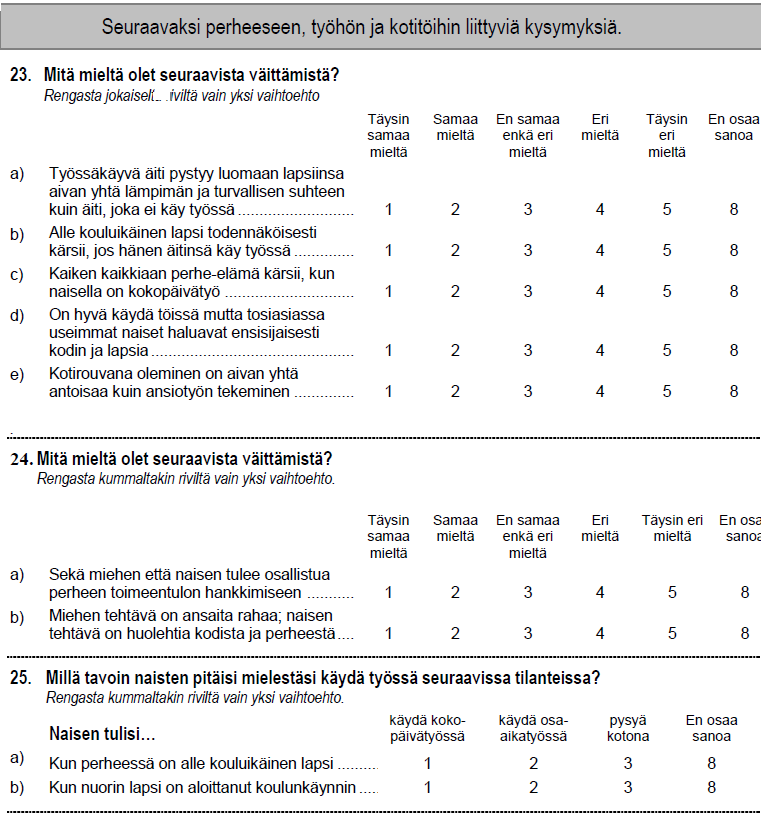

Suomen lomake

```r
knitr::include_graphics('img/substvar_fi_Q1Q2.png')
```

## 1.5 Datan valinnan vaiheet ja puuttuvat tiedot

**edit 24.2.20 Toistoa**

**1. Vastauskato on kyselytutkimusten suurin ongelma.**

Johdattelevassa esimerkissä on kolme muuttujaa, ei ongelma, aika vähän puuuttuvia.

Isomman 25 aineiston osalta tarkistetaan, mitä “listwise deletion” saa aikaan. Aineisto pienenee nopeasti, ja vaikeasti hahmotettavalla tavalla. Tämä erävastauskato ei ole tutkielman ydinaihe, mutta laajemman aineiston käytössä se täytyy ottaa huomioon. Yksikkövastauskatoa ei käsitellä, tutkimuksen toteutuksen raporteissa on kerrottu tarkemmin miten kyselyn toteuttajat ovat tämän huomioineet. Yksikkövastauskato eli otokseen poimitut joita ei ole tavoitettu ollenkaan on kansallisen tason ongelma, joka on ratkaistu vaihtelevin tavoin. Tiedot löytyvät aineiston dokumentaatiosta. Aineistossa on myös mukana maakohtaiset painomuuttujat, mutta ei painoja maiden vertailuun. Vastausprosentit (response rate) vaihtelevat maittain, kts. monitoring report. (**edit** toistoa! 24.2.20)

CA:n eräs etu on se, että muuttujien oletetaan olevan luokitteluasteikon (nominaaliasteikon) muuttujia, ja puuttuva havainto on yksi luokka lisää. Puuttuvat havainnot otetaan mukaan laajemmassa aineistossa myös siksi, että CA ja MCA edellyttävt yleensä useamman muuttujan analyyseissä sitä. Jokaisen kahden muuttujan parittaisen ristiintaulukoinnin reunajakaumien pitää olla samoja.

**ks** Perusasiat havaintojen puuttellisuudesta kyselytutkimusissa. Yksikkövastauskato (unit non-response), eräsvastauskato (item non-response). Mitä on raportoitava, kun käytetään valmista aineistoa? Erävastauskatoa analysoidaan, kun käytetään kaikkia valittuja muuttujia.

Yksikkövastauskato on otettu vaihtelevasti huomioon, kun kyselyn toteuttaja on editoinut ja tarkastanut datan. Eri maiden datassa on (mutta ei aina!) mukana painot mm. vastauskadon oikaiksemiseen **Viittet - tekninen raportti**. Myös selaimella voi zcat-sivustolla tutkailla kysymyksittäin.

Datakatalogi-dokumentista näkee vastausten jakauman jokaisen kysymyksen osalta, myös puuttuvien tietojen tarkemman koodauksen.

1. Valitaan 25 maata ja muuttujat
2. Johdattelevissa esimerkeissä valitaan kuusi maata ja kolme muuttujaa. Jätetään pois kaikki havainnot (vastaukset) joissa on puuttuvia tietoja (“listwise deletion”)
3. Kun laajempi aineisto otetaan käyttöön, joudutaan pohtimaan miten puuttuvia havaintoja käsitellään. Jos kyse on selvistä virheistä (esim. haastateltavan ikä puuttu) havainnot jätetään pois, muuten mietitään.

**Miten puuttuvia tietoja (erävastuskato, havainnossa puuttu joku tieto) käsitellään?**

1. Miksi tieto puuttuu, mitä “puuttuva tieto” tarkoittaa? Lavea kysymys!

Joissain kysymyksissä (V12, V13) puuttuvaksi tiedoksi kirjautuu vastaus (“en osaa sanoa”) “ei vastausta” - vaihtoehdon lisäksi. Nämä mukaan.

Ikä ja sukupuoli: ilmeinen virhe, joten jätetään havainnot pois (näitä ei ole paljon).

“Listwise delete” on raaka ratkaisu, kun muuttujia on paljon.Imputointi, mutta CA:lla voi analysoida puuttuvaa arvoa yhtenä luokittelumuuttujan “modaliteettina”.

2. Puuttuvien tietojen jakauma?

**edit 24.2.20)** Kun laajempi aineisto ja puuttuvat arvot otetaan mukaan analyysiin loppuluvuissa, vilkaistaa pikaisesti erävastauskadon rakennetta.

3. Onko puuttuvia tietoja tasaisesti eri maissa, vai vaihteleeko niiden suhteellinen osuus?

Vaihtelee, ja jo tästäkin syystä puuttuvien käsittely on oleellinen asia. Ensimmäisenä ratkaisuna ne voi pitää mukana ca/mca - analyyseissä, reunajakaumat pysyvät samoina.

4. Onko joissain tai jossain maassa huomattava määrä puuttuvia tietoja?

Joissain muuttujissa on kohtalaisen paljon puuttuvia tietoja joissain maissa.

Tarkemmin puuttuneisuutta ei analysoida. Esimerkkejä löytyy (MG, CAiP ja “vihreä kirja”). Kaksi R-pakettia, joilla pikaisesti vilkaistaan dataa, ei vielä mukana tässä (24.2.20). **edit** Viite!

**edit** kaksi vanhaa koodilohkoa, olkoon toistaiseksi mukana (11.2.20)

Puuttuvien tietojen tarkempi koodaus ISSP-datassa:

0: Not applicapble (NAP), Not available (NAV) 7: (97,997, 9997,…): Refused 8: (98, 998, 9998,…): Don’t know 9: (99, 999, 9999,…): No answer

NAP ja NAV määritellään

"GESIS adds ‘Not applicable’(NAP) codes for questions that have filters. NAP indicates that only a subsample and not all of respondents were asked. Also in the case of country spesific variables, all the other countries are coded NAP.

GESIS adds ‘Not available’ for variables, which in singe countries may not have been conducted for whatever reason."

## 1.6 Perusmuunnokset ISSP2012 - datalle

Datatiedosto on muunnosten jälkeen **ISSP2012jh1d.data**,luokittelumuuttujat muunnetaan R:n factor- muuttujaksi.

Jokaisesta muuttujasta on kaksi versiota, toisessa puuttuvat tiedot ovat R:n “NA”- arvoja ja toisessa “NA”-arvo on eksplisiittinen muuttuja (“missing”).

Substanssimuuttujien luokkien tunnukset ( faktorilabelit) muutetaan graafisiin analyyseihin sopivan lyhyiksi. Taustamuuttujien luokittelua ja luokkien tunnuksia pohditaan, kun ne otetaan käyttöön.

**#V** Tärkein lähde McNamara&Horton(2017) “Wrangilin with categocal data in R”.

”Very short : levels are the input, labels are the output in the factor() function. A factor has only a level attribute, which is set by the labels argument in the factor() function. This is different from the concept of labels in statistical packages like SPSS, and can be confusing in the beginning." (https://stackoverflow.com/questions/5869539/confusion-between-factor-levels-and-factor-labels)

Haven-paketin labelled_spss-luokka (https://github.com/tidyverse/haven/issues/172) , kaksi toisiaan täydentävää käyttötapaa. Se on yksi “välimuoto” kun dataa luetaan SPSS/SAS/Stata formaatista R-formaattiin. Toisaalta labelled-paketin avulla luokan olioita voi monipuolisesti muokata monipuolisesti ja jakaa tuloksia takaisin muiden ohjelmistojen tiedostoformaatteihin. Tässä ensimmäinen vaihtoehto käytössä.

**TODO 30.1.20** Tarkistukset, varmistukset jne. (24.2.20) Lisätty muutama testi, paljon välitulostuksia joita voi tarvittaessa kommentoida koodista pois.

(TODO 2.2.20) Muunnetaanko muuttujan maa (C_ALPHAN as_factor) järjestys heti samaksi kuin C_ALPHAN? Nyt tehdään G1_2_johdesim.Rmd:ssä. (24.2.20) tehty, muunnetaan heti alussa. Käytännössä kaikenlaisia korjailuja joutuu tekemään myös analyyseissä käytettävissä R-datoissa.

(TODO 3.2.20) Aluejaon maakoodi V3 mukaan, pohditaan järjestykset jne luvussa G1_2_johdesim.Rmd. (24.2.20) tehty, järjesteään myös uusi muuttuja C_ALPHAN-järjestykseen.

### 1.6.1 Vaihe 1 - muuttujat joissa ei ole puuttuvia tietoja

```r
# VAIHE 1 - muuttujat joissa ei ole puuttuvia tietoja

# vaihe 1.1 haven_labelled ja chr -> as_factor

ISSP2012jh1d.dat <- ISSP2012jh1c.data %>%
    mutate(maa = as_factor(C_ALPHAN), # ei puuttuvia, ei tyhjiä leveleitä
           maa3 = as_factor(V3),  # maakoodi, jossa aluejako joillan mailla
           sp1 = as_factor(SEX), # ei puuttuvia, tyhjä level "no answer" 999
         )


# C_ALPHAN - maa - maa3 tarkistuksia

# V3
# "Pulma" on järjestys. C_ALPHAN ("chr") on aakkosjärjestyksessä, kun luodaan
# maa = as_factor(C_ALPHAN) järjestys muuttuu (esiintymisjärjestys datassa?)
# maa3 muunnetaan maakoodista (haven_labelled' num), jonka

str(ISSP2012jh1d.dat$maa) #Country Prefix ISO 3166 Code - alphanumeric
```

```
##  Factor w/ 25 levels "AU","AT","BG",..: 1 1 1 1 1 1 1 1 1 1 ...
##  - attr(*, "label")= chr "Country Prefix ISO 3166 Code - alphanumeric"
```

```r
# attributes(ISSP2012jh1d.dat$maa) # ei tyhiä levels-arvoja, 25 levels
# ISSP2012jh1d.dat$maa %>% fct_unique()
# ISSP2012jh1d.dat$maa %>% fct_count() # summary kertoo samat tiedot (20.2.20)
# sum(is.na(ISSP2012jh1d.dat$maa)) # ei puuttuvia tietoja
ISSP2012jh1d.dat$maa %>% summary() # mukana vain valitut 25 maata
```

```
##   AU   AT   BG   CA   HR   CZ   DK   FI   FR   HU   IS   IE   LV   LT   NL   NO
## 1557 1182 1003  953  997 1804 1403 1171 2409 1012 1172 1166 1000 1187 1315 1444
##   PL   RU   SK   SI   SE   CH   BE   DE   PT
## 1115 1525 1128 1034 1059 1237 2192 1761  997
```

```r
# str(ISSP2012jh1d.dat$maa3)  #"Country/ Sample ISO 3166 Code
                            #(see V4 for codes for whole nation states)"
                            # 29 levels
# str(ISSP2012jh1d.dat$V3)

# attributes(ISSP2012jh1d.dat$maa3) # ei tyhiä levels-arvoja, 29 levels
# sum(is.na(ISSP2012jh1d.dat$maa3)) # nolla ei ole puuttuva tieto! (3.2.20)
# ISSP2012jh1d.dat$maa3 %>% fct_unique()
# ISSP2012jh1d.dat$maa3 %>% fct_count()
# Vain näissä on jaettu maan havainnot (3.2.20)
#
# [38] BE-FLA-Belgium/ Flanders
# [39] BE-WAL-Belgium/ Wallonia
# [40] BE-BRU-Belgium/ Brussels
# [41] DE-W-Germany-West
# [42] DE-E-Germany-East
# [43] PT-Portugal 2012: first fieldwork round (main sample)
# [44] PT-Portugal 2012: second fieldwork round (complementary sample)

# ISSP2012jh1d.dat$maa3 %>% fct_count() #miksi ei tulosta mitään? (3.2.2020)

# ISSP2012jh1d.dat$maa3 %>% summary()
# ISSP2012jh1d.dat$maa3 %>% fct_unique()
# maa3: 25 maata, havaintojen määrä. Poisjätetyissä havaintoja 0.
# glimpse(ISSP2012jh1d.dat$maa3)
# head(ISSP2012jh1d.dat$maa3)
# length(levels(ISSP2012jh1d.dat$maa3))

# C_ALPHAN alkuperäinen järjestys, maa aakkosjärjestyssä  (2.2.20)
#
# Huom1: Myös merkkijonomuuttujaa C_ALPHAN tarvitaan jatkossa.
#
# Huom2: kun dataa rajataan, on tarkistettava ja tarvittaessa poistettava
# "tyhjät" R-factor - muuttujan "maa" luokat (3.2.2020)


# vaihe 1.2 tyhjät luokat (levels) pois faktoreista

ISSP2012jh1d.dat <- ISSP2012jh1d.dat %>%
    mutate(sp = fct_drop(sp1),
           maa3 = fct_drop(maa3))
# Poistetaan maa3-muuttujan tyhjät luokat (3.2.20)

#  maa3 - tarkistuksia

# str(ISSP2012jh1d.dat$maa3)  # 29 levels

attributes(ISSP2012jh1d.dat$maa3) #
```

```
## $levels
##  [1] "AU-Australia"
##  [2] "AT-Austria"
##  [3] "BG-Bulgaria"
##  [4] "CA-Canada"
##  [5] "HR-Croatia"
##  [6] "CZ-Czech Republic"
##  [7] "DK-Denmark"
##  [8] "FI-Finland"
##  [9] "FR-France"
## [10] "HU-Hungary"
## [11] "IS-Iceland"
## [12] "IE-Ireland"
## [13] "LV-Latvia"
## [14] "LT-Lithuania"
```

[output cut: 21 more lines]

```r
#sum(is.na(ISSP2012jh1d.dat$maa3)) # nolla ei ole puuttuva tieto! (3.2.20)
# ISSP2012jh1d.dat$maa3 %>% summary()
# ISSP2012jh1d.dat$maa3 %>% fct_unique()
ISSP2012jh1d.dat$maa3 %>% fct_count() # miksi ei tulosta? Tulostaa komentoriviltä!
```

| f | n |
| --- | --- |
| AU-Australia | 1557 |
| AT-Austria | 1182 |
| BG-Bulgaria | 1003 |
| CA-Canada | 953 |
| HR-Croatia | 997 |
| CZ-Czech Republic | 1804 |
| DK-Denmark | 1403 |
| FI-Finland | 1171 |
| FR-France | 2409 |
| HU-Hungary | 1012 |
| IS-Iceland | 1172 |
| IE-Ireland | 1166 |
| LV-Latvia | 1000 |
| LT-Lithuania | 1187 |
| NL-Netherlands | 1315 |
| NO-Norway | 1444 |
| PL-Poland | 1115 |
| RU-Russia | 1525 |
| SK-Slovakia | 1128 |
| SI-Slovenia | 1034 |
| SE-Sweden | 1059 |
| CH-Switzerland | 1237 |
| BE-FLA-Belgium/ Flanders | 1090 |
| BE-WAL-Belgium/ Wallonia | 543 |
| BE-BRU-Belgium/ Brussels | 559 |
| DE-W-Germany-West | 1205 |
| DE-E-Germany-East | 556 |
| PT-Portugal 2012: first fieldwork round (main sample) | 894 |
| PT-Portugal 2012: second fieldwork round (complementary sample) | 103 |

```r
str(ISSP2012jh1d.dat$C_ALPHAN)
```

```
##  chr [1:32823] "AU" "AU" "AU" "AU" "AU" "AU" "AU" "AU" "AU" "AU" "AU" "AU" ...
##  - attr(*, "label")= chr "Country Prefix ISO 3166 Code - alphanumeric"
##  - attr(*, "format.spss")= chr "A20"
##  - attr(*, "display_width")= int 22
```

```r
attributes(ISSP2012jh1d.dat$C_ALPHAN)
```

```
## $label
## [1] "Country Prefix ISO 3166 Code - alphanumeric"
##
## $format.spss
## [1] "A20"
##
## $display_width
## [1] 22
```

```r
ISSP2012jh1d.dat %>% tableX(C_ALPHAN, maa)
```

| C_ALPHAN/maa | AU | AT | BG | CA | HR | CZ | DK | FI | FR | HU | IS | IE | LV | LT | NL | NO | PL | RU | SK | SI | SE | CH | BE | DE | PT | Total |
| --- | --- | --- | --- | --- | --- | --- | --- | --- | --- | --- | --- | --- | --- | --- | --- | --- | --- | --- | --- | --- | --- | --- | --- | --- | --- | --- |
| AT | 0 | 1182 | 0 | 0 | 0 | 0 | 0 | 0 | 0 | 0 | 0 | 0 | 0 | 0 | 0 | 0 | 0 | 0 | 0 | 0 | 0 | 0 | 0 | 0 | 0 | 1182 |
| AU | 1557 | 0 | 0 | 0 | 0 | 0 | 0 | 0 | 0 | 0 | 0 | 0 | 0 | 0 | 0 | 0 | 0 | 0 | 0 | 0 | 0 | 0 | 0 | 0 | 0 | 1557 |
| BE | 0 | 0 | 0 | 0 | 0 | 0 | 0 | 0 | 0 | 0 | 0 | 0 | 0 | 0 | 0 | 0 | 0 | 0 | 0 | 0 | 0 | 0 | 2192 | 0 | 0 | 2192 |
| BG | 0 | 0 | 1003 | 0 | 0 | 0 | 0 | 0 | 0 | 0 | 0 | 0 | 0 | 0 | 0 | 0 | 0 | 0 | 0 | 0 | 0 | 0 | 0 | 0 | 0 | 1003 |
| CA | 0 | 0 | 0 | 953 | 0 | 0 | 0 | 0 | 0 | 0 | 0 | 0 | 0 | 0 | 0 | 0 | 0 | 0 | 0 | 0 | 0 | 0 | 0 | 0 | 0 | 953 |
| CH | 0 | 0 | 0 | 0 | 0 | 0 | 0 | 0 | 0 | 0 | 0 | 0 | 0 | 0 | 0 | 0 | 0 | 0 | 0 | 0 | 0 | 1237 | 0 | 0 | 0 | 1237 |
| CZ | 0 | 0 | 0 | 0 | 0 | 1804 | 0 | 0 | 0 | 0 | 0 | 0 | 0 | 0 | 0 | 0 | 0 | 0 | 0 | 0 | 0 | 0 | 0 | 0 | 0 | 1804 |
| DE | 0 | 0 | 0 | 0 | 0 | 0 | 0 | 0 | 0 | 0 | 0 | 0 | 0 | 0 | 0 | 0 | 0 | 0 | 0 | 0 | 0 | 0 | 0 | 1761 | 0 | 1761 |
| DK | 0 | 0 | 0 | 0 | 0 | 0 | 1403 | 0 | 0 | 0 | 0 | 0 | 0 | 0 | 0 | 0 | 0 | 0 | 0 | 0 | 0 | 0 | 0 | 0 | 0 | 1403 |
| FI | 0 | 0 | 0 | 0 | 0 | 0 | 0 | 1171 | 0 | 0 | 0 | 0 | 0 | 0 | 0 | 0 | 0 | 0 | 0 | 0 | 0 | 0 | 0 | 0 | 0 | 1171 |
| FR | 0 | 0 | 0 | 0 | 0 | 0 | 0 | 0 | 2409 | 0 | 0 | 0 | 0 | 0 | 0 | 0 | 0 | 0 | 0 | 0 | 0 | 0 | 0 | 0 | 0 | 2409 |
| HR | 0 | 0 | 0 | 0 | 997 | 0 | 0 | 0 | 0 | 0 | 0 | 0 | 0 | 0 | 0 | 0 | 0 | 0 | 0 | 0 | 0 | 0 | 0 | 0 | 0 | 997 |
| HU | 0 | 0 | 0 | 0 | 0 | 0 | 0 | 0 | 0 | 1012 | 0 | 0 | 0 | 0 | 0 | 0 | 0 | 0 | 0 | 0 | 0 | 0 | 0 | 0 | 0 | 1012 |
| IE | 0 | 0 | 0 | 0 | 0 | 0 | 0 | 0 | 0 | 0 | 0 | 1166 | 0 | 0 | 0 | 0 | 0 | 0 | 0 | 0 | 0 | 0 | 0 | 0 | 0 | 1166 |
| IS | 0 | 0 | 0 | 0 | 0 | 0 | 0 | 0 | 0 | 0 | 1172 | 0 | 0 | 0 | 0 | 0 | 0 | 0 | 0 | 0 | 0 | 0 | 0 | 0 | 0 | 1172 |
| LT | 0 | 0 | 0 | 0 | 0 | 0 | 0 | 0 | 0 | 0 | 0 | 0 | 0 | 1187 | 0 | 0 | 0 | 0 | 0 | 0 | 0 | 0 | 0 | 0 | 0 | 1187 |
| LV | 0 | 0 | 0 | 0 | 0 | 0 | 0 | 0 | 0 | 0 | 0 | 0 | 1000 | 0 | 0 | 0 | 0 | 0 | 0 | 0 | 0 | 0 | 0 | 0 | 0 | 1000 |
| NL | 0 | 0 | 0 | 0 | 0 | 0 | 0 | 0 | 0 | 0 | 0 | 0 | 0 | 0 | 1315 | 0 | 0 | 0 | 0 | 0 | 0 | 0 | 0 | 0 | 0 | 1315 |
| NO | 0 | 0 | 0 | 0 | 0 | 0 | 0 | 0 | 0 | 0 | 0 | 0 | 0 | 0 | 0 | 1444 | 0 | 0 | 0 | 0 | 0 | 0 | 0 | 0 | 0 | 1444 |
| PL | 0 | 0 | 0 | 0 | 0 | 0 | 0 | 0 | 0 | 0 | 0 | 0 | 0 | 0 | 0 | 0 | 1115 | 0 | 0 | 0 | 0 | 0 | 0 | 0 | 0 | 1115 |
| PT | 0 | 0 | 0 | 0 | 0 | 0 | 0 | 0 | 0 | 0 | 0 | 0 | 0 | 0 | 0 | 0 | 0 | 0 | 0 | 0 | 0 | 0 | 0 | 0 | 997 | 997 |
| RU | 0 | 0 | 0 | 0 | 0 | 0 | 0 | 0 | 0 | 0 | 0 | 0 | 0 | 0 | 0 | 0 | 0 | 1525 | 0 | 0 | 0 | 0 | 0 | 0 | 0 | 1525 |
| SE | 0 | 0 | 0 | 0 | 0 | 0 | 0 | 0 | 0 | 0 | 0 | 0 | 0 | 0 | 0 | 0 | 0 | 0 | 0 | 0 | 1059 | 0 | 0 | 0 | 0 | 1059 |
| SI | 0 | 0 | 0 | 0 | 0 | 0 | 0 | 0 | 0 | 0 | 0 | 0 | 0 | 0 | 0 | 0 | 0 | 0 | 0 | 1034 | 0 | 0 | 0 | 0 | 0 | 1034 |
| SK | 0 | 0 | 0 | 0 | 0 | 0 | 0 | 0 | 0 | 0 | 0 | 0 | 0 | 0 | 0 | 0 | 0 | 0 | 1128 | 0 | 0 | 0 | 0 | 0 | 0 | 1128 |
| Total | 1557 | 1182 | 1003 | 953 | 997 | 1804 | 1403 | 1171 | 2409 | 1012 | 1172 | 1166 | 1000 | 1187 | 1315 | 1444 | 1115 | 1525 | 1128 | 1034 | 1059 | 1237 | 2192 | 1761 | 997 | 32823 |

```r
ISSP2012jh1d.dat %>% tableX(C_ALPHAN, maa3)
```

| C_ALPHAN/maa3 | AU-Australia | AT-Austria | BG-Bulgaria | CA-Canada | HR-Croatia | CZ-Czech Republic | DK-Denmark | FI-Finland | FR-France | HU-Hungary | IS-Iceland | IE-Ireland | LV-Latvia | LT-Lithuania | NL-Netherlands | NO-Norway | PL-Poland | RU-Russia | SK-Slovakia | SI-Slovenia | SE-Sweden | CH-Switzerland | BE-FLA-Belgium/ Flanders | BE-WAL-Belgium/ Wallonia | BE-BRU-Belgium/ Brussels | DE-W-Germany-West | DE-E-Germany-East | PT-Portugal 2012: first fieldwork round (main sample) | PT-Portugal 2012: second fieldwork round (complementary sample) | … |
| --- | --- | --- | --- | --- | --- | --- | --- | --- | --- | --- | --- | --- | --- | --- | --- | --- | --- | --- | --- | --- | --- | --- | --- | --- | --- | --- | --- | --- | --- | --- |
| AT | 0 | 1182 | 0 | 0 | 0 | 0 | 0 | 0 | 0 | 0 | 0 | 0 | 0 | 0 | 0 | 0 | 0 | 0 | 0 | 0 | 0 | 0 | 0 | 0 | 0 | 0 | 0 | 0 | 0 | … |
| AU | 1557 | 0 | 0 | 0 | 0 | 0 | 0 | 0 | 0 | 0 | 0 | 0 | 0 | 0 | 0 | 0 | 0 | 0 | 0 | 0 | 0 | 0 | 0 | 0 | 0 | 0 | 0 | 0 | 0 | … |
| BE | 0 | 0 | 0 | 0 | 0 | 0 | 0 | 0 | 0 | 0 | 0 | 0 | 0 | 0 | 0 | 0 | 0 | 0 | 0 | 0 | 0 | 0 | 1090 | 543 | 559 | 0 | 0 | 0 | 0 | … |
| BG | 0 | 0 | 1003 | 0 | 0 | 0 | 0 | 0 | 0 | 0 | 0 | 0 | 0 | 0 | 0 | 0 | 0 | 0 | 0 | 0 | 0 | 0 | 0 | 0 | 0 | 0 | 0 | 0 | 0 | … |
| CA | 0 | 0 | 0 | 953 | 0 | 0 | 0 | 0 | 0 | 0 | 0 | 0 | 0 | 0 | 0 | 0 | 0 | 0 | 0 | 0 | 0 | 0 | 0 | 0 | 0 | 0 | 0 | 0 | 0 | … |
| CH | 0 | 0 | 0 | 0 | 0 | 0 | 0 | 0 | 0 | 0 | 0 | 0 | 0 | 0 | 0 | 0 | 0 | 0 | 0 | 0 | 0 | 1237 | 0 | 0 | 0 | 0 | 0 | 0 | 0 | … |
| CZ | 0 | 0 | 0 | 0 | 0 | 1804 | 0 | 0 | 0 | 0 | 0 | 0 | 0 | 0 | 0 | 0 | 0 | 0 | 0 | 0 | 0 | 0 | 0 | 0 | 0 | 0 | 0 | 0 | 0 | … |
| DE | 0 | 0 | 0 | 0 | 0 | 0 | 0 | 0 | 0 | 0 | 0 | 0 | 0 | 0 | 0 | 0 | 0 | 0 | 0 | 0 | 0 | 0 | 0 | 0 | 0 | 1205 | 556 | 0 | 0 | … |
| DK | 0 | 0 | 0 | 0 | 0 | 0 | 1403 | 0 | 0 | 0 | 0 | 0 | 0 | 0 | 0 | 0 | 0 | 0 | 0 | 0 | 0 | 0 | 0 | 0 | 0 | 0 | 0 | 0 | 0 | … |
| FI | 0 | 0 | 0 | 0 | 0 | 0 | 0 | 1171 | 0 | 0 | 0 | 0 | 0 | 0 | 0 | 0 | 0 | 0 | 0 | 0 | 0 | 0 | 0 | 0 | 0 | 0 | 0 | 0 | 0 | … |
| FR | 0 | 0 | 0 | 0 | 0 | 0 | 0 | 0 | 2409 | 0 | 0 | 0 | 0 | 0 | 0 | 0 | 0 | 0 | 0 | 0 | 0 | 0 | 0 | 0 | 0 | 0 | 0 | 0 | 0 | … |
| HR | 0 | 0 | 0 | 0 | 997 | 0 | 0 | 0 | 0 | 0 | 0 | 0 | 0 | 0 | 0 | 0 | 0 | 0 | 0 | 0 | 0 | 0 | 0 | 0 | 0 | 0 | 0 | 0 | 0 | … |
| HU | 0 | 0 | 0 | 0 | 0 | 0 | 0 | 0 | 0 | 1012 | 0 | 0 | 0 | 0 | 0 | 0 | 0 | 0 | 0 | 0 | 0 | 0 | 0 | 0 | 0 | 0 | 0 | 0 | 0 | … |
| IE | 0 | 0 | 0 | 0 | 0 | 0 | 0 | 0 | 0 | 0 | 0 | 1166 | 0 | 0 | 0 | 0 | 0 | 0 | 0 | 0 | 0 | 0 | 0 | 0 | 0 | 0 | 0 | 0 | 0 | … |
| IS | 0 | 0 | 0 | 0 | 0 | 0 | 0 | 0 | 0 | 0 | 1172 | 0 | 0 | 0 | 0 | 0 | 0 | 0 | 0 | 0 | 0 | 0 | 0 | 0 | 0 | 0 | 0 | 0 | 0 | … |
| LT | 0 | 0 | 0 | 0 | 0 | 0 | 0 | 0 | 0 | 0 | 0 | 0 | 0 | 1187 | 0 | 0 | 0 | 0 | 0 | 0 | 0 | 0 | 0 | 0 | 0 | 0 | 0 | 0 | 0 | … |
| LV | 0 | 0 | 0 | 0 | 0 | 0 | 0 | 0 | 0 | 0 | 0 | 0 | 1000 | 0 | 0 | 0 | 0 | 0 | 0 | 0 | 0 | 0 | 0 | 0 | 0 | 0 | 0 | 0 | 0 | … |
| NL | 0 | 0 | 0 | 0 | 0 | 0 | 0 | 0 | 0 | 0 | 0 | 0 | 0 | 0 | 1315 | 0 | 0 | 0 | 0 | 0 | 0 | 0 | 0 | 0 | 0 | 0 | 0 | 0 | 0 | … |
| NO | 0 | 0 | 0 | 0 | 0 | 0 | 0 | 0 | 0 | 0 | 0 | 0 | 0 | 0 | 0 | 1444 | 0 | 0 | 0 | 0 | 0 | 0 | 0 | 0 | 0 | 0 | 0 | 0 | 0 | … |
| PL | 0 | 0 | 0 | 0 | 0 | 0 | 0 | 0 | 0 | 0 | 0 | 0 | 0 | 0 | 0 | 0 | 1115 | 0 | 0 | 0 | 0 | 0 | 0 | 0 | 0 | 0 | 0 | 0 | 0 | … |
| PT | 0 | 0 | 0 | 0 | 0 | 0 | 0 | 0 | 0 | 0 | 0 | 0 | 0 | 0 | 0 | 0 | 0 | 0 | 0 | 0 | 0 | 0 | 0 | 0 | 0 | 0 | 0 | 894 | 103 | … |
| RU | 0 | 0 | 0 | 0 | 0 | 0 | 0 | 0 | 0 | 0 | 0 | 0 | 0 | 0 | 0 | 0 | 0 | 1525 | 0 | 0 | 0 | 0 | 0 | 0 | 0 | 0 | 0 | 0 | 0 | … |
| SE | 0 | 0 | 0 | 0 | 0 | 0 | 0 | 0 | 0 | 0 | 0 | 0 | 0 | 0 | 0 | 0 | 0 | 0 | 0 | 0 | 1059 | 0 | 0 | 0 | 0 | 0 | 0 | 0 | 0 | … |
| SI | 0 | 0 | 0 | 0 | 0 | 0 | 0 | 0 | 0 | 0 | 0 | 0 | 0 | 0 | 0 | 0 | 0 | 0 | 0 | 1034 | 0 | 0 | 0 | 0 | 0 | 0 | 0 | 0 | 0 | … |
| SK | 0 | 0 | 0 | 0 | 0 | 0 | 0 | 0 | 0 | 0 | 0 | 0 | 0 | 0 | 0 | 0 | 0 | 0 | 1128 | 0 | 0 | 0 | 0 | 0 | 0 | 0 | 0 | 0 | 0 | … |
| Total | 1557 | 1182 | 1003 | 953 | 997 | 1804 | 1403 | 1171 | 2409 | 1012 | 1172 | 1166 | 1000 | 1187 | 1315 | 1444 | 1115 | 1525 | 1128 | 1034 | 1059 | 1237 | 1090 | 543 | 559 | 1205 | 556 | 894 | 103 | … |

```r
ISSP2012jh1d.dat %>% tableX(maa, maa3)
```

| maa/maa3 | AU-Australia | AT-Austria | BG-Bulgaria | CA-Canada | HR-Croatia | CZ-Czech Republic | DK-Denmark | FI-Finland | FR-France | HU-Hungary | IS-Iceland | IE-Ireland | LV-Latvia | LT-Lithuania | NL-Netherlands | NO-Norway | PL-Poland | RU-Russia | SK-Slovakia | SI-Slovenia | SE-Sweden | CH-Switzerland | BE-FLA-Belgium/ Flanders | BE-WAL-Belgium/ Wallonia | BE-BRU-Belgium/ Brussels | DE-W-Germany-West | DE-E-Germany-East | PT-Portugal 2012: first fieldwork round (main sample) | PT-Portugal 2012: second fieldwork round (complementary sample) | … |
| --- | --- | --- | --- | --- | --- | --- | --- | --- | --- | --- | --- | --- | --- | --- | --- | --- | --- | --- | --- | --- | --- | --- | --- | --- | --- | --- | --- | --- | --- | --- |
| AU | 1557 | 0 | 0 | 0 | 0 | 0 | 0 | 0 | 0 | 0 | 0 | 0 | 0 | 0 | 0 | 0 | 0 | 0 | 0 | 0 | 0 | 0 | 0 | 0 | 0 | 0 | 0 | 0 | 0 | … |
| AT | 0 | 1182 | 0 | 0 | 0 | 0 | 0 | 0 | 0 | 0 | 0 | 0 | 0 | 0 | 0 | 0 | 0 | 0 | 0 | 0 | 0 | 0 | 0 | 0 | 0 | 0 | 0 | 0 | 0 | … |
| BG | 0 | 0 | 1003 | 0 | 0 | 0 | 0 | 0 | 0 | 0 | 0 | 0 | 0 | 0 | 0 | 0 | 0 | 0 | 0 | 0 | 0 | 0 | 0 | 0 | 0 | 0 | 0 | 0 | 0 | … |
| CA | 0 | 0 | 0 | 953 | 0 | 0 | 0 | 0 | 0 | 0 | 0 | 0 | 0 | 0 | 0 | 0 | 0 | 0 | 0 | 0 | 0 | 0 | 0 | 0 | 0 | 0 | 0 | 0 | 0 | … |
| HR | 0 | 0 | 0 | 0 | 997 | 0 | 0 | 0 | 0 | 0 | 0 | 0 | 0 | 0 | 0 | 0 | 0 | 0 | 0 | 0 | 0 | 0 | 0 | 0 | 0 | 0 | 0 | 0 | 0 | … |
| CZ | 0 | 0 | 0 | 0 | 0 | 1804 | 0 | 0 | 0 | 0 | 0 | 0 | 0 | 0 | 0 | 0 | 0 | 0 | 0 | 0 | 0 | 0 | 0 | 0 | 0 | 0 | 0 | 0 | 0 | … |
| DK | 0 | 0 | 0 | 0 | 0 | 0 | 1403 | 0 | 0 | 0 | 0 | 0 | 0 | 0 | 0 | 0 | 0 | 0 | 0 | 0 | 0 | 0 | 0 | 0 | 0 | 0 | 0 | 0 | 0 | … |
| FI | 0 | 0 | 0 | 0 | 0 | 0 | 0 | 1171 | 0 | 0 | 0 | 0 | 0 | 0 | 0 | 0 | 0 | 0 | 0 | 0 | 0 | 0 | 0 | 0 | 0 | 0 | 0 | 0 | 0 | … |
| FR | 0 | 0 | 0 | 0 | 0 | 0 | 0 | 0 | 2409 | 0 | 0 | 0 | 0 | 0 | 0 | 0 | 0 | 0 | 0 | 0 | 0 | 0 | 0 | 0 | 0 | 0 | 0 | 0 | 0 | … |
| HU | 0 | 0 | 0 | 0 | 0 | 0 | 0 | 0 | 0 | 1012 | 0 | 0 | 0 | 0 | 0 | 0 | 0 | 0 | 0 | 0 | 0 | 0 | 0 | 0 | 0 | 0 | 0 | 0 | 0 | … |
| IS | 0 | 0 | 0 | 0 | 0 | 0 | 0 | 0 | 0 | 0 | 1172 | 0 | 0 | 0 | 0 | 0 | 0 | 0 | 0 | 0 | 0 | 0 | 0 | 0 | 0 | 0 | 0 | 0 | 0 | … |
| IE | 0 | 0 | 0 | 0 | 0 | 0 | 0 | 0 | 0 | 0 | 0 | 1166 | 0 | 0 | 0 | 0 | 0 | 0 | 0 | 0 | 0 | 0 | 0 | 0 | 0 | 0 | 0 | 0 | 0 | … |
| LV | 0 | 0 | 0 | 0 | 0 | 0 | 0 | 0 | 0 | 0 | 0 | 0 | 1000 | 0 | 0 | 0 | 0 | 0 | 0 | 0 | 0 | 0 | 0 | 0 | 0 | 0 | 0 | 0 | 0 | … |
| LT | 0 | 0 | 0 | 0 | 0 | 0 | 0 | 0 | 0 | 0 | 0 | 0 | 0 | 1187 | 0 | 0 | 0 | 0 | 0 | 0 | 0 | 0 | 0 | 0 | 0 | 0 | 0 | 0 | 0 | … |
| NL | 0 | 0 | 0 | 0 | 0 | 0 | 0 | 0 | 0 | 0 | 0 | 0 | 0 | 0 | 1315 | 0 | 0 | 0 | 0 | 0 | 0 | 0 | 0 | 0 | 0 | 0 | 0 | 0 | 0 | … |
| NO | 0 | 0 | 0 | 0 | 0 | 0 | 0 | 0 | 0 | 0 | 0 | 0 | 0 | 0 | 0 | 1444 | 0 | 0 | 0 | 0 | 0 | 0 | 0 | 0 | 0 | 0 | 0 | 0 | 0 | … |
| PL | 0 | 0 | 0 | 0 | 0 | 0 | 0 | 0 | 0 | 0 | 0 | 0 | 0 | 0 | 0 | 0 | 1115 | 0 | 0 | 0 | 0 | 0 | 0 | 0 | 0 | 0 | 0 | 0 | 0 | … |
| RU | 0 | 0 | 0 | 0 | 0 | 0 | 0 | 0 | 0 | 0 | 0 | 0 | 0 | 0 | 0 | 0 | 0 | 1525 | 0 | 0 | 0 | 0 | 0 | 0 | 0 | 0 | 0 | 0 | 0 | … |
| SK | 0 | 0 | 0 | 0 | 0 | 0 | 0 | 0 | 0 | 0 | 0 | 0 | 0 | 0 | 0 | 0 | 0 | 0 | 1128 | 0 | 0 | 0 | 0 | 0 | 0 | 0 | 0 | 0 | 0 | … |
| SI | 0 | 0 | 0 | 0 | 0 | 0 | 0 | 0 | 0 | 0 | 0 | 0 | 0 | 0 | 0 | 0 | 0 | 0 | 0 | 1034 | 0 | 0 | 0 | 0 | 0 | 0 | 0 | 0 | 0 | … |
| SE | 0 | 0 | 0 | 0 | 0 | 0 | 0 | 0 | 0 | 0 | 0 | 0 | 0 | 0 | 0 | 0 | 0 | 0 | 0 | 0 | 1059 | 0 | 0 | 0 | 0 | 0 | 0 | 0 | 0 | … |
| CH | 0 | 0 | 0 | 0 | 0 | 0 | 0 | 0 | 0 | 0 | 0 | 0 | 0 | 0 | 0 | 0 | 0 | 0 | 0 | 0 | 0 | 1237 | 0 | 0 | 0 | 0 | 0 | 0 | 0 | … |
| BE | 0 | 0 | 0 | 0 | 0 | 0 | 0 | 0 | 0 | 0 | 0 | 0 | 0 | 0 | 0 | 0 | 0 | 0 | 0 | 0 | 0 | 0 | 1090 | 543 | 559 | 0 | 0 | 0 | 0 | … |
| DE | 0 | 0 | 0 | 0 | 0 | 0 | 0 | 0 | 0 | 0 | 0 | 0 | 0 | 0 | 0 | 0 | 0 | 0 | 0 | 0 | 0 | 0 | 0 | 0 | 0 | 1205 | 556 | 0 | 0 | … |
| PT | 0 | 0 | 0 | 0 | 0 | 0 | 0 | 0 | 0 | 0 | 0 | 0 | 0 | 0 | 0 | 0 | 0 | 0 | 0 | 0 | 0 | 0 | 0 | 0 | 0 | 0 | 0 | 894 | 103 | … |
| Total | 1557 | 1182 | 1003 | 953 | 997 | 1804 | 1403 | 1171 | 2409 | 1012 | 1172 | 1166 | 1000 | 1187 | 1315 | 1444 | 1115 | 1525 | 1128 | 1034 | 1059 | 1237 | 1090 | 543 | 559 | 1205 | 556 | 894 | 103 | … |

```r
ISSP2012jh1d.dat %>% tableX(V3, maa3)
```

| V3/maa3 | AU-Australia | AT-Austria | BG-Bulgaria | CA-Canada | HR-Croatia | CZ-Czech Republic | DK-Denmark | FI-Finland | FR-France | HU-Hungary | IS-Iceland | IE-Ireland | LV-Latvia | LT-Lithuania | NL-Netherlands | NO-Norway | PL-Poland | RU-Russia | SK-Slovakia | SI-Slovenia | SE-Sweden | CH-Switzerland | BE-FLA-Belgium/ Flanders | BE-WAL-Belgium/ Wallonia | BE-BRU-Belgium/ Brussels | DE-W-Germany-West | DE-E-Germany-East | PT-Portugal 2012: first fieldwork round (main sample) | PT-Portugal 2012: second fieldwork round (complementary sample) | … |
| --- | --- | --- | --- | --- | --- | --- | --- | --- | --- | --- | --- | --- | --- | --- | --- | --- | --- | --- | --- | --- | --- | --- | --- | --- | --- | --- | --- | --- | --- | --- |
| 36 | 1557 | 0 | 0 | 0 | 0 | 0 | 0 | 0 | 0 | 0 | 0 | 0 | 0 | 0 | 0 | 0 | 0 | 0 | 0 | 0 | 0 | 0 | 0 | 0 | 0 | 0 | 0 | 0 | 0 | … |
| 40 | 0 | 1182 | 0 | 0 | 0 | 0 | 0 | 0 | 0 | 0 | 0 | 0 | 0 | 0 | 0 | 0 | 0 | 0 | 0 | 0 | 0 | 0 | 0 | 0 | 0 | 0 | 0 | 0 | 0 | … |
| 100 | 0 | 0 | 1003 | 0 | 0 | 0 | 0 | 0 | 0 | 0 | 0 | 0 | 0 | 0 | 0 | 0 | 0 | 0 | 0 | 0 | 0 | 0 | 0 | 0 | 0 | 0 | 0 | 0 | 0 | … |
| 124 | 0 | 0 | 0 | 953 | 0 | 0 | 0 | 0 | 0 | 0 | 0 | 0 | 0 | 0 | 0 | 0 | 0 | 0 | 0 | 0 | 0 | 0 | 0 | 0 | 0 | 0 | 0 | 0 | 0 | … |
| 191 | 0 | 0 | 0 | 0 | 997 | 0 | 0 | 0 | 0 | 0 | 0 | 0 | 0 | 0 | 0 | 0 | 0 | 0 | 0 | 0 | 0 | 0 | 0 | 0 | 0 | 0 | 0 | 0 | 0 | … |
| 203 | 0 | 0 | 0 | 0 | 0 | 1804 | 0 | 0 | 0 | 0 | 0 | 0 | 0 | 0 | 0 | 0 | 0 | 0 | 0 | 0 | 0 | 0 | 0 | 0 | 0 | 0 | 0 | 0 | 0 | … |
| 208 | 0 | 0 | 0 | 0 | 0 | 0 | 1403 | 0 | 0 | 0 | 0 | 0 | 0 | 0 | 0 | 0 | 0 | 0 | 0 | 0 | 0 | 0 | 0 | 0 | 0 | 0 | 0 | 0 | 0 | … |
| 246 | 0 | 0 | 0 | 0 | 0 | 0 | 0 | 1171 | 0 | 0 | 0 | 0 | 0 | 0 | 0 | 0 | 0 | 0 | 0 | 0 | 0 | 0 | 0 | 0 | 0 | 0 | 0 | 0 | 0 | … |
| 250 | 0 | 0 | 0 | 0 | 0 | 0 | 0 | 0 | 2409 | 0 | 0 | 0 | 0 | 0 | 0 | 0 | 0 | 0 | 0 | 0 | 0 | 0 | 0 | 0 | 0 | 0 | 0 | 0 | 0 | … |
| 348 | 0 | 0 | 0 | 0 | 0 | 0 | 0 | 0 | 0 | 1012 | 0 | 0 | 0 | 0 | 0 | 0 | 0 | 0 | 0 | 0 | 0 | 0 | 0 | 0 | 0 | 0 | 0 | 0 | 0 | … |
| 352 | 0 | 0 | 0 | 0 | 0 | 0 | 0 | 0 | 0 | 0 | 1172 | 0 | 0 | 0 | 0 | 0 | 0 | 0 | 0 | 0 | 0 | 0 | 0 | 0 | 0 | 0 | 0 | 0 | 0 | … |
| 372 | 0 | 0 | 0 | 0 | 0 | 0 | 0 | 0 | 0 | 0 | 0 | 1166 | 0 | 0 | 0 | 0 | 0 | 0 | 0 | 0 | 0 | 0 | 0 | 0 | 0 | 0 | 0 | 0 | 0 | … |
| 428 | 0 | 0 | 0 | 0 | 0 | 0 | 0 | 0 | 0 | 0 | 0 | 0 | 1000 | 0 | 0 | 0 | 0 | 0 | 0 | 0 | 0 | 0 | 0 | 0 | 0 | 0 | 0 | 0 | 0 | … |
| 440 | 0 | 0 | 0 | 0 | 0 | 0 | 0 | 0 | 0 | 0 | 0 | 0 | 0 | 1187 | 0 | 0 | 0 | 0 | 0 | 0 | 0 | 0 | 0 | 0 | 0 | 0 | 0 | 0 | 0 | … |
| 528 | 0 | 0 | 0 | 0 | 0 | 0 | 0 | 0 | 0 | 0 | 0 | 0 | 0 | 0 | 1315 | 0 | 0 | 0 | 0 | 0 | 0 | 0 | 0 | 0 | 0 | 0 | 0 | 0 | 0 | … |
| 578 | 0 | 0 | 0 | 0 | 0 | 0 | 0 | 0 | 0 | 0 | 0 | 0 | 0 | 0 | 0 | 1444 | 0 | 0 | 0 | 0 | 0 | 0 | 0 | 0 | 0 | 0 | 0 | 0 | 0 | … |
| 616 | 0 | 0 | 0 | 0 | 0 | 0 | 0 | 0 | 0 | 0 | 0 | 0 | 0 | 0 | 0 | 0 | 1115 | 0 | 0 | 0 | 0 | 0 | 0 | 0 | 0 | 0 | 0 | 0 | 0 | … |
| 643 | 0 | 0 | 0 | 0 | 0 | 0 | 0 | 0 | 0 | 0 | 0 | 0 | 0 | 0 | 0 | 0 | 0 | 1525 | 0 | 0 | 0 | 0 | 0 | 0 | 0 | 0 | 0 | 0 | 0 | … |
| 703 | 0 | 0 | 0 | 0 | 0 | 0 | 0 | 0 | 0 | 0 | 0 | 0 | 0 | 0 | 0 | 0 | 0 | 0 | 1128 | 0 | 0 | 0 | 0 | 0 | 0 | 0 | 0 | 0 | 0 | … |
| 705 | 0 | 0 | 0 | 0 | 0 | 0 | 0 | 0 | 0 | 0 | 0 | 0 | 0 | 0 | 0 | 0 | 0 | 0 | 0 | 1034 | 0 | 0 | 0 | 0 | 0 | 0 | 0 | 0 | 0 | … |
| 752 | 0 | 0 | 0 | 0 | 0 | 0 | 0 | 0 | 0 | 0 | 0 | 0 | 0 | 0 | 0 | 0 | 0 | 0 | 0 | 0 | 1059 | 0 | 0 | 0 | 0 | 0 | 0 | 0 | 0 | … |
| 756 | 0 | 0 | 0 | 0 | 0 | 0 | 0 | 0 | 0 | 0 | 0 | 0 | 0 | 0 | 0 | 0 | 0 | 0 | 0 | 0 | 0 | 1237 | 0 | 0 | 0 | 0 | 0 | 0 | 0 | … |
| 5601 | 0 | 0 | 0 | 0 | 0 | 0 | 0 | 0 | 0 | 0 | 0 | 0 | 0 | 0 | 0 | 0 | 0 | 0 | 0 | 0 | 0 | 0 | 1090 | 0 | 0 | 0 | 0 | 0 | 0 | … |
| 5602 | 0 | 0 | 0 | 0 | 0 | 0 | 0 | 0 | 0 | 0 | 0 | 0 | 0 | 0 | 0 | 0 | 0 | 0 | 0 | 0 | 0 | 0 | 0 | 543 | 0 | 0 | 0 | 0 | 0 | … |
| 5603 | 0 | 0 | 0 | 0 | 0 | 0 | 0 | 0 | 0 | 0 | 0 | 0 | 0 | 0 | 0 | 0 | 0 | 0 | 0 | 0 | 0 | 0 | 0 | 0 | 559 | 0 | 0 | 0 | 0 | … |
| 27601 | 0 | 0 | 0 | 0 | 0 | 0 | 0 | 0 | 0 | 0 | 0 | 0 | 0 | 0 | 0 | 0 | 0 | 0 | 0 | 0 | 0 | 0 | 0 | 0 | 0 | 1205 | 0 | 0 | 0 | … |
| 27602 | 0 | 0 | 0 | 0 | 0 | 0 | 0 | 0 | 0 | 0 | 0 | 0 | 0 | 0 | 0 | 0 | 0 | 0 | 0 | 0 | 0 | 0 | 0 | 0 | 0 | 0 | 556 | 0 | 0 | … |
| 62001 | 0 | 0 | 0 | 0 | 0 | 0 | 0 | 0 | 0 | 0 | 0 | 0 | 0 | 0 | 0 | 0 | 0 | 0 | 0 | 0 | 0 | 0 | 0 | 0 | 0 | 0 | 0 | 894 | 0 | … |
| 62002 | 0 | 0 | 0 | 0 | 0 | 0 | 0 | 0 | 0 | 0 | 0 | 0 | 0 | 0 | 0 | 0 | 0 | 0 | 0 | 0 | 0 | 0 | 0 | 0 | 0 | 0 | 0 | 0 | 103 | … |
| Total | 1557 | 1182 | 1003 | 953 | 997 | 1804 | 1403 | 1171 | 2409 | 1012 | 1172 | 1166 | 1000 | 1187 | 1315 | 1444 | 1115 | 1525 | 1128 | 1034 | 1059 | 1237 | 1090 | 543 | 559 | 1205 | 556 | 894 | 103 | … |

```r
# sp, sp1, SEX - tarkistuksia

ISSP2012jh1d.dat$sp %>% fct_count()
```

| f | n |
| --- | --- |
| Male | 14789 |
| Female | 18034 |

```r
ISSP2012jh1d.dat$sp %>% fct_count()
```

| f | n |
| --- | --- |
| Male | 14789 |
| Female | 18034 |

```r
ISSP2012jh1d.dat %>% tableX(SEX,sp1)
```

| SEX/sp1 | Male | Female | No answer | Total |
| --- | --- | --- | --- | --- |
| 1 | 14789 | 0 | 0 | 14789 |
| 2 | 0 | 18034 | 0 | 18034 |
| Total | 14789 | 18034 | 0 | 32823 |

```r
ISSP2012jh1d.dat %>% tableX(SEX,sp)
```

| SEX/sp | Male | Female | Total |
| --- | --- | --- | --- |
| 1 | 14789 | 0 | 14789 |
| 2 | 0 | 18034 | 18034 |
| Total | 14789 | 18034 | 32823 |

```r
ISSP2012jh1d.dat %>% tableX(sp1,sp)
```

| sp1/sp | Male | Female | Total |
| --- | --- | --- | --- |
| Male | 14789 | 0 | 14789 |
| Female | 0 | 18034 | 18034 |
| No answer | 0 | 0 | 0 |
| Total | 14789 | 18034 | 32823 |

```r
# vaihe 1.3 uudet "faktorilabelit"
ISSP2012jh1d.dat <- ISSP2012jh1d.dat %>%
    mutate(sp =
               fct_recode(sp,
                          "m" = "Male",
                          "f" = "Female")
            )

# Tarkistuksia

ISSP2012jh1d.dat$sp %>% fct_unique()
```

```
## [1] m f
## Levels: m f
```

```r
ISSP2012jh1d.dat$sp %>% fct_count()
```

| f | n |
| --- | --- |
| m | 14789 |
| f | 18034 |

```r
ISSP2012jh1d.dat$sp %>% summary()
```

```
##     m     f
## 14789 18034
```

```r
# AGE -> ika
# AGE----
ISSP2012jh1d.dat$ika <- ISSP2012jh1d.dat$AGE

# Tarkistuksia
attributes(ISSP2012jh1d.dat$ika) # tyhjä level "No answer"
```

```
## $label
## [1] "Age of respondent"
##
## $format.spss
## [1] "F3.0"
##
## $labels
##  15 years  16 years  17 years  18 years 102 years No answer
##        15        16        17        18       102       999
##
## $class
## [1] "haven_labelled" "vctrs_vctr"     "double"
```

```r
# str(ISSP2012jh1d.dat$ika)
ISSP2012jh1d.dat$ika %>% summary()
```

| Min. | 1st Qu. | Median | Mean | 3rd Qu. | Max. |
| --- | --- | --- | --- | --- | --- |
| 15 | 36 | 50 | 49.51607 | 63 | 102 |

```r
ISSP2012jh1d.dat %>%
tableC(AGE, ika,cor_type = "pearson", na.rm = FALSE, rounding = 5,
       output = "text", booktabs = TRUE, caption = NULL, align = NULL,
       float = "htb") %>% kable()
```

```
## N = 32823
## Note: pearson correlation (p-value).
```

|  |  | [1] | [2] |
| --- | --- | --- | --- |
| [1]AGE | [1]AGE | 1.00 |  |
| [2]ika | [2]ika | 1.00 | 1.00 |

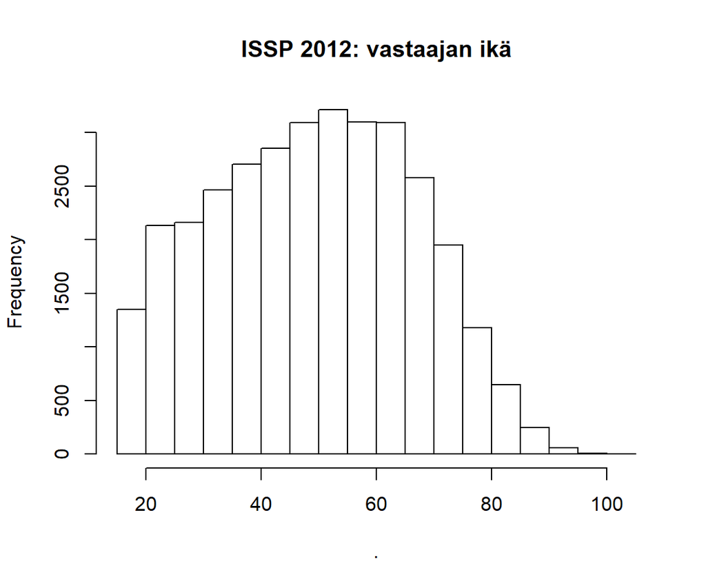

```r
ISSP2012jh1d.dat$ika %>% hist(main = "ISSP 2012: vastaajan ikä")
```

```r
# str(ISSP2012jh1d.dat) - tarkistus
```

### 1.6.2 Vaihe 2

Vaihessa 2 luodaan samalla samalla periaatteella substanssi- ja taustamuuttujille kaksi R-factor- tyypin muuttujaa. Toisessa (esim. Q1a) puuttuva tieto on R-ohjelmiston sisäinen NA-arvo. Toisessa (Q1am) puuttuva tieto on yksi luokittelumuuttujan arvo(“missing”).

### 1.6.3 Vaihe 2.1

```r
# Substanssi- ja taustamuuttujat R-faktoreiksi
ISSP2012jh1d.dat <- ISSP2012jh1d.dat %>%
    mutate(Q1a1 = as_factor(V5), #labels
            Q1b1 = as_factor(V6),
            Q1c1 = as_factor(V7),
            Q1d1 = as_factor(V8),
            Q1e1 = as_factor(V9),
            Q2a1 = as_factor(V10),
            Q2b1 = as_factor(V11),
            Q3a1 = as_factor(V12), #labels = vastQ3_labels (W,w,H)
            Q3b1 = as_factor(V13), #labels = vastQ3_labels
            edu1 = as_factor(DEGREE),
            msta1 = as_factor(MAINSTAT),
            sosta1 = as_factor(TOPBOT),
            nchild1 = as_factor(HHCHILDR),
            lifsta1 = as_factor(MARITAL),
            urbru1 = as_factor(URBRURAL)

    )

# Muuttujat Q1a1...urbru1 ovat apumuuttujia, joissa on periaatteessa kaikki SPSS-
# tiedostosta siirtyvä metatieto. Poikkeus on SPSS:n kolme tarkentavaa koodia
# puuttuvalle tiedolle, ne saisi mukaan read_spss - parametrin avulla (user_na=TRUE)
#

# Tarkistusksia
# ISSP2012jh1d.dat %>% summary()

ISSP2012jh1d.dat %>%
    select(Q1a1, Q1b1, Q1c1,Q1d1,Q1e1, Q2a1, Q2b1, Q3a1,Q3b1) %>%
    summary()
```

|  | Q1a1 | Q1b1 | Q1c1 | Q1d1 | Q1e1 | Q2a1 | Q2b1 | Q3a1 | Q3b1 |
| --- | --- | --- | --- | --- | --- | --- | --- | --- | --- |
|  | Agree :12352 | Disagree :9003 | Disagree :8706 | Disagree :7863 | Agree :8342 | Agree :13464 | Disagree :9210 | Work full-time : 5373 | Work full-time :13722 |
|  | Strongly agree :11116 | Agree :8389 | Agree :8263 | Agree :7672 | Neither agree nor disagree:7841 | Strongly agree :11305 | Strongly disagree :8917 | Work part-time :15655 | Work part-time :13817 |
|  | Disagree : 4074 | Neither agree nor disagree:5949 | Neither agree nor disagree:6000 | Neither agree nor disagree:7403 | Disagree :7267 | Neither agree nor disagree: 5039 | Neither agree nor disagree:6109 | Stay at home : 8367 | Stay at home : 1762 |
|  | Neither agree nor disagree: 3382 | Strongly disagree :5547 | Strongly disagree :5960 | Strongly disagree :5016 | Strongly disagree :3462 | Disagree : 1929 | Agree :5164 | TW: women should decide : 0 | TW: women should decide : 0 |
|  | Strongly disagree : 1051 | Strongly agree :2747 | Strongly agree :2838 | Strongly agree :2818 | Strongly agree :3357 | Strongly disagree : 403 | Strongly agree :2704 | Can’t choose, CA:+NA, KR:DK,ref., NL:DK: 0 | Can’t choose, CA:+NA, KR:DK,ref., NL:DK: 0 |
|  | (Other) : 0 | (Other) : 0 | (Other) : 0 | (Other) : 0 | (Other) : 0 | (Other) : 0 | (Other) : 0 | No answer : 0 | No answer : 0 |
|  | NA’s : 848 | NA’s :1188 | NA’s :1056 | NA’s :2051 | NA’s :2554 | NA’s : 683 | NA’s : 719 | NA’s : 3428 | NA’s : 3522 |

```r
ISSP2012jh1d.dat %>%
    select(edu1,msta1, sosta1, nchild1, lifsta1, urbru1) %>%
    summary()
```

|  | edu1 | msta1 | sosta1 | nchild1 | lifsta1 | urbru1 |
| --- | --- | --- | --- | --- | --- | --- |
|  | Lower secondary (secondary completed does not allow entry to university: obligatory school) :7811 | In paid work :17967 | 06 :6889 | No children:24102 | Married :17573 | A town or a small city :9203 |
|  | Upper secondary (programs that allows entry to university :7115 | Retired : 7999 | 05 :6798 | One child : 4378 | Never married/ never in a civil partnership, single : 7535 | A country village :8646 |
|  | Post secondary, non-tertiary (other upper secondary programs toward labour market or technical formation):5658 | Unemployed and looking for a job, HR: incl never had a job: 1769 | 07 :5778 | 2 children : 2643 | Divorced from spouse/ legally separated from civil partner: 2997 | A big city :8442 |
|  | Lower level tertiary, first stage (also technical schools at a tertiary level) :5147 | In education : 1763 | 08 :3477 | 3 : 598 | Widowed/ civil partner died : 2763 | The suburbs or outskirts of a big city:4386 |
|  | Upper level tertiary (Master, Dr.) :4762 | Domestic work : 1180 | 04 :3346 | 4 : 117 | Civil partnership : 1035 | A farm or home in the country :1902 |
|  | (Other) :2022 | (Other) : 1775 | (Other):4758 | (Other) : 45 | (Other) : 486 | (Other) : 0 |
|  | NA’s : 308 | NA’s : 370 | NA’s :1777 | NA’s : 940 | NA’s : 434 | NA’s : 244 |

```r
# Substanssimuuttujat - ristiintaulukoinnit riittävät (6.2.20)

# ISSP2012jh1d.dat$Q1a1 %>% fct_count()
# ISSP2012jh1d.dat$Q1b1 %>% fct_count()
# ISSP2012jh1d.dat$Q1c1 %>% fct_count()
# ISSP2012jh1d.dat$Q1d1 %>% fct_count()
# ISSP2012jh1d.dat$Q1e1 %>% fct_count()
# ISSP2012jh1d.dat$Q2a1 %>% fct_count()
# ISSP2012jh1d.dat$Q2b1 %>% fct_count()
# ISSP2012jh1d.dat$Q3a1 %>% fct_count()
#ISSP2012jh1d.dat$Q3b1 %>% fct_count()

# Taustamuuttujat - ristiintaulukoinnit riittävät (6.2.20)

# ISSP2012jh1d.dat$edu1 %>% fct_count()
# ISSP2012jh1d.dat$msta1 %>% fct_count()
# ISSP2012jh1d.dat$sosta1 %>% fct_count()
# ISSP2012jh1d.dat$nchild1 %>% fct_count()
# ISSP2012jh1d.dat$lifsta1 %>% fct_count()
# ISSP2012jh1d.dat$urbru1 %>% fct_count()
```

Taustamuuttujien luokitteluja (esim. luokkien yhdistäminen) pohditaan tarkemmin, kun muuttujat otetaan käyttöön.

### 1.6.4 Vaihe 2.2

Poistetaan muuuttujista luokittelumuuttujien arvot, joissa ei ole havaintoja. Näitä tyhjiä luokkia siirtyy SPSS-tiedostosta haven_labelled -luokan tietohin.

```r
# Poistetaan tyhjät luokat muuttujista

ISSP2012jh1d.dat <- ISSP2012jh1d.dat %>%
    mutate(Q1a = fct_drop(Q1a1),
           Q1b = fct_drop(Q1b1),
           Q1c = fct_drop(Q1c1),
           Q1d = fct_drop(Q1d1),
           Q1e = fct_drop(Q1e1),
           Q2a = fct_drop(Q2a1),
           Q2b = fct_drop(Q2b1),
           Q3a = fct_drop(Q3a1),
           Q3b = fct_drop(Q3b1),
           edu = fct_drop(edu1),
           msta = fct_drop(msta1),
           sosta = fct_drop(sosta1),
           nchild = fct_drop(nchild1),
           lifsta = fct_drop(lifsta1),
           urbru = fct_drop(urbru1)

    )
# Tarkistuksia 1

ISSP2012jh1d.dat %>% summary()
```

|  | V1 | V2 | DOI | V3 | V4 | C_ALPHAN | V5 | V6 | V7 | V8 | V9 | V10 | V11 | V12 | V13 | SEX | AGE | DEGREE | MAINSTAT | TOPBOT | HHCHILDR | MARITAL | URBRURAL | maa | maa3 | sp1 | sp | ika | Q1a1 | … |
| --- | --- | --- | --- | --- | --- | --- | --- | --- | --- | --- | --- | --- | --- | --- | --- | --- | --- | --- | --- | --- | --- | --- | --- | --- | --- | --- | --- | --- | --- | --- |
|  | Min. :5900 | Length:32823 | Length:32823 | Min. : 36 | Min. : 36.0 | Length:32823 | Min. :1.000 | Min. :1.000 | Min. :1.000 | Min. :1.000 | Min. :1.000 | Min. :1.000 | Min. :1.000 | Min. :1.000 | Min. :1.000 | Min. :1.000 | Min. : 15.00 | Min. :0.00 | Min. :1.000 | Min. : 1.00 | Min. : 0.0000 | Min. :1.000 | Min. :1.000 | FR : 2409 | FR-France : 2409 | Male :14789 | m:14789 | Min. : 15.00 | Agree :12352 | … |
|  | 1st Qu.:5900 | Class :character | Class :character | 1st Qu.: 208 | 1st Qu.:203.0 | Class :character | 1st Qu.:1.000 | 1st Qu.:2.000 | 1st Qu.:2.000 | 1st Qu.:2.000 | 1st Qu.:2.000 | 1st Qu.:1.000 | 1st Qu.:3.000 | 1st Qu.:2.000 | 1st Qu.:1.000 | 1st Qu.:1.000 | 1st Qu.: 36.00 | 1st Qu.:2.00 | 1st Qu.:1.000 | 1st Qu.: 5.00 | 1st Qu.: 0.0000 | 1st Qu.:1.000 | 1st Qu.:1.000 | BE : 2192 | CZ-Czech Republic: 1804 | Female :18034 | f:18034 | 1st Qu.: 36.00 | Strongly agree :11116 | … |
|  | Median :5900 | Mode :character | Mode :character | Median : 428 | Median :276.0 | Mode :character | Median :2.000 | Median :3.000 | Median :3.000 | Median :3.000 | Median :3.000 | Median :2.000 | Median :4.000 | Median :2.000 | Median :2.000 | Median :2.000 | Median : 50.00 | Median :3.00 | Median :1.000 | Median : 6.00 | Median : 0.0000 | Median :1.000 | Median :3.000 | CZ : 1804 | AU-Australia : 1557 | No answer: 0 | NA | Median : 50.00 | Disagree : 4074 | … |
|  | Mean :5900 | NA | NA | Mean : 4063 | Mean :362.1 | NA | Mean :2.112 | Mean :3.196 | Mean :3.211 | Mean :3.149 | Mean :2.971 | Mean :1.963 | Mean :3.513 | Mean :2.102 | Mean :1.592 | Mean :1.549 | Mean : 49.52 | Mean :3.55 | Mean :2.887 | Mean : 5.68 | Mean : 0.3832 | Mean :2.844 | Mean :2.729 | DE : 1761 | RU-Russia : 1525 | NA | NA | Mean : 49.52 | Neither agree nor disagree: 3382 | … |
|  | 3rd Qu.:5900 | NA | NA | 3rd Qu.: 705 | 3rd Qu.:578.0 | NA | 3rd Qu.:3.000 | 3rd Qu.:4.000 | 3rd Qu.:4.000 | 3rd Qu.:4.000 | 3rd Qu.:4.000 | 3rd Qu.:2.000 | 3rd Qu.:5.000 | 3rd Qu.:3.000 | 3rd Qu.:2.000 | 3rd Qu.:2.000 | 3rd Qu.: 63.00 | 3rd Qu.:5.00 | 3rd Qu.:6.000 | 3rd Qu.: 7.00 | 3rd Qu.: 0.0000 | 3rd Qu.:5.000 | 3rd Qu.:4.000 | AU : 1557 | NO-Norway : 1444 | NA | NA | 3rd Qu.: 63.00 | Strongly disagree : 1051 | … |
|  | Max. :5900 | NA | NA | Max. :62002 | Max. :756.0 | NA | Max. :5.000 | Max. :5.000 | Max. :5.000 | Max. :5.000 | Max. :5.000 | Max. :5.000 | Max. :5.000 | Max. :3.000 | Max. :3.000 | Max. :2.000 | Max. :102.00 | Max. :6.00 | Max. :9.000 | Max. :10.00 | Max. :21.0000 | Max. :6.000 | Max. :5.000 | RU : 1525 | DK-Denmark : 1403 | NA | NA | Max. :102.00 | (Other) : 0 | … |
|  | NA | NA | NA | NA | NA | NA | NA’s :848 | NA’s :1188 | NA’s :1056 | NA’s :2051 | NA’s :2554 | NA’s :683 | NA’s :719 | NA’s :3428 | NA’s :3522 | NA | NA | NA’s :308 | NA’s :370 | NA’s :1777 | NA’s :940 | NA’s :434 | NA’s :244 | (Other):21575 | (Other) :22681 | NA | NA | NA | NA’s : 848 | … |

```r
ISSP2012jh1d.dat %>%
    select(Q1a, Q1b, Q1c, Q1d, Q1e,Q2a,Q2b,Q3a, Q3b) %>%
    str()
```

```
## tibble [32,823 x 9] (S3: tbl_df/tbl/data.frame)
##  $ Q1a: Factor w/ 5 levels "Strongly agree",..: 5 1 2 2 1 NA 2 4 2 2 ...
##   ..- attr(*, "label")= chr "Q1a Working mom: warm relationship with children as a not working mom"
##  $ Q1b: Factor w/ 5 levels "Strongly agree",..: 1 5 4 4 4 NA 4 3 4 3 ...
##   ..- attr(*, "label")= chr "Q1b Working mom: Preschool child is likely to suffer"
##  $ Q1c: Factor w/ 5 levels "Strongly agree",..: 3 5 2 4 4 NA 4 2 4 2 ...
##   ..- attr(*, "label")= chr "Q1c Working woman: Family life suffers when woman has full-time job"
##  $ Q1d: Factor w/ 5 levels "Strongly agree",..: 3 5 5 2 4 NA 4 5 4 5 ...
##   ..- attr(*, "label")= chr "Q1d Working woman: What women really want is home and kids"
##  $ Q1e: Factor w/ 5 levels "Strongly agree",..: 3 1 2 3 4 NA 2 4 4 1 ...
##   ..- attr(*, "label")= chr "Q1e Working woman: Being housewife is as fulfilling as working for pay"
##  $ Q2a: Factor w/ 5 levels "Strongly agree",..: 1 3 4 2 2 NA 2 5 2 1 ...
##   ..- attr(*, "label")= chr "Q2a Both should contribute to household income"
##  $ Q2b: Factor w/ 5 levels "Strongly agree",..: 3 5 4 4 4 NA 2 5 4 1 ...
##   ..- attr(*, "label")= chr "Q2b Men's job earn money, women's job look after home"
##  $ Q3a: Factor w/ 3 levels "Work full-time",..: 3 NA NA 2 2 NA 2 NA 2 2 ...
##   ..- attr(*, "label")= chr "Q3a Should women work: Child under school age"
##  $ Q3b: Factor w/ 3 levels "Work full-time",..: 2 NA 2 1 2 NA 2 NA 2 2 ...
##   ..- attr(*, "label")= chr "Q3b Should women work: Youngest kid at school"
##  - attr(*, "notes")= chr [1:45] "document Plan File: /Users/marcic/Desktop/old/GPS2011 sampling/ISSP2013.sampling" "         .csplan" "         Weight Variable: SampleWeight_Final_" "         Stage 1" ...
```

```r
ISSP2012jh1d.dat %>%
    select(Q1a1, Q1b1, Q1c1, Q1d1, Q1e1,Q2a1,Q2b1,Q3a1, Q3b1) %>%
    str()
```

```
## tibble [32,823 x 9] (S3: tbl_df/tbl/data.frame)
##  $ Q1a1: Factor w/ 8 levels "NAP: ES","Strongly agree",..: 6 2 3 3 2 NA 3 5 3 3 ...
##   ..- attr(*, "label")= chr "Q1a Working mom: warm relationship with children as a not working mom"
##  $ Q1b1: Factor w/ 8 levels "NAP: ES","Strongly agree",..: 2 6 5 5 5 NA 5 4 5 4 ...
##   ..- attr(*, "label")= chr "Q1b Working mom: Preschool child is likely to suffer"
##  $ Q1c1: Factor w/ 8 levels "NAP: ES","Strongly agree",..: 4 6 3 5 5 NA 5 3 5 3 ...
##   ..- attr(*, "label")= chr "Q1c Working woman: Family life suffers when woman has full-time job"
##  $ Q1d1: Factor w/ 8 levels "NAP: ES","Strongly agree",..: 4 6 6 3 5 NA 5 6 5 6 ...
##   ..- attr(*, "label")= chr "Q1d Working woman: What women really want is home and kids"
##  $ Q1e1: Factor w/ 8 levels "NAP: ES","Strongly agree",..: 4 2 3 4 5 NA 3 5 5 2 ...
##   ..- attr(*, "label")= chr "Q1e Working woman: Being housewife is as fulfilling as working for pay"
##  $ Q2a1: Factor w/ 8 levels "NAP: ES","Strongly agree",..: 2 4 5 3 3 NA 3 6 3 2 ...
##   ..- attr(*, "label")= chr "Q2a Both should contribute to household income"
##  $ Q2b1: Factor w/ 8 levels "NAP: ES","Strongly agree",..: 4 6 5 5 5 NA 3 6 5 2 ...
##   ..- attr(*, "label")= chr "Q2b Men's job earn money, women's job look after home"
##  $ Q3a1: Factor w/ 6 levels "Work full-time",..: 3 NA NA 2 2 NA 2 NA 2 2 ...
##   ..- attr(*, "label")= chr "Q3a Should women work: Child under school age"
##  $ Q3b1: Factor w/ 6 levels "Work full-time",..: 2 NA 2 1 2 NA 2 NA 2 2 ...
##   ..- attr(*, "label")= chr "Q3b Should women work: Youngest kid at school"
##  - attr(*, "notes")= chr [1:45] "document Plan File: /Users/marcic/Desktop/old/GPS2011 sampling/ISSP2013.sampling" "         .csplan" "         Weight Variable: SampleWeight_Final_" "         Stage 1" ...
```

```r
ISSP2012jh1d.dat %>%
    select(edu, msta, sosta, nchild,lifsta, urbru) %>%
    str()
```

```
## tibble [32,823 x 6] (S3: tbl_df/tbl/data.frame)
##  $ edu   : Factor w/ 7 levels "No formal education",..: 3 6 6 4 3 NA NA 7 6 7 ...
##   ..- attr(*, "label")= chr "Highest completed degree of education: Categories for international comparison"
##  $ msta  : Factor w/ 9 levels "In paid work",..: 6 6 3 1 6 5 6 2 1 5 ...
##   ..- attr(*, "label")= chr "Main status"
##  $ sosta : Factor w/ 10 levels "Lowest, Bottom, 01",..: 3 7 8 NA 7 2 7 NA 10 6 ...
##   ..- attr(*, "label")= chr "Top-Bottom self-placement"
##  $ nchild: Factor w/ 11 levels "No children",..: NA NA 4 2 1 NA 1 1 2 NA ...
##   ..- attr(*, "label")= chr "How many children in household: children between [school age] and 17 years of age"
##  $ lifsta: Factor w/ 6 levels "Married","Civil partnership",..: 6 1 1 6 1 6 1 1 1 NA ...
##   ..- attr(*, "label")= chr "Legal partnership status"
##  $ urbru : Factor w/ 5 levels "A big city","The suburbs or outskirts of a big city",..: 1 1 1 NA 1 2 NA 2 2 NA ...
##   ..- attr(*, "label")= chr "Place of living: urban - rural"
##  - attr(*, "notes")= chr [1:45] "document Plan File: /Users/marcic/Desktop/old/GPS2011 sampling/ISSP2013.sampling" "         .csplan" "         Weight Variable: SampleWeight_Final_" "         Stage 1" ...
```

```r
ISSP2012jh1d.dat %>%
    select(edu1, msta1, sosta1, nchild1,lifsta1, urbru1) %>%
    str()
```

```
## tibble [32,823 x 6] (S3: tbl_df/tbl/data.frame)
##  $ edu1   : Factor w/ 8 levels "No formal education",..: 3 6 6 4 3 NA NA 7 6 7 ...
##   ..- attr(*, "label")= chr "Highest completed degree of education: Categories for international comparison"
##  $ msta1  : Factor w/ 10 levels "In paid work",..: 6 6 3 1 6 5 6 2 1 5 ...
##   ..- attr(*, "label")= chr "Main status"
##  $ sosta1 : Factor w/ 14 levels "Not available: GB,US",..: 4 8 9 NA 8 3 8 NA 11 7 ...
##   ..- attr(*, "label")= chr "Top-Bottom self-placement"
##  $ nchild1: Factor w/ 14 levels "No children",..: NA NA 4 2 1 NA 1 1 2 NA ...
##   ..- attr(*, "label")= chr "How many children in household: children between [school age] and 17 years of age"
##  $ lifsta1: Factor w/ 9 levels "Married","Civil partnership",..: 6 1 1 6 1 6 1 1 1 NA ...
##   ..- attr(*, "label")= chr "Legal partnership status"
##  $ urbru1 : Factor w/ 7 levels "A big city","The suburbs or outskirts of a big city",..: 1 1 1 NA 1 2 NA 2 2 NA ...
##   ..- attr(*, "label")= chr "Place of living: urban - rural"
##  - attr(*, "notes")= chr [1:45] "document Plan File: /Users/marcic/Desktop/old/GPS2011 sampling/ISSP2013.sampling" "         .csplan" "         Weight Variable: SampleWeight_Final_" "         Stage 1" ...
```

```r
# Tarkistuksia 2 - ristiintaulukointi Q1a/Q1am riittää (6.2.20)

# Substanssimuuttujat

# ISSP2012jh1d.dat %>% tableX(Q1a,Q1a1)
# ISSP2012jh1d.dat %>% tableX(Q1b,Q1b1)
# ISSP2012jh1d.dat %>% tableX(Q1c,Q1c1)
# ISSP2012jh1d.dat %>% tableX(Q1d,Q1d1)
# ISSP2012jh1d.dat %>% tableX(Q1e,Q1e1)
# ISSP2012jh1d.dat %>% tableX(Q2a,Q2a1)
# ISSP2012jh1d.dat %>% tableX(Q2b,Q2b1)
# ISSP2012jh1d.dat %>% tableX(Q3a,Q3a1)
# ISSP2012jh1d.dat %>% tableX(Q3b,Q3b1)

# Taustamuuttujat

# ISSP2012jh1d.dat %>% tableX(edu,edu1)
# ISSP2012jh1d.dat %>% tableX(msta,msta1)
# ISSP2012jh1d.dat %>% tableX(sosta,sosta1)
# ISSP2012jh1d.dat %>% tableX(nchild,nchild1)
# ISSP2012jh1d.dat %>% tableX(lifsta,lifsta1)
# ISSP2012jh1d.dat %>% tableX(urbru,urbru1)
```

### 1.6.5 Vaihe 2.3

Luodaan uusi muuttuja, jossa puuttuva tieto (NA) on mukana luokittelumuuttujan uutena arvona (“missing”).

```r
# Uusi muuttuja, jossa NA-arvot ovat mukana muuttujan uutena luokkana. Muuttujat
# nimetään Q1a -> Q1am.

ISSP2012jh1d.dat <- ISSP2012jh1d.dat %>%
    mutate(Q1am = fct_explicit_na(Q1a, na_level = "missing"),
           Q1bm = fct_explicit_na(Q1b, na_level = "missing"),
           Q1cm = fct_explicit_na(Q1c, na_level = "missing"),
           Q1dm = fct_explicit_na(Q1d, na_level = "missing"),
           Q1em = fct_explicit_na(Q1e, na_level = "missing"),
           Q2am = fct_explicit_na(Q2a, na_level = "missing"),
           Q2bm = fct_explicit_na(Q2b, na_level = "missing"),
           Q3am = fct_explicit_na(Q3a, na_level = "missing"),
           Q3bm = fct_explicit_na(Q3b, na_level = "missing"),
           edum = fct_explicit_na(edu, na_level = "missing"),
           mstam = fct_explicit_na(msta, na_level = "missing"),
           sostam = fct_explicit_na(sosta, na_level = "missing"),
           nchildm = fct_explicit_na(nchild, na_level = "missing"),
           lifstam = fct_explicit_na(lifsta, na_level = "missing"),
           urbrum = fct_explicit_na(urbru, na_level = "missing"),
           )
# Tarkistuksia 3

ISSP2012jh1d.dat %>%
    select(Q1am, Q1bm, Q1cm, Q1dm, Q1em, Q2am, Q2bm, Q3am, Q3bm) %>%
    summary()
```

|  | Q1am | Q1bm | Q1cm | Q1dm | Q1em | Q2am | Q2bm | Q3am | Q3bm |
| --- | --- | --- | --- | --- | --- | --- | --- | --- | --- |
|  | Strongly agree :11116 | Strongly agree :2747 | Strongly agree :2838 | Strongly agree :2818 | Strongly agree :3357 | Strongly agree :11305 | Strongly agree :2704 | Work full-time: 5373 | Work full-time:13722 |
|  | Agree :12352 | Agree :8389 | Agree :8263 | Agree :7672 | Agree :8342 | Agree :13464 | Agree :5164 | Work part-time:15655 | Work part-time:13817 |
|  | Neither agree nor disagree: 3382 | Neither agree nor disagree:5949 | Neither agree nor disagree:6000 | Neither agree nor disagree:7403 | Neither agree nor disagree:7841 | Neither agree nor disagree: 5039 | Neither agree nor disagree:6109 | Stay at home : 8367 | Stay at home : 1762 |
|  | Disagree : 4074 | Disagree :9003 | Disagree :8706 | Disagree :7863 | Disagree :7267 | Disagree : 1929 | Disagree :9210 | missing : 3428 | missing : 3522 |
|  | Strongly disagree : 1051 | Strongly disagree :5547 | Strongly disagree :5960 | Strongly disagree :5016 | Strongly disagree :3462 | Strongly disagree : 403 | Strongly disagree :8917 | NA | NA |
|  | missing : 848 | missing :1188 | missing :1056 | missing :2051 | missing :2554 | missing : 683 | missing : 719 | NA | NA |

```r
ISSP2012jh1d.dat %>%
    select(edum,mstam, sostam,nchildm,lifstam, urbrum) %>%
    summary()
```

|  | edum | mstam | sostam | nchildm | lifstam | urbrum |
| --- | --- | --- | --- | --- | --- | --- |
|  | Lower secondary (secondary completed does not allow entry to university: obligatory school) :7811 | In paid work :17967 | 06 :6889 | No children:24102 | Married :17573 | A big city :8442 |
|  | Upper secondary (programs that allows entry to university :7115 | Retired : 7999 | 05 :6798 | One child : 4378 | Civil partnership : 1035 | The suburbs or outskirts of a big city:4386 |
|  | Post secondary, non-tertiary (other upper secondary programs toward labour market or technical formation):5658 | Unemployed and looking for a job, HR: incl never had a job: 1769 | 07 :5778 | 2 children : 2643 | Separated from spouse/ civil partner (still legally married/ still legally in a civil partnership): 486 | A town or a small city :9203 |
|  | Lower level tertiary, first stage (also technical schools at a tertiary level) :5147 | In education : 1763 | 08 :3477 | missing : 940 | Divorced from spouse/ legally separated from civil partner : 2997 | A country village :8646 |
|  | Upper level tertiary (Master, Dr.) :4762 | Domestic work : 1180 | 04 :3346 | 3 : 598 | Widowed/ civil partner died : 2763 | A farm or home in the country :1902 |
|  | Primary school (elementary school) :1531 | Permanently sick or disabled : 1093 | 03 :2221 | 4 : 117 | Never married/ never in a civil partnership, single : 7535 | missing : 244 |
|  | (Other) : 799 | (Other) : 1052 | (Other):4314 | (Other) : 45 | missing : 434 | NA |

```r
ISSP2012jh1d.dat %>%
    select(Q1am, Q1bm, Q1cm, Q1dm, Q1em, Q2am, Q2bm, Q3am, Q3bm) %>%
    str()
```

```
## tibble [32,823 x 9] (S3: tbl_df/tbl/data.frame)
##  $ Q1am: Factor w/ 6 levels "Strongly agree",..: 5 1 2 2 1 6 2 4 2 2 ...
##   ..- attr(*, "label")= chr "Q1a Working mom: warm relationship with children as a not working mom"
##  $ Q1bm: Factor w/ 6 levels "Strongly agree",..: 1 5 4 4 4 6 4 3 4 3 ...
##   ..- attr(*, "label")= chr "Q1b Working mom: Preschool child is likely to suffer"
##  $ Q1cm: Factor w/ 6 levels "Strongly agree",..: 3 5 2 4 4 6 4 2 4 2 ...
##   ..- attr(*, "label")= chr "Q1c Working woman: Family life suffers when woman has full-time job"
##  $ Q1dm: Factor w/ 6 levels "Strongly agree",..: 3 5 5 2 4 6 4 5 4 5 ...
##   ..- attr(*, "label")= chr "Q1d Working woman: What women really want is home and kids"
##  $ Q1em: Factor w/ 6 levels "Strongly agree",..: 3 1 2 3 4 6 2 4 4 1 ...
##   ..- attr(*, "label")= chr "Q1e Working woman: Being housewife is as fulfilling as working for pay"
##  $ Q2am: Factor w/ 6 levels "Strongly agree",..: 1 3 4 2 2 6 2 5 2 1 ...
##   ..- attr(*, "label")= chr "Q2a Both should contribute to household income"
##  $ Q2bm: Factor w/ 6 levels "Strongly agree",..: 3 5 4 4 4 6 2 5 4 1 ...
##   ..- attr(*, "label")= chr "Q2b Men's job earn money, women's job look after home"
##  $ Q3am: Factor w/ 4 levels "Work full-time",..: 3 4 4 2 2 4 2 4 2 2 ...
##   ..- attr(*, "label")= chr "Q3a Should women work: Child under school age"
##  $ Q3bm: Factor w/ 4 levels "Work full-time",..: 2 4 2 1 2 4 2 4 2 2 ...
##   ..- attr(*, "label")= chr "Q3b Should women work: Youngest kid at school"
##  - attr(*, "notes")= chr [1:45] "document Plan File: /Users/marcic/Desktop/old/GPS2011 sampling/ISSP2013.sampling" "         .csplan" "         Weight Variable: SampleWeight_Final_" "         Stage 1" ...
```

```r
ISSP2012jh1d.dat %>%
    select(edum,mstam, sostam,nchildm,lifstam, urbrum) %>%
    str()
```

```
## tibble [32,823 x 6] (S3: tbl_df/tbl/data.frame)
##  $ edum   : Factor w/ 8 levels "No formal education",..: 3 6 6 4 3 8 8 7 6 7 ...
##   ..- attr(*, "label")= chr "Highest completed degree of education: Categories for international comparison"
##  $ mstam  : Factor w/ 10 levels "In paid work",..: 6 6 3 1 6 5 6 2 1 5 ...
##   ..- attr(*, "label")= chr "Main status"
##  $ sostam : Factor w/ 11 levels "Lowest, Bottom, 01",..: 3 7 8 11 7 2 7 11 10 6 ...
##   ..- attr(*, "label")= chr "Top-Bottom self-placement"
##  $ nchildm: Factor w/ 12 levels "No children",..: 12 12 4 2 1 12 1 1 2 12 ...
##   ..- attr(*, "label")= chr "How many children in household: children between [school age] and 17 years of age"
##  $ lifstam: Factor w/ 7 levels "Married","Civil partnership",..: 6 1 1 6 1 6 1 1 1 7 ...
##   ..- attr(*, "label")= chr "Legal partnership status"
##  $ urbrum : Factor w/ 6 levels "A big city","The suburbs or outskirts of a big city",..: 1 1 1 6 1 2 6 2 2 6 ...
##   ..- attr(*, "label")= chr "Place of living: urban - rural"
##  - attr(*, "notes")= chr [1:45] "document Plan File: /Users/marcic/Desktop/old/GPS2011 sampling/ISSP2013.sampling" "         .csplan" "         Weight Variable: SampleWeight_Final_" "         Stage 1" ...
```

```r
# Taustamuuttuja, puuttuva tieto mukana - ristiintaulkointi riittää (6.2.20)

# ISSP2012jh1d.dat$edum %>% fct_count()
# ISSP2012jh1d.dat$mstam %>% fct_count()
# ISSP2012jh1d.dat$sostam %>% fct_count()
# ISSP2012jh1d.dat$nchildm %>% fct_count()
# ISSP2012jh1d.dat$lifstam %>% fct_count()
# ISSP2012jh1d.dat$urbrum %>% fct_count()

# Substanssimuuttujat, puuttuva tieto mukana  - ristiintaulkointi riittää (6.2.20)

# ISSP2012jh1d.dat$Q1am %>% fct_count()
# ISSP2012jh1d.dat$Q1bm %>% fct_count()
# ISSP2012jh1d.dat$Q1cm %>% fct_count()
# ISSP2012jh1d.dat$Q1dm %>% fct_count()
# ISSP2012jh1d.dat$Q1em %>% fct_count()
# ISSP2012jh1d.dat$Q2am %>% fct_count()
# ISSP2012jh1d.dat$Q2bm %>% fct_count()
# ISSP2012jh1d.dat$Q3am %>% fct_count()
# ISSP2012jh1d.dat$Q3bm %>% fct_count()
```

### 1.6.6 Vaihe 2.4

Lopuksi luodaan uudet “faktorilabelit” substanssimuuttujille. Näkyvät komennolla levels(). Graafisessa analyysissä kuviin on saatava mukaan kaikki oleellinen, mutta ei mitään sen lisäksi. Näitä muuttujan arvojen tunnuksia muokataan tarvittaessa.

Taustamuuttujien “faktorilabeleita” säädetään kun ne otetaan käyttöön.

```r
# Vaihe 2.4.1

# Q1a - Q1e,Q2a, Q2b  Viisi vastausvaihtoehtoa - ei eksplisiittistä NA-tietoa("missing")
# Q3a - Q3b  kolme vastausvaihtoehtoa

ISSP2012jh1d.dat <- ISSP2012jh1d.dat %>%
    mutate(Q1a = fct_recode(Q1a,
                        "S" = "Strongly agree",
                        "s" = "Agree",
                        "?" = "Neither agree nor disagree",
                        "e" = "Disagree",
                        "E"= "Strongly disagree"),
            Q1b = fct_recode(Q1b,
                      "S" = "Strongly agree",
                      "s" = "Agree",
                      "?" = "Neither agree nor disagree",
                      "e" = "Disagree",
                      "E" = "Strongly disagree"),
           Q1c = fct_recode(Q1c,
                           "S" = "Strongly agree",
                           "s" = "Agree",
                           "?" = "Neither agree nor disagree",
                           "e" = "Disagree",
                           "E" = "Strongly disagree"),
           Q1d = fct_recode(Q1d,
                           "S" = "Strongly agree",
                           "s" = "Agree",
                           "?" = "Neither agree nor disagree",
                           "e" = "Disagree",
                           "E" = "Strongly disagree"),
           Q1e = fct_recode(Q1e,
                           "S" = "Strongly agree",
                           "s" = "Agree",
                           "?" = "Neither agree nor disagree",
                           "e" = "Disagree",
                           "E" = "Strongly disagree"),
          Q2a = fct_recode(Q2a,
                           "S" = "Strongly agree",
                           "s" = "Agree",
                           "?" = "Neither agree nor disagree",
                           "e" = "Disagree",
                           "E" = "Strongly disagree" ),
          Q2b = fct_recode(Q2b,
                           "S" = "Strongly agree",
                           "s" = "Agree",
                           "?" = "Neither agree nor disagree",
                           "e" = "Disagree",
                           "E" = "Strongly disagree"),
          Q3a = fct_recode(Q3a,
                          "W" = "Work full-time",
                          "w" = "Work part-time",
                          "H" = "Stay at home" ),
          Q3b = fct_recode(Q3b,
                           "W" = "Work full-time",
                           "w" = "Work part-time",
                           "H" = "Stay at home" )
                        )


# Tarkistuksia 1
ISSP2012jh1d.dat %>%
    select(Q1a, Q1b, Q1c, Q1d, Q1e, Q2a, Q2b, Q3a, Q3b) %>%
    summary()
```

|  | Q1a | Q1b | Q1c | Q1d | Q1e | Q2a | Q2b | Q3a | Q3b |
| --- | --- | --- | --- | --- | --- | --- | --- | --- | --- |
|  | S :11116 | S :2747 | S :2838 | S :2818 | S :3357 | S :11305 | S :2704 | W : 5373 | W :13722 |
|  | s :12352 | s :8389 | s :8263 | s :7672 | s :8342 | s :13464 | s :5164 | w :15655 | w :13817 |
|  | ? : 3382 | ? :5949 | ? :6000 | ? :7403 | ? :7841 | ? : 5039 | ? :6109 | H : 8367 | H : 1762 |
|  | e : 4074 | e :9003 | e :8706 | e :7863 | e :7267 | e : 1929 | e :9210 | NA’s: 3428 | NA’s: 3522 |
|  | E : 1051 | E :5547 | E :5960 | E :5016 | E :3462 | E : 403 | E :8917 | NA | NA |
|  | NA’s: 848 | NA’s:1188 | NA’s:1056 | NA’s:2051 | NA’s:2554 | NA’s: 683 | NA’s: 719 | NA | NA |

```r
# Vaihe 2.4.2 - muuttujassa eksplisiittinen NA-tieto
ISSP2012jh1d.dat <- ISSP2012jh1d.dat %>%
    mutate(Q1am = fct_recode(Q1am,
                            "S" = "Strongly agree",
                            "s" = "Agree",
                            "?" = "Neither agree nor disagree",
                            "e" = "Disagree",
                            "E" = "Strongly disagree",
                            "P" = "missing"),
           Q1bm = fct_recode(Q1bm,
                           "S" = "Strongly agree",
                           "s" = "Agree",
                           "?" = "Neither agree nor disagree",
                           "e" = "Disagree",
                           "E" = "Strongly disagree",
                           "P" = "missing"),
           Q1cm = fct_recode(Q1cm,
                           "S" = "Strongly agree",
                           "s" = "Agree",
                           "?" = "Neither agree nor disagree",
                           "e" = "Disagree",
                           "E" = "Strongly disagree",
                           "P" = "missing"),
           Q1dm = fct_recode(Q1dm,
                           "S" = "Strongly agree",
                           "s" = "Agree",
                           "?" = "Neither agree nor disagree",
                           "e" = "Disagree",
                           "E" = "Strongly disagree",
                           "P" = "missing"),
           Q1em = fct_recode(Q1em,
                           "S" = "Strongly agree",
                           "s" = "Agree",
                           "?" = "Neither agree nor disagree",
                           "e" = "Disagree",
                           "E" = "Strongly disagree",
                           "P" = "missing"),
           Q2am = fct_recode(Q2am,
                            "S" = "Strongly agree",
                            "s" = "Agree",
                            "?" = "Neither agree nor disagree",
                            "e" = "Disagree",
                            "E" = "Strongly disagree",
                            "P" = "missing"),
           Q2bm = fct_recode(Q2bm,
                            "S" = "Strongly agree",
                            "s" = "Agree",
                            "?" = "Neither agree nor disagree",
                            "e" = "Disagree",
                            "E" = "Strongly disagree",
                            "P" = "missing"),
           Q3am = fct_recode(Q3am,
                            "W" = "Work full-time",
                            "w" = "Work part-time",
                            "H" = "Stay at home",
                            "P" = "missing"),
           Q3bm = fct_recode(Q3bm,
                            "W" = "Work full-time",
                            "w" = "Work part-time",
                            "H" = "Stay at home",
                            "P" = "missing")
               )

# Tarkistuksia 4

ISSP2012jh1d.dat %>%
    select(Q1am, Q1bm, Q1cm, Q1dm, Q1em, Q2am, Q2bm, Q3am, Q3bm) %>%
    summary()
```

|  | Q1am | Q1bm | Q1cm | Q1dm | Q1em | Q2am | Q2bm | Q3am | Q3bm |
| --- | --- | --- | --- | --- | --- | --- | --- | --- | --- |
|  | S:11116 | S:2747 | S:2838 | S:2818 | S:3357 | S:11305 | S:2704 | W: 5373 | W:13722 |
|  | s:12352 | s:8389 | s:8263 | s:7672 | s:8342 | s:13464 | s:5164 | w:15655 | w:13817 |
|  | ?: 3382 | ?:5949 | ?:6000 | ?:7403 | ?:7841 | ?: 5039 | ?:6109 | H: 8367 | H: 1762 |
|  | e: 4074 | e:9003 | e:8706 | e:7863 | e:7267 | e: 1929 | e:9210 | P: 3428 | P: 3522 |
|  | E: 1051 | E:5547 | E:5960 | E:5016 | E:3462 | E: 403 | E:8917 | NA | NA |
|  | P: 848 | P:1188 | P:1056 | P:2051 | P:2554 | P: 683 | P: 719 | NA | NA |

```r
# Tarkistuksia 5

# Substanssimuuttuja

ISSP2012jh1d.dat %>%
    tableX(Q1a,Q1am)
```

| Q1a/Q1am | S | s | ? | e | E | P | Total |
| --- | --- | --- | --- | --- | --- | --- | --- |
| 1 | 11116 | 0 | 0 | 0 | 0 | 0 | 11116 |
| 2 | 0 | 12352 | 0 | 0 | 0 | 0 | 12352 |
| 3 | 0 | 0 | 3382 | 0 | 0 | 0 | 3382 |
| 4 | 0 | 0 | 0 | 4074 | 0 | 0 | 4074 |
| 5 | 0 | 0 | 0 | 0 | 1051 | 0 | 1051 |
| Missing | 0 | 0 | 0 | 0 | 0 | 848 | 848 |
| Total | 11116 | 12352 | 3382 | 4074 | 1051 | 848 | 32823 |

```r
ISSP2012jh1d.dat %>%
    tableX(Q1b,Q1bm)
```

| Q1b/Q1bm | S | s | ? | e | E | P | Total |
| --- | --- | --- | --- | --- | --- | --- | --- |
| 1 | 2747 | 0 | 0 | 0 | 0 | 0 | 2747 |
| 2 | 0 | 8389 | 0 | 0 | 0 | 0 | 8389 |
| 3 | 0 | 0 | 5949 | 0 | 0 | 0 | 5949 |
| 4 | 0 | 0 | 0 | 9003 | 0 | 0 | 9003 |
| 5 | 0 | 0 | 0 | 0 | 5547 | 0 | 5547 |
| Missing | 0 | 0 | 0 | 0 | 0 | 1188 | 1188 |
| Total | 2747 | 8389 | 5949 | 9003 | 5547 | 1188 | 32823 |

```r
ISSP2012jh1d.dat %>%
    tableX(Q1c,Q1cm)
```

| Q1c/Q1cm | S | s | ? | e | E | P | Total |
| --- | --- | --- | --- | --- | --- | --- | --- |
| 1 | 2838 | 0 | 0 | 0 | 0 | 0 | 2838 |
| 2 | 0 | 8263 | 0 | 0 | 0 | 0 | 8263 |
| 3 | 0 | 0 | 6000 | 0 | 0 | 0 | 6000 |
| 4 | 0 | 0 | 0 | 8706 | 0 | 0 | 8706 |
| 5 | 0 | 0 | 0 | 0 | 5960 | 0 | 5960 |
| Missing | 0 | 0 | 0 | 0 | 0 | 1056 | 1056 |
| Total | 2838 | 8263 | 6000 | 8706 | 5960 | 1056 | 32823 |

```r
ISSP2012jh1d.dat %>%
    tableX(Q1d,Q1dm)
```

| Q1d/Q1dm | S | s | ? | e | E | P | Total |
| --- | --- | --- | --- | --- | --- | --- | --- |
| 1 | 2818 | 0 | 0 | 0 | 0 | 0 | 2818 |
| 2 | 0 | 7672 | 0 | 0 | 0 | 0 | 7672 |
| 3 | 0 | 0 | 7403 | 0 | 0 | 0 | 7403 |
| 4 | 0 | 0 | 0 | 7863 | 0 | 0 | 7863 |
| 5 | 0 | 0 | 0 | 0 | 5016 | 0 | 5016 |
| Missing | 0 | 0 | 0 | 0 | 0 | 2051 | 2051 |
| Total | 2818 | 7672 | 7403 | 7863 | 5016 | 2051 | 32823 |

```r
ISSP2012jh1d.dat %>%
    tableX(Q1e,Q1em)
```

| Q1e/Q1em | S | s | ? | e | E | P | Total |
| --- | --- | --- | --- | --- | --- | --- | --- |
| 1 | 3357 | 0 | 0 | 0 | 0 | 0 | 3357 |
| 2 | 0 | 8342 | 0 | 0 | 0 | 0 | 8342 |
| 3 | 0 | 0 | 7841 | 0 | 0 | 0 | 7841 |
| 4 | 0 | 0 | 0 | 7267 | 0 | 0 | 7267 |
| 5 | 0 | 0 | 0 | 0 | 3462 | 0 | 3462 |
| Missing | 0 | 0 | 0 | 0 | 0 | 2554 | 2554 |
| Total | 3357 | 8342 | 7841 | 7267 | 3462 | 2554 | 32823 |

```r
ISSP2012jh1d.dat %>%
    tableX(Q2a,Q2am)
```

| Q2a/Q2am | S | s | ? | e | E | P | Total |
| --- | --- | --- | --- | --- | --- | --- | --- |
| 1 | 11305 | 0 | 0 | 0 | 0 | 0 | 11305 |
| 2 | 0 | 13464 | 0 | 0 | 0 | 0 | 13464 |
| 3 | 0 | 0 | 5039 | 0 | 0 | 0 | 5039 |
| 4 | 0 | 0 | 0 | 1929 | 0 | 0 | 1929 |
| 5 | 0 | 0 | 0 | 0 | 403 | 0 | 403 |
| Missing | 0 | 0 | 0 | 0 | 0 | 683 | 683 |
| Total | 11305 | 13464 | 5039 | 1929 | 403 | 683 | 32823 |

```r
ISSP2012jh1d.dat %>%
    tableX(Q2b,Q2bm)
```

| Q2b/Q2bm | S | s | ? | e | E | P | Total |
| --- | --- | --- | --- | --- | --- | --- | --- |
| 1 | 2704 | 0 | 0 | 0 | 0 | 0 | 2704 |
| 2 | 0 | 5164 | 0 | 0 | 0 | 0 | 5164 |
| 3 | 0 | 0 | 6109 | 0 | 0 | 0 | 6109 |
| 4 | 0 | 0 | 0 | 9210 | 0 | 0 | 9210 |
| 5 | 0 | 0 | 0 | 0 | 8917 | 0 | 8917 |
| Missing | 0 | 0 | 0 | 0 | 0 | 719 | 719 |
| Total | 2704 | 5164 | 6109 | 9210 | 8917 | 719 | 32823 |

```r
ISSP2012jh1d.dat %>%
    tableX(Q3a,Q3am)
```

| Q3a/Q3am | W | w | H | P | Total |
| --- | --- | --- | --- | --- | --- |
| 1 | 5373 | 0 | 0 | 0 | 5373 |
| 2 | 0 | 15655 | 0 | 0 | 15655 |
| 3 | 0 | 0 | 8367 | 0 | 8367 |
| Missing | 0 | 0 | 0 | 3428 | 3428 |
| Total | 5373 | 15655 | 8367 | 3428 | 32823 |

```r
ISSP2012jh1d.dat %>%
    tableX(Q3b,Q3bm)
```

| Q3b/Q3bm | W | w | H | P | Total |
| --- | --- | --- | --- | --- | --- |
| 1 | 13722 | 0 | 0 | 0 | 13722 |
| 2 | 0 | 13817 | 0 | 0 | 13817 |
| 3 | 0 | 0 | 1762 | 0 | 1762 |
| Missing | 0 | 0 | 0 | 3522 | 3522 |
| Total | 13722 | 13817 | 1762 | 3522 | 32823 |

```r
ISSP2012jh1d.dat %>%  # tableX muotoilee taulukkoa!
    tableX(Q3am,Q3a)
```

| Q3am/Q3a | 1 | 2 | 3 | Missing | Total |
| --- | --- | --- | --- | --- | --- |
| W | 5373 | 0 | 0 | 0 | 5373 |
| w | 0 | 15655 | 0 | 0 | 15655 |
| H | 0 | 0 | 8367 | 0 | 8367 |
| P | 0 | 0 | 0 | 3428 | 3428 |
| Total | 5373 | 15655 | 8367 | 3428 | 32823 |

```r
ISSP2012jh1d.dat$Q3a %>% levels()
```

```
## [1] "W" "w" "H"
```

```r
ISSP2012jh1d.dat$Q3am %>% levels()
```

```
## [1] "W" "w" "H" "P"
```

```r
# Taustamuuttujat

ISSP2012jh1d.dat %>%
    tableX(edu, edum)
```

| edu/edum | No formal education | Primary school (elementary school) | Lower secondary (secondary completed does not allow entry to university: obligatory school) | Upper secondary (programs that allows entry to university | Post secondary, non-tertiary (other upper secondary programs toward labour market or technical formation) | Lower level tertiary, first stage (also technical schools at a tertiary level) | Upper level tertiary (Master, Dr.) | missing | Total |
| --- | --- | --- | --- | --- | --- | --- | --- | --- | --- |
| 1 | 491 | 0 | 0 | 0 | 0 | 0 | 0 | 0 | 491 |
| 2 | 0 | 1531 | 0 | 0 | 0 | 0 | 0 | 0 | 1531 |
| 3 | 0 | 0 | 7811 | 0 | 0 | 0 | 0 | 0 | 7811 |
| 4 | 0 | 0 | 0 | 7115 | 0 | 0 | 0 | 0 | 7115 |
| 5 | 0 | 0 | 0 | 0 | 5658 | 0 | 0 | 0 | 5658 |
| 6 | 0 | 0 | 0 | 0 | 0 | 5147 | 0 | 0 | 5147 |
| 7 | 0 | 0 | 0 | 0 | 0 | 0 | 4762 | 0 | 4762 |
| Missing | 0 | 0 | 0 | 0 | 0 | 0 | 0 | 308 | 308 |
| Total | 491 | 1531 | 7811 | 7115 | 5658 | 5147 | 4762 | 308 | 32823 |

```r
ISSP2012jh1d.dat %>%
    tableX(msta, mstam)
```

| msta/mstam | In paid work | Unemployed and looking for a job, HR: incl never had a job | In education | Apprentice or trainee | Permanently sick or disabled | Retired | Domestic work | In compulsory military service or community service | Other | missing | Total |
| --- | --- | --- | --- | --- | --- | --- | --- | --- | --- | --- | --- |
| 1 | 17967 | 0 | 0 | 0 | 0 | 0 | 0 | 0 | 0 | 0 | 17967 |
| 2 | 0 | 1769 | 0 | 0 | 0 | 0 | 0 | 0 | 0 | 0 | 1769 |
| 3 | 0 | 0 | 1763 | 0 | 0 | 0 | 0 | 0 | 0 | 0 | 1763 |
| 4 | 0 | 0 | 0 | 189 | 0 | 0 | 0 | 0 | 0 | 0 | 189 |
| 5 | 0 | 0 | 0 | 0 | 1093 | 0 | 0 | 0 | 0 | 0 | 1093 |
| 6 | 0 | 0 | 0 | 0 | 0 | 7999 | 0 | 0 | 0 | 0 | 7999 |
| 7 | 0 | 0 | 0 | 0 | 0 | 0 | 1180 | 0 | 0 | 0 | 1180 |
| 8 | 0 | 0 | 0 | 0 | 0 | 0 | 0 | 9 | 0 | 0 | 9 |
| 9 | 0 | 0 | 0 | 0 | 0 | 0 | 0 | 0 | 484 | 0 | 484 |
| Missing | 0 | 0 | 0 | 0 | 0 | 0 | 0 | 0 | 0 | 370 | 370 |
| Total | 17967 | 1769 | 1763 | 189 | 1093 | 7999 | 1180 | 9 | 484 | 370 | 32823 |

```r
ISSP2012jh1d.dat %>%
    tableX(sosta, sostam)
```

| sosta/sostam | Lowest, Bottom, 01 | 02 | 03 | 04 | 05 | 06 | 07 | 08 | 09 | Highest, Top, 10 | missing | Total |
| --- | --- | --- | --- | --- | --- | --- | --- | --- | --- | --- | --- | --- |
| 1 | 562 | 0 | 0 | 0 | 0 | 0 | 0 | 0 | 0 | 0 | 0 | 562 |
| 10 | 0 | 0 | 0 | 0 | 0 | 0 | 0 | 0 | 0 | 442 | 0 | 442 |
| 2 | 0 | 866 | 0 | 0 | 0 | 0 | 0 | 0 | 0 | 0 | 0 | 866 |
| 3 | 0 | 0 | 2221 | 0 | 0 | 0 | 0 | 0 | 0 | 0 | 0 | 2221 |
| 4 | 0 | 0 | 0 | 3346 | 0 | 0 | 0 | 0 | 0 | 0 | 0 | 3346 |
| 5 | 0 | 0 | 0 | 0 | 6798 | 0 | 0 | 0 | 0 | 0 | 0 | 6798 |
| 6 | 0 | 0 | 0 | 0 | 0 | 6889 | 0 | 0 | 0 | 0 | 0 | 6889 |
| 7 | 0 | 0 | 0 | 0 | 0 | 0 | 5778 | 0 | 0 | 0 | 0 | 5778 |
| 8 | 0 | 0 | 0 | 0 | 0 | 0 | 0 | 3477 | 0 | 0 | 0 | 3477 |
| 9 | 0 | 0 | 0 | 0 | 0 | 0 | 0 | 0 | 667 | 0 | 0 | 667 |
| Missing | 0 | 0 | 0 | 0 | 0 | 0 | 0 | 0 | 0 | 0 | 1777 | 1777 |
| Total | 562 | 866 | 2221 | 3346 | 6798 | 6889 | 5778 | 3477 | 667 | 442 | 1777 | 32823 |

```r
ISSP2012jh1d.dat %>%
    tableX(nchild,nchildm)
```

| nchild/nchildm | No children | One child | 2 children | 3 | 4 | 5 | 6 | 7 | 8 | 18 | 21 children | missing | Total |
| --- | --- | --- | --- | --- | --- | --- | --- | --- | --- | --- | --- | --- | --- |
| 1 | 24102 | 0 | 0 | 0 | 0 | 0 | 0 | 0 | 0 | 0 | 0 | 0 | 24102 |
| 10 | 0 | 0 | 0 | 0 | 0 | 0 | 0 | 0 | 0 | 1 | 0 | 0 | 1 |
| 11 | 0 | 0 | 0 | 0 | 0 | 0 | 0 | 0 | 0 | 0 | 1 | 0 | 1 |
| 2 | 0 | 4378 | 0 | 0 | 0 | 0 | 0 | 0 | 0 | 0 | 0 | 0 | 4378 |
| 3 | 0 | 0 | 2643 | 0 | 0 | 0 | 0 | 0 | 0 | 0 | 0 | 0 | 2643 |
| 4 | 0 | 0 | 0 | 598 | 0 | 0 | 0 | 0 | 0 | 0 | 0 | 0 | 598 |
| 5 | 0 | 0 | 0 | 0 | 117 | 0 | 0 | 0 | 0 | 0 | 0 | 0 | 117 |
| 6 | 0 | 0 | 0 | 0 | 0 | 20 | 0 | 0 | 0 | 0 | 0 | 0 | 20 |
| 7 | 0 | 0 | 0 | 0 | 0 | 0 | 13 | 0 | 0 | 0 | 0 | 0 | 13 |
| 8 | 0 | 0 | 0 | 0 | 0 | 0 | 0 | 7 | 0 | 0 | 0 | 0 | 7 |
| 9 | 0 | 0 | 0 | 0 | 0 | 0 | 0 | 0 | 3 | 0 | 0 | 0 | 3 |
| Missing | 0 | 0 | 0 | 0 | 0 | 0 | 0 | 0 | 0 | 0 | 0 | 940 | 940 |
| Total | 24102 | 4378 | 2643 | 598 | 117 | 20 | 13 | 7 | 3 | 1 | 1 | 940 | 32823 |

```r
ISSP2012jh1d.dat %>%
    tableX(lifsta, lifstam)
```

| lifsta/lifstam | Married | Civil partnership | Separated from spouse/ civil partner (still legally married/ still legally in a civil partnership) | Divorced from spouse/ legally separated from civil partner | Widowed/ civil partner died | Never married/ never in a civil partnership, single | missing | Total |
| --- | --- | --- | --- | --- | --- | --- | --- | --- |
| 1 | 17573 | 0 | 0 | 0 | 0 | 0 | 0 | 17573 |
| 2 | 0 | 1035 | 0 | 0 | 0 | 0 | 0 | 1035 |
| 3 | 0 | 0 | 486 | 0 | 0 | 0 | 0 | 486 |
| 4 | 0 | 0 | 0 | 2997 | 0 | 0 | 0 | 2997 |
| 5 | 0 | 0 | 0 | 0 | 2763 | 0 | 0 | 2763 |
| 6 | 0 | 0 | 0 | 0 | 0 | 7535 | 0 | 7535 |
| Missing | 0 | 0 | 0 | 0 | 0 | 0 | 434 | 434 |
| Total | 17573 | 1035 | 486 | 2997 | 2763 | 7535 | 434 | 32823 |

```r
ISSP2012jh1d.dat %>%
    tableX(urbru, urbrum)
```

| urbru/urbrum | A big city | The suburbs or outskirts of a big city | A town or a small city | A country village | A farm or home in the country | missing | Total |
| --- | --- | --- | --- | --- | --- | --- | --- |
| 1 | 8442 | 0 | 0 | 0 | 0 | 0 | 8442 |
| 2 | 0 | 4386 | 0 | 0 | 0 | 0 | 4386 |
| 3 | 0 | 0 | 9203 | 0 | 0 | 0 | 9203 |
| 4 | 0 | 0 | 0 | 8646 | 0 | 0 | 8646 |
| 5 | 0 | 0 | 0 | 0 | 1902 | 0 | 1902 |
| Missing | 0 | 0 | 0 | 0 | 0 | 244 | 244 |
| Total | 8442 | 4386 | 9203 | 8646 | 1902 | 244 | 32823 |

Muunnosten testaus, varmistetaan että muuttujat säilyvät samanlaisina. Muunnosten jälkeen on koodilohkossa passiivisina riveinä taulukointeja ja muita testauksia. (16.9.2020)

```r
# (16.9.2020) Testaus uusille muuttujille
# Koodilohkoissa on jo testattu taulukoimalla muuttujia. Tässä varmistetaan, että
# muuttujat pysyvät sellaisina millaisiksi ne on luotu.

# ika - onpas hankala testata !
# Min. 1st Qu.  Median    Mean 3rd Qu.    Max.
# 15.00   36.00   50.00   49.52   63.00  102.00
# ikatest <- ISSP2012jh1d.dat$ika %>% summary()
#   ikatest <- ikatest[2,]
#validate_that(are_equal(ikatest, c(15, 36, 50, 49.5, 63, 102)))
#str(ISSP2012jh1d.dat)
#ISSP2012jh1d.dat %>%

# substanssimuuttujat 1
# Q1a, Q1b, Q1c, Q1d, Q1e, Q2a, Q2b, Q3a, Q3b (r. 423->)

validate_that(length(levels(ISSP2012jh1d.dat$Q1a)) == 5)
```

```
## [1] TRUE
```

```r
validate_that(are_equal(levels(ISSP2012jh1d.dat$Q1a),
               c("S", "s", "?", "e", "E")))
```

```
## [1] TRUE
```

```r
validate_that(length(levels(ISSP2012jh1d.dat$Q1b)) == 5)
```

```
## [1] TRUE
```

```r
validate_that(are_equal(levels(ISSP2012jh1d.dat$Q1b),
               c("S", "s", "?", "e", "E")))
```

```
## [1] TRUE
```

```r
validate_that(length(levels(ISSP2012jh1d.dat$Q1c)) == 5)
```

```
## [1] TRUE
```

```r
validate_that(are_equal(levels(ISSP2012jh1d.dat$Q1c),
               c("S", "s", "?", "e", "E")))
```

```
## [1] TRUE
```

```r
validate_that(length(levels(ISSP2012jh1d.dat$Q1d)) == 5)
```

```
## [1] TRUE
```

```r
validate_that(are_equal(levels(ISSP2012jh1d.dat$Q1d),
               c("S", "s", "?", "e", "E")))
```

```
## [1] TRUE
```

```r
validate_that(length(levels(ISSP2012jh1d.dat$Q1e)) == 5)
```

```
## [1] TRUE
```

```r
validate_that(are_equal(levels(ISSP2012jh1d.dat$Q1e),
               c("S", "s", "?", "e", "E")))
```

```
## [1] TRUE
```

```r
validate_that(length(levels(ISSP2012jh1d.dat$Q2a)) == 5)
```

```
## [1] TRUE
```

```r
validate_that(are_equal(levels(ISSP2012jh1d.dat$Q2a),
               c("S", "s", "?", "e", "E")))
```

```
## [1] TRUE
```

```r
validate_that(length(levels(ISSP2012jh1d.dat$Q2b)) == 5)
```

```
## [1] TRUE
```

```r
validate_that(are_equal(levels(ISSP2012jh1d.dat$Q2b),
               c("S", "s", "?", "e", "E")))
```

```
## [1] TRUE
```

```r
# substanssimuuttujat 2

validate_that(length(levels(ISSP2012jh1d.dat$Q3a)) == 3)
```

```
## [1] TRUE
```

```r
validate_that(are_equal(levels(ISSP2012jh1d.dat$Q3a),
               c("W", "w", "H")))
```

```
## [1] TRUE
```

```r
validate_that(length(levels(ISSP2012jh1d.dat$Q3b)) == 3)
```

```
## [1] TRUE
```

```r
validate_that(are_equal(levels(ISSP2012jh1d.dat$Q3b),
               c("W", "w", "H")))
```

```
## [1] TRUE
```

```r
# substanssimuuttujat, puuttuva tieto muuttujan arvona
# Q1am, Q1bm, Q1cm, Q1dm, Q1em, Q2am, Q2bm, Q3am, Q3bm

validate_that(length(levels(ISSP2012jh1d.dat$Q1am)) == 6)
```

```
## [1] TRUE
```

```r
validate_that(are_equal(levels(ISSP2012jh1d.dat$Q1am),
               c("S", "s", "?", "e", "E", "P")))
```

```
## [1] TRUE
```

```r
validate_that(length(levels(ISSP2012jh1d.dat$Q1bm)) == 6)
```

```
## [1] TRUE
```

```r
validate_that(are_equal(levels(ISSP2012jh1d.dat$Q1bm),
               c("S", "s", "?", "e", "E", "P")))
```

```
## [1] TRUE
```

```r
validate_that(length(levels(ISSP2012jh1d.dat$Q1cm)) == 6)
```

```
## [1] TRUE
```

```r
validate_that(are_equal(levels(ISSP2012jh1d.dat$Q1cm),
               c("S", "s", "?", "e", "E", "P")))
```

```
## [1] TRUE
```

```r
validate_that(length(levels(ISSP2012jh1d.dat$Q1dm)) == 6)
```

```
## [1] TRUE
```

```r
validate_that(are_equal(levels(ISSP2012jh1d.dat$Q1dm),
               c("S", "s", "?", "e", "E", "P")))
```

```
## [1] TRUE
```

```r
validate_that(length(levels(ISSP2012jh1d.dat$Q1em)) == 6)
```

```
## [1] TRUE
```

```r
validate_that(are_equal(levels(ISSP2012jh1d.dat$Q1em),
               c("S", "s", "?", "e", "E", "P")))
```

```
## [1] TRUE
```

```r
validate_that(length(levels(ISSP2012jh1d.dat$Q2am)) == 6)
```

```
## [1] TRUE
```

```r
validate_that(are_equal(levels(ISSP2012jh1d.dat$Q2am),
               c("S", "s", "?", "e", "E", "P")))
```

```
## [1] TRUE
```

```r
validate_that(length(levels(ISSP2012jh1d.dat$Q2bm)) == 6)
```

```
## [1] TRUE
```

```r
validate_that(are_equal(levels(ISSP2012jh1d.dat$Q2bm),
               c("S", "s", "?", "e", "E", "P")))
```

```
## [1] TRUE
```

```r
validate_that(length(levels(ISSP2012jh1d.dat$Q3am)) == 4)
```

```
## [1] TRUE
```

```r
validate_that(are_equal(levels(ISSP2012jh1d.dat$Q3am),
               c("W", "w", "H", "P")))
```

```
## [1] TRUE
```

```r
validate_that(length(levels(ISSP2012jh1d.dat$Q3bm)) == 4)
```

```
## [1] TRUE
```

```r
validate_that(are_equal(levels(ISSP2012jh1d.dat$Q3bm),
               c("W", "w", "H", "P")))
```

```
## [1] TRUE
```

```r
# taustamuuttujat puuttuvilla tiedoilla ja ilman
# testataan vain tasojen määrä, ei labeleita jotka ovat
# alkuperäisestä datasta.

# edu, edum
validate_that(length(levels(ISSP2012jh1d.dat$edu)) == 7)
```

```
## [1] TRUE
```

```r
validate_that(length(levels(ISSP2012jh1d.dat$edum)) == 8)
```

```
## [1] TRUE
```

```r
# msta, mstam
validate_that(length(levels(ISSP2012jh1d.dat$msta)) == 9)
```

```
## [1] TRUE
```

```r
validate_that(length(levels(ISSP2012jh1d.dat$mstam)) == 10)
```

```
## [1] TRUE
```

```r
# sosta, sostam
validate_that(length(levels(ISSP2012jh1d.dat$sosta)) == 10)
```

```
## [1] TRUE
```

```r
validate_that(length(levels(ISSP2012jh1d.dat$sostam)) == 11)
```

```
## [1] TRUE
```

```r
# nchild, ncildm
validate_that(length(levels(ISSP2012jh1d.dat$nchild)) == 11)
```

```
## [1] TRUE
```

```r
validate_that(length(levels(ISSP2012jh1d.dat$nchildm)) == 12)
```

```
## [1] TRUE
```

```r
# lifsta, lifstam
validate_that(length(levels(ISSP2012jh1d.dat$lifsta)) == 6)
```

```
## [1] TRUE
```

```r
validate_that(length(levels(ISSP2012jh1d.dat$lifstam)) == 7)
```

```
## [1] TRUE
```

```r
# urbru, urbrum
validate_that(length(levels(ISSP2012jh1d.dat$urbru)) == 5)
```

```
## [1] TRUE
```

```r
validate_that(length(levels(ISSP2012jh1d.dat$urbrum)) == 6)
```

```
## [1] TRUE
```

# 2 Yksinkertainen korrespondenssianalyysi - kahden luokittelumuuttujan taulukko

**Vanhaa jäsennystä**

Yksinkertainen esimerkki, yksi kysymys (V6/Q1b) ja kuusi maata ristiintaulukoituna. Johdatteluna aiheeseen esitellään ca-käsitteet profiili, massa ja reunajakauma. Havainnollistetaan rivi- ja sarakeprofiilien vertailua vastaaviin keskiarvoprofiileihin.

Taulukoita tarkastella ensin rivien ja sitten sarakkeiden suhteen. Miten ne poikkeavat keskiarvostaan, miten toisistaan saman kategorian profiilista. Usein taulukoissa muuttujilla on selvästi eri rooli, kuten tässä. Koitan hahmottaa maiden (=aggregoituja yksilöitä) eroja ja yhtäläisyyksiä. Sarakkeiden vertailussa taas näemme, miten muuttujien profiilit poikkeavat keskiarvostaan. Monia riippuvuksia ja poikkeamia näyttäisi olevan. Klassinen ongelma, Pearson ja Fisher. Luokittelumuuttujien yhteys (“korrelaatio”) on hankala juttu.

Riippumattomuushypoteesi ja $\chi^2$ - riippumattomuustesti (pieni huomautus - on monta tapaa testata taulukon riippuvuuksia). Riippumattomuushypoteesi ehdollisena todennäköisyytenä reunajakauman suhteen. Riippumattomuustulkinta ei aina päde, jos aggregoidut havainnot/rivi-tai sarakeprofiilit/“samples” MG:n terminologiassa eivät ole riippumattomia. Esimerkki Barentsin merenpohjan lajiston havainnot (lukumäärät, “abundance”) öljylauttojen liepeiltä (havainnot ryväksiä).

**zxy** Tämä puuttuu kaavoista!

**Käsitteitä**

1. Taulukko

“Ranskalaisella terminologia”: käsitellään yksilöiden tai havaintoyksiköiden pilveä ja muuttujien pilveä . Taulukot saadaan yksinkertaisen CA:n tapauksessa aggregoimalla “cloud of individuals”. MG:n termi “sample”.

**#V** MOOC, LeReoux

2. Kontingenssitaulu (kts. viite, jossa ohje “yhteys aina riviä pitkin”), frekvenssitaulu, ristiintaulukointi. Kahden luokiteluasteikon muuttujan taulukko.

Dataa valitaan, aggregoidaan, ryhmitellään. Aktiivisia valintoja Blasius emt. “data ei löydy kadulta”, taulukot vielä vähemmän.

ISSP-datan etu: hyvin dokumentoitu ja editoitu, laadukas aineisto. Iso (ja kallis) työvaihe on jo tehty. Aineistoa on myös käytetty useissa tutkimuksissa, mm. MG:n oppikirjoissa.

Peruskäsitteiden yksinkertaisessa esityksessä tärkein lähde MG:n CAiP **#V** Siellä tästäkin on sananen: substanssiero usein on.

3. CA:ssa vaikea juttu on (Blasius, “vizualisation - verkkokirja”) rivien ja sarakkeiden **tekninen** symmetria. No ei se nyt niin hämäävä ehkä ole, oleellinen juttu (21.2.20). Kts. myös MG:n didaktiset esittelyt, skaalataan “hajontamittarilla” ja painotetaan massoilla. **edit 6.9.20** Tätä havainnosllistetaan teorian esittelyn yhteydessä johdattelevan aineiston datalla. Pienellä taulukolla helpompaa.

$\chi^2$ - etäisyys, yhteys hajontaan eli inertiaan ca-terminologiassa.

**Muutama versio tiiviiksi kuvaukseksi - toistoa on (10.4.20)**

Dimensioiden vähentäminen tärkein asia (“the essence”), pienessä taulossa ei ihan ilmeinen. Esimerkin pienissä taulukoissa on toisaalta helppo katsoa datasta, mistä on kyse. Toinen tavoite on visualisointi, yleensä kaksiulotteisena kuvana (karttana). Kartta on metaforana hieman hankala. Kartalla esitetään kahden pistejoukon (“pilven”) projektiot, jotka säilyttävät maksimimäärän alkuperäisen n-ulotteisen pistejoukon hajonnasta (inertiasta). Projektiossa lähekkäin olevat saman pilven pisteet voivat kuitenkin olla n-ulotteisessa pilvessä hyvinkin kaukana toisistaan. Tulkinnassa tärkeitä ovat “ääripäät”, ja numeeriset tulokset kertovat kuinka hyvin piste on tasossa esitetty. Pisteiden väliset etäisyydet suhteellisia, ja eri pistejoukkojen välisillä etäisyyksillä ei ole suoraan mitään tulkintaa. Tämä ei oikein vastaa mielikuvaa kartasta, josta helposti näkee kuinka kaukana on Uudenmaan raja.

Yksinkertainen korrespondenssianalyysi on kahden luokitteluasteikon muuttujan riippuvuuksien geometrista analyysiä. Lähtökohta on kahden muuttujan ristiintaulukointi, alkuperäinen data voi olla muillakin asteikoilla mitattua. Menetelmän ydin on tarkastella molempien muuttujien – taulukon rivien ja sarakkeiden – riippuvuuksia kaksiulotteisena kuvana. Kuvaa kutsutaan myös kartaksi, ja tulkinnan ensimmäinen askel on kartan “koordinaatiston” tulkinta. Kaikki etäisyydet kuvassa ovat suhteellisia, vain rivi- ja sarakepisteiden etäisyydet kuvan origosta voidaan tulkita tarkasti. Koordinaatiston tulkinta aloitetaan “katsomalla mitä on oikealla ja vasemmalla, ja mitä on ylhäällä ja alhaalla” (viite LeRoux et.al, Bezecri-sitaatti). Vaikka pisteiden etäisyyksiä edes rivi- ja sarakepisteiden välillä ei voi tarkkaan tulkita (approksimaatioita), projektiossa kaukana toisistaan olevat pisteet ovat kaukana toisistaan myös alkuperäisessä “pistepilvessä”.

Akseleiden tulkinta “ääripäiden” kautta (“kontrasti” ?). Huom “ääripää” ei välttämättä Likert-asteikolla tarkoita “äärimielipidettä”, vaan se voi tarkoittaa myös selvää tai varmaa mielipidettä.(3.10.18).

**Vanha lista - tehty jo**

1. Ensimmäinen taulukko: profiilit, massat, keskiarvoprofiilit, khii2 - riippumattomuustesti ja etäisyysmitta
2. Hyvin tiivis esitys CA:n perusideasta, mutta ilman aivan simppeleitä kolmiulotteisia kuvia (niitä on jo).
3. Ensimmäinen symmetrinen kartta, perustulkinta (mitä kuvasta voidaan sanoa, mitä ei)
4. Lyhyt viittaus graafisen esityksen tulkintapulmiin, jotka eivät ole kovin pahoja. CA-kartta kaksoiskuvana (ts. informaatio voidaan palauttaa, skalaaritulo)?
5. Tulkinnan syventäminen - CA-käsitteiden tarkempi esittely

Haaste: käsitteet ja niiden suhteet ovat abstraktien matemaattisten rakenteiden tuloksia (barycentric, sentroidi), ja ne pitää jotenkin johdonmukaisesti pala kerrallaan tuoda esimerkkien kautta tekstiin. Käsittteistä oma Rmd (ja Excel jos osoittautuu kätevämmäksi), kaavaliite Dispo-repossa ja myös Rmd-muodossa.

**edit(10.4.20): kaavaliitteen lisäksi voi tekstiin upottaa muutaman r-koodi-esimerkin**

**Ensimmäinen symmetrinen kartta**

Tulkinnat ja yksinkertaisimmat perussäännöt. Dimensiot ja kuinka paljon alkuperäisen taulukon inertiaa saadaan esitettyä kartalla. Sitten asian ydin, akseleiden tulkinta (“mitä on oikealla ja vasemmalla”). Jos pisteet ovat alkuperäisessä “pilvessä” kaukana toisistaan, ne ovat sitä myös projektiossa. Kartta, mutta etäisyyksillä ei suoraa tulkintaa paitsi eteisyyksinllä origoon. Rivipisteiden suhteelliset etäisyydet, samoin sarakepisteidet. Mitä tarkoittavat prosentit akseleilla?

Varoitus virhetulkinnasta: ryhmien tunnistaminen rivi- ja sarakepisteiden läheisyyden avulla, myös pelkästään rivi- tai sarakepisteistä koostuvien ryhmien.

**zxy** Ja silti tavallaan voi. Sarake- ja rivipisteiden etäisyyksille ei ole suoraa tulkintaa, mutta on “vetovoima” (attraktio) ja “työntövoima” (repulsio). Jos profiilissa sarakemuuttujan osuus on suuri (siis suurempi kuin keskiarvopisteessä, suhteellinen ero), se “ajautuu” lähelle sarekepistettä. MG: “loose ends” - paperi, symmetrinen kuva eräs suurin sekaannuksen lähde. Tätä koitetaan selventää myös MG:n JASA-artikkelissa.

**zxy**(teoria/historia-jaksoon,104.20).Termi korrespondenssi: “neglected multivariate method” - paperissa käännetty näin englanniksi ransk. termi (Benzecri) rivien ja sarakkeiden “correspondence” eli yhteys, “riippuvuus”, vastaavuus tms. **edit 4.7.20** Kts. myös Funmooc-muistiinpanot, opk! Mitä kartta esittää? Kaikki edellä kuvattu esitetään suhteellisina eroina koko aineiston keskiarvosta, riippumattomuushypoteesi.

## 2.1 Äiti työssä

**zxy** Perustellaan aineiston valinnan vaiheet. Esimerkiksi otetaan yksi kysymys.

**zxy** Suhde data-lukuun, siellä pitäisi esitellä aineisto sisällöllisesti. Tässä vain valitan esimerkkiä varten yksi kysymys ja kuusi maata.

Aineisto muuttujat Q1a-Q1e (arvot 1-5, täysin samaa mieltä - täysin eri mieltä) ovat vastauksia ensimmäiseen kysymyspatteriin (kts. lomake).

**edit 10.4.20** Muuttujien “suunta” samaksi, jos monta. Laajemman aineiston käsittelyyn tästä huomautus.

(V6/Q1b) Alle kouluikäinen lapsi todennäköisesti kärsii, jos hänen äitinsä käy työssä. V6 muunnetaan uudeksi luokittelumuuttujaksi (R:ssä factor) Q1b. Tämä ei vielä tee kuvista ahtaita kun sarakkeita ja rivejä on vähän. Pudotetaan tarvittaessa turha Q-kirjain pois. Alkuperäisessä muuttujassa metatieto säilyy varmemmin, ja tarkistuksia on helpompi tehdä.

Valitaan esimerkin data edellisessä luvussa luodusta R-datasta ISSP2012jh1d.dat). Ihan yhtä hyvin voisi aina lukea suoraan alkuperäisestä spss-tiedostosta, mutta pidemmässä raportissa tämä on siistimpi tapa (23.3.2019). Kun havaintoja ja maita jätetään pois, uuteen dataan jää tyhjiä luokittelumuuttujien luokkia, ne poistetaan.

```r
# UUSI DATA 30.1.20
#
# LUETAAN DATA G1_1_data2.Rmd - tiedostossa, luodaan faktorimuuttujat
# G1_1_data_fct1.Rmd-tiedostossa -> ISSP2012jh1d.dat (df)
# 23 muuttujaa (9 substanssimuuttujaa, 8 taustamuuttujaa, 3 maa-muuttujaa, 3 metadatamuuttujaa)
# 25 maata.
# Poistettu 146 havaintoa, joilla SEX tai AGE puuttuu
# Johdattelevassa esimerkissä kuusi maata, kaksi taustamuuttujaa ja yksi kysymys
# (V6/Q1b)

# Kuusi maata

countries_esim1 <- c(56, 100, 208, 246, 276, 348) #BE,BG,DK,FI,DE,HU
ISSP2012esim3.dat <- filter(ISSP2012jh1d.dat, V4 %in% countries_esim1)
# str(ISSP2012esim3.dat) - pitkä listaus pois (24.2.20)

#neljä maamuuttujaa, kysymys Q1b, ikä ja sukupuoli

vars_esim1 <- c("C_ALPHAN", "V3", "maa","maa3", "Q1b", "sp", "ika")
ISSP2012esim2.dat <- select(ISSP2012esim3.dat, all_of(vars_esim1))

str(ISSP2012esim2.dat) # 8542 obs. of  7 variables, ja sama 8.6.2020
```

```
## tibble [8,542 x 7] (S3: tbl_df/tbl/data.frame)
##  $ C_ALPHAN: chr [1:8542] "BG" "BG" "BG" "BG" ...
##   ..- attr(*, "label")= chr "Country Prefix ISO 3166 Code - alphanumeric"
##   ..- attr(*, "format.spss")= chr "A20"
##   ..- attr(*, "display_width")= int 22
##  $ V3      : dbl+lbl [1:8542] 100, 100, 100, 100, 100, 100, 100, 100, 100, 100, 100...
##    ..@ label      : chr "Country/ Sample ISO 3166 Code (see V4 for codes for whole nation states)"
##    ..@ format.spss: chr "F5.0"
##    ..@ labels     : Named num [1:45] 32 36 40 100 124 152 156 158 191 203 ...
##    .. ..- attr(*, "names")= chr [1:45] "AR-Argentina" "AU-Australia" "AT-Austria" "BG-Bulgaria" ...
##  $ maa     : Factor w/ 25 levels "AU","AT","BG",..: 3 3 3 3 3 3 3 3 3 3 ...
##   ..- attr(*, "label")= chr "Country Prefix ISO 3166 Code - alphanumeric"
##  $ maa3    : Factor w/ 29 levels "AU-Australia",..: 3 3 3 3 3 3 3 3 3 3 ...
##   ..- attr(*, "label")= chr "Country/ Sample ISO 3166 Code (see V4 for codes for whole nation states)"
##  $ Q1b     : Factor w/ 5 levels "S","s","?","e",..: 3 2 3 4 3 3 4 3 2 3 ...
##   ..- attr(*, "label")= chr "Q1b Working mom: Preschool child is likely to suffer"
##  $ sp      : Factor w/ 2 levels "m","f": 2 2 1 2 2 2 1 1 2 1 ...
##   ..- attr(*, "label")= chr "Sex of Respondent"
##  $ ika     : dbl+lbl [1:8542] 64, 43, 63, 31, 52, 46, 51, 40, 57, 64, 41, 60, 21, 4...
##    ..@ label      : chr "Age of respondent"
##    ..@ format.spss: chr "F3.0"
##    ..@ labels     : Named num [1:6] 15 16 17 18 102 999
##    .. ..- attr(*, "names")= chr [1:6] "15 years" "16 years" "17 years" "18 years" ...
##  - attr(*, "notes")= chr [1:45] "document Plan File: /Users/marcic/Desktop/old/GPS2011 sampling/ISSP2013.sampling" "         .csplan" "         Weight Variable: SampleWeight_Final_" "         Stage 1" ...
```

```r
# C_ALPHAN: chr, maa: Factor w/ 25

# Poistetaan havainnot, joilla Q1b - muuttujassa puuttuva tieto 'NA'
# sum(is.na(ISSP2012esim2.dat$Q1b)) = 399

ISSP2012esim1.dat <- filter(ISSP2012esim2.dat, !is.na(Q1b))

str(ISSP2012esim1.dat) # 8143 obs. of  6 variable
```

```
## tibble [8,143 x 7] (S3: tbl_df/tbl/data.frame)
##  $ C_ALPHAN: chr [1:8143] "BG" "BG" "BG" "BG" ...
##   ..- attr(*, "label")= chr "Country Prefix ISO 3166 Code - alphanumeric"
##   ..- attr(*, "format.spss")= chr "A20"
##   ..- attr(*, "display_width")= int 22
##  $ V3      : dbl+lbl [1:8143] 100, 100, 100, 100, 100, 100, 100, 100, 100, 100, 100...
##    ..@ label      : chr "Country/ Sample ISO 3166 Code (see V4 for codes for whole nation states)"
##    ..@ format.spss: chr "F5.0"
##    ..@ labels     : Named num [1:45] 32 36 40 100 124 152 156 158 191 203 ...
##    .. ..- attr(*, "names")= chr [1:45] "AR-Argentina" "AU-Australia" "AT-Austria" "BG-Bulgaria" ...
##  $ maa     : Factor w/ 25 levels "AU","AT","BG",..: 3 3 3 3 3 3 3 3 3 3 ...
##   ..- attr(*, "label")= chr "Country Prefix ISO 3166 Code - alphanumeric"
##  $ maa3    : Factor w/ 29 levels "AU-Australia",..: 3 3 3 3 3 3 3 3 3 3 ...
##   ..- attr(*, "label")= chr "Country/ Sample ISO 3166 Code (see V4 for codes for whole nation states)"
##  $ Q1b     : Factor w/ 5 levels "S","s","?","e",..: 3 2 3 4 3 3 4 3 2 3 ...
##   ..- attr(*, "label")= chr "Q1b Working mom: Preschool child is likely to suffer"
##  $ sp      : Factor w/ 2 levels "m","f": 2 2 1 2 2 2 1 1 2 1 ...
##   ..- attr(*, "label")= chr "Sex of Respondent"
##  $ ika     : dbl+lbl [1:8143] 64, 43, 63, 31, 52, 46, 51, 40, 57, 64, 41, 60, 21, 4...
##    ..@ label      : chr "Age of respondent"
##    ..@ format.spss: chr "F3.0"
##    ..@ labels     : Named num [1:6] 15 16 17 18 102 999
##    .. ..- attr(*, "names")= chr [1:6] "15 years" "16 years" "17 years" "18 years" ...
##  - attr(*, "notes")= chr [1:45] "document Plan File: /Users/marcic/Desktop/old/GPS2011 sampling/ISSP2013.sampling" "         .csplan" "         Weight Variable: SampleWeight_Final_" "         Stage 1" ...
```

```r
# Tarkistuksia - miksi nämä eivät tulosta mitään? (3.2.20)

fct_count(ISSP2012esim1.dat$sp)
```

| f | n |
| --- | --- |
| m | 3799 |
| f | 4344 |

```r
fct_count(ISSP2012esim1.dat$Q1b)
```

| f | n |
| --- | --- |
| S | 810 |
| s | 1935 |
| ? | 1367 |
| e | 2125 |
| E | 1906 |

```r
fct_count(ISSP2012esim1.dat$maa)
```

| f | n |
| --- | --- |
| AU | 0 |
| AT | 0 |
| BG | 921 |
| CA | 0 |
| HR | 0 |
| CZ | 0 |
| DK | 1388 |
| FI | 1110 |
| FR | 0 |
| HU | 997 |
| IS | 0 |
| IE | 0 |
| LV | 0 |
| LT | 0 |
| NL | 0 |
| NO | 0 |
| PL | 0 |
| RU | 0 |
| SK | 0 |
| SI | 0 |
| SE | 0 |
| CH | 0 |
| BE | 2013 |
| DE | 1714 |
| PT | 0 |

```r
fct_count(ISSP2012esim1.dat$maa3)
```

| f | n |
| --- | --- |
| AU-Australia | 0 |
| AT-Austria | 0 |
| BG-Bulgaria | 921 |
| CA-Canada | 0 |
| HR-Croatia | 0 |
| CZ-Czech Republic | 0 |
| DK-Denmark | 1388 |
| FI-Finland | 1110 |
| FR-France | 0 |
| HU-Hungary | 997 |
| IS-Iceland | 0 |
| IE-Ireland | 0 |
| LV-Latvia | 0 |
| LT-Lithuania | 0 |
| NL-Netherlands | 0 |
| NO-Norway | 0 |
| PL-Poland | 0 |
| RU-Russia | 0 |
| SK-Slovakia | 0 |
| SI-Slovenia | 0 |
| SE-Sweden | 0 |
| CH-Switzerland | 0 |
| BE-FLA-Belgium/ Flanders | 1012 |
| BE-WAL-Belgium/ Wallonia | 490 |
| BE-BRU-Belgium/ Brussels | 511 |
| DE-W-Germany-West | 1167 |
| DE-E-Germany-East | 547 |
| PT-Portugal 2012: first fieldwork round (main sample) | 0 |
| PT-Portugal 2012: second fieldwork round (complementary sample) | 0 |

```r
# Toimivat tarkistukset (3.2.20)
summary(ISSP2012esim1.dat$sp)
```

```
##    m    f
## 3799 4344
```

```r
#sp: 3799 + 4344 = 8143
summary(ISSP2012esim1.dat$Q1b)
```

```
##    S    s    ?    e    E
##  810 1935 1367 2125 1906
```

```r
#  S      s      ?     e      E
# 810 + 1935 + 1367 + 2125 + 1906 = 8143


# EDELLINEN DATA - havaintojen määrät samat kuin uudella datalla (31.1.20)
#
# 8557 obs. ennen kuin sexagemissing poistettiin, nyt 8542, 8557-8542 = 15
#
# Poistetaan havainnot joissa puuttuva tieto muuttujassa V6 (Q1b) n = 399
# 8542-399 = 8143

# Tyhjät "faktorilabelit" on poistettava

 ISSP2012esim1.dat <- ISSP2012esim1.dat %>%
     mutate(maa = fct_drop(maa),
            maa3 = fct_drop(maa3)
            )

summary(ISSP2012esim1.dat$maa)
```

```
##   BG   DK   FI   HU   BE   DE
##  921 1388 1110  997 2013 1714
```

```r
summary(ISSP2012esim1.dat$maa3)
```

```
##              BG-Bulgaria               DK-Denmark               FI-Finland
##                      921                     1388                     1110
##               HU-Hungary BE-FLA-Belgium/ Flanders BE-WAL-Belgium/ Wallonia
##                      997                     1012                      490
## BE-BRU-Belgium/ Brussels        DE-W-Germany-West        DE-E-Germany-East
##                      511                     1167                      547
```

```r
# str(ISSP2012esim1.dat$maa)
# attributes(ISSP2012esim1.dat$maa)

# str(ISSP2012esim1.dat$maa3)
# attributes(ISSP2012esim1.dat$maa3)


ISSP2012esim1.dat %>% tableX(maa, Q1b, type = "count")
```

| maa/Q1b | S | s | ? | e | E | Total |
| --- | --- | --- | --- | --- | --- | --- |
| BG | 118 | 395 | 205 | 190 | 13 | 921 |
| DK | 70 | 238 | 152 | 232 | 696 | 1388 |
| FI | 47 | 188 | 149 | 423 | 303 | 1110 |
| HU | 219 | 288 | 225 | 190 | 75 | 997 |
| BE | 191 | 451 | 438 | 552 | 381 | 2013 |
| DE | 165 | 375 | 198 | 538 | 438 | 1714 |
| Total | 810 | 1935 | 1367 | 2125 | 1906 | 8143 |

```r
fct_count(ISSP2012esim1.dat$Q1b)
```

| f | n |
| --- | --- |
| S | 810 |
| s | 1935 |
| ? | 1367 |
| e | 2125 |
| E | 1906 |

```r
# fct_count(ISSP2012esim1.dat$sp)
# fct_unique(ISSP2012esim1.dat$maa)
# fct_count(ISSP2012esim1.dat$maa)
ISSP2012esim1.dat %>% tableX(maa, C_ALPHAN, type = "count")
```

| maa/C_ALPHAN | BE | BG | DE | DK | FI | HU | Total |
| --- | --- | --- | --- | --- | --- | --- | --- |
| BG | 0 | 921 | 0 | 0 | 0 | 0 | 921 |
| DK | 0 | 0 | 0 | 1388 | 0 | 0 | 1388 |
| FI | 0 | 0 | 0 | 0 | 1110 | 0 | 1110 |
| HU | 0 | 0 | 0 | 0 | 0 | 997 | 997 |
| BE | 2013 | 0 | 0 | 0 | 0 | 0 | 2013 |
| DE | 0 | 0 | 1714 | 0 | 0 | 0 | 1714 |
| Total | 2013 | 921 | 1714 | 1388 | 1110 | 997 | 8143 |

```r
# maa3 - siistitään "faktorilabelit" kaksikirjaimisiksi
#
# ISO 3166 Code V3 - maiden jaot
#  5601     BE-FLA-Belgium/ Flanders
#  5602     BE-WAL-Belgium/ Wallonia
#  5603     BE-BRU-Belgium/ Brussels
# 27601     DE-W-Germany-West
# 27602     DE-E-Germany-East
# Tähän pitäisi päästä
# levels = c("100","208","246","348","5601","5602","5603","27601","27602"),
#  labels = c("BG","DK","FI","HU","bF","bW","bB","dW","dE"))
levels(ISSP2012esim1.dat$maa3)
```

```
## [1] "BG-Bulgaria"              "DK-Denmark"
## [3] "FI-Finland"               "HU-Hungary"
## [5] "BE-FLA-Belgium/ Flanders" "BE-WAL-Belgium/ Wallonia"
## [7] "BE-BRU-Belgium/ Brussels" "DE-W-Germany-West"
## [9] "DE-E-Germany-East"
```

```r
ISSP2012esim1.dat <- ISSP2012esim1.dat %>%
        mutate(maa3 =
                fct_recode(maa3,
                 "BG" = "BG-Bulgaria",
                 "DK" = "DK-Denmark",
                 "FI" = "FI-Finland",
                 "HU" = "HU-Hungary",
                 "bF" = "BE-FLA-Belgium/ Flanders",
                 "bW" = "BE-WAL-Belgium/ Wallonia",
                 "bB" = "BE-BRU-Belgium/ Brussels",
                 "dW" = "DE-W-Germany-West",
                 "dE" = "DE-E-Germany-East")
               )
# tarkistuksia
levels(ISSP2012esim1.dat$maa3)
```

```
## [1] "BG" "DK" "FI" "HU" "bF" "bW" "bB" "dW" "dE"
```

```r
# str(ISSP2012esim1.dat$maa3) # 9 levels
summary(ISSP2012esim1.dat$maa3)
```

```
##   BG   DK   FI   HU   bF   bW   bB   dW   dE
##  921 1388 1110  997 1012  490  511 1167  547
```

```r
# TÄSSÄ TOISTOA! (4.2.20)

# Muutetaan muuttujien "maa" ja "maa3" arvojen (levels) järjestys samaksi kuin alkuperäisen
# muuttujan C_ALPHAN. Helpomi verrata aikaisempiin tuloksiin.

# maa samaan järjestukseen kuin C_ALPHAN - olisiko aakkosjärjestys?
# tämä vain siksi, että muuten  esimerkin ca-kartta "kääntyy"
# "vanha" maa-muuttuja talteen - ei ehkä tarpeen? (4.2.20)

ISSP2012esim1.dat$maa2 <- ISSP2012esim1.dat$maa # "alkuperäinen" maa talteen

ISSP2012esim1.dat <- ISSP2012esim1.dat %>%
        mutate(maa =
                fct_relevel(maa,
                            "BE",
                            "BG",
                            "DE",
                            "DK",
                            "FI",
                            "HU"))
ISSP2012esim1.dat <- ISSP2012esim1.dat %>%
        mutate(maa3 =
                fct_relevel(maa3,
                        "bF",
                        "bW",
                        "bB",
                        "BG",
                        "dW",
                        "dE",
                        "DK",
                        "FI",
                        "HU"))

# Tarkistus
ISSP2012esim1.dat %>% tableX(maa2,maa, type = "count")
```

| maa2/maa | BE | BG | DE | DK | FI | HU | Total |
| --- | --- | --- | --- | --- | --- | --- | --- |
| BG | 0 | 921 | 0 | 0 | 0 | 0 | 921 |
| DK | 0 | 0 | 0 | 1388 | 0 | 0 | 1388 |
| FI | 0 | 0 | 0 | 0 | 1110 | 0 | 1110 |
| HU | 0 | 0 | 0 | 0 | 0 | 997 | 997 |
| BE | 2013 | 0 | 0 | 0 | 0 | 0 | 2013 |
| DE | 0 | 0 | 1714 | 0 | 0 | 0 | 1714 |
| Total | 2013 | 921 | 1714 | 1388 | 1110 | 997 | 8143 |

```r
ISSP2012esim1.dat %>% tableX(maa,C_ALPHAN, type = "count")
```

| maa/C_ALPHAN | BE | BG | DE | DK | FI | HU | Total |
| --- | --- | --- | --- | --- | --- | --- | --- |
| BE | 2013 | 0 | 0 | 0 | 0 | 0 | 2013 |
| BG | 0 | 921 | 0 | 0 | 0 | 0 | 921 |
| DE | 0 | 0 | 1714 | 0 | 0 | 0 | 1714 |
| DK | 0 | 0 | 0 | 1388 | 0 | 0 | 1388 |
| FI | 0 | 0 | 0 | 0 | 1110 | 0 | 1110 |
| HU | 0 | 0 | 0 | 0 | 0 | 997 | 997 |
| Total | 2013 | 921 | 1714 | 1388 | 1110 | 997 | 8143 |

```r
str(ISSP2012esim1.dat)
```

```
## tibble [8,143 x 8] (S3: tbl_df/tbl/data.frame)
##  $ C_ALPHAN: chr [1:8143] "BG" "BG" "BG" "BG" ...
##   ..- attr(*, "label")= chr "Country Prefix ISO 3166 Code - alphanumeric"
##   ..- attr(*, "format.spss")= chr "A20"
##   ..- attr(*, "display_width")= int 22
##  $ V3      : dbl+lbl [1:8143] 100, 100, 100, 100, 100, 100, 100, 100, 100, 100, 100...
##    ..@ label      : chr "Country/ Sample ISO 3166 Code (see V4 for codes for whole nation states)"
##    ..@ format.spss: chr "F5.0"
##    ..@ labels     : Named num [1:45] 32 36 40 100 124 152 156 158 191 203 ...
##    .. ..- attr(*, "names")= chr [1:45] "AR-Argentina" "AU-Australia" "AT-Austria" "BG-Bulgaria" ...
##  $ maa     : Factor w/ 6 levels "BE","BG","DE",..: 2 2 2 2 2 2 2 2 2 2 ...
##   ..- attr(*, "label")= chr "Country Prefix ISO 3166 Code - alphanumeric"
##  $ maa3    : Factor w/ 9 levels "bF","bW","bB",..: 4 4 4 4 4 4 4 4 4 4 ...
##   ..- attr(*, "label")= chr "Country/ Sample ISO 3166 Code (see V4 for codes for whole nation states)"
##  $ Q1b     : Factor w/ 5 levels "S","s","?","e",..: 3 2 3 4 3 3 4 3 2 3 ...
##   ..- attr(*, "label")= chr "Q1b Working mom: Preschool child is likely to suffer"
##  $ sp      : Factor w/ 2 levels "m","f": 2 2 1 2 2 2 1 1 2 1 ...
##   ..- attr(*, "label")= chr "Sex of Respondent"
##  $ ika     : dbl+lbl [1:8143] 64, 43, 63, 31, 52, 46, 51, 40, 57, 64, 41, 60, 21, 4...
##    ..@ label      : chr "Age of respondent"
##    ..@ format.spss: chr "F3.0"
##    ..@ labels     : Named num [1:6] 15 16 17 18 102 999
##    .. ..- attr(*, "names")= chr [1:6] "15 years" "16 years" "17 years" "18 years" ...
##  $ maa2    : Factor w/ 6 levels "BG","DK","FI",..: 1 1 1 1 1 1 1 1 1 1 ...
##   ..- attr(*, "label")= chr "Country Prefix ISO 3166 Code - alphanumeric"
##  - attr(*, "notes")= chr [1:45] "document Plan File: /Users/marcic/Desktop/old/GPS2011 sampling/ISSP2013.sampling" "         .csplan" "         Weight Variable: SampleWeight_Final_" "         Stage 1" ...
```

**TODO** (1) Taulukot erotettava omiksi koodilohkoiksi bookdowniin. (2) Ikä - maa - taulukko vain tarkistuksiin, ihan liian pitkä.

```r
# Taulukoita (31.1.2020) ja tarkistuksia

# toinen maa-muuttuja, jossa Saksan ja Belgian jako
#  V3
#  5601     BE-FLA-Belgium/ Flanders
#  5602     BE-WAL-Belgium/ Wallonia
#  5603     BE-BRU-Belgium/ Brussels
# 27601     DE-W-Germany-West
# 27602     DE-E-Germany-East

# Tarkastuksia

# assert_that ehkä tarpeeton - expect_equivalet testaa levelien
# järjestyksen ja määrän (20.2.20)

validate_that(length(levels(ISSP2012esim1.dat$sp)) == 2)
```

```
## [1] TRUE
```

```r
validate_that(are_equal(levels(ISSP2012esim1.dat$sp),
                c("m", "f")))
```

```
## [1] TRUE
```

```r
validate_that(length(levels(ISSP2012esim1.dat$maa)) == 6)
```

```
## [1] TRUE
```

```r
validate_that(are_equal(levels(ISSP2012esim1.dat$maa),
                  c("BE", "BG", "DE", "DK", "FI", "HU")))
```

```
## [1] TRUE
```

```r
validate_that(length(levels(ISSP2012esim1.dat$maa3)) == 9)
```

```
## [1] TRUE
```

```r
validate_that(are_equal(levels(ISSP2012esim1.dat$maa3),
                 c("bF","bW","bB", "BG","dW","dE","DK", "FI", "HU")))
```

```
## [1] TRUE
```

```r
validate_that(length(levels(ISSP2012esim1.dat$Q1b)) == 5)
```

```
## [1] TRUE
```

```r
validate_that(are_equal(levels(ISSP2012esim1.dat$Q1b),
               c("S", "s", "?", "e", "E")))
```

```
## [1] TRUE
```

```r
# testthat - paketti - pois käytöstä 16.9.20
# expect_ ei anna ok-ilmoitusta, ainoastaan virheilmoituksen? (11.4.20)

# expect_equivalent(levels(ISSP2012esim1.dat$maa),
#                  c("BE", "BG", "DE", "DK", "FI", "HU"))

# expect_equivalent(levels(ISSP2012esim1.dat$maa3),
#                  c("bF","bW","bB", "BG","dW","dE","DK", "FI", "HU"))

# expect_equivalent(levels(ISSP2012esim1.dat$sp), c("m", "f"))

# expect_equivalent(levels(ISSP2012esim1.dat$Q1b),
#                  c("S", "s", "?", "e", "E"))

ISSP2012esim1.dat %>% tableX(maa,ika,type = "row_perc")
```

| maa/ika | 15 | 16 | 17 | 18 | 19 | 20 | 21 | 22 | 23 | 24 | 25 | 26 | 27 | 28 | 29 | 30 | 31 | 32 | 33 | 34 | 35 | 36 | 37 | 38 | 39 | 40 | 41 | 42 | 43 | … |
| --- | --- | --- | --- | --- | --- | --- | --- | --- | --- | --- | --- | --- | --- | --- | --- | --- | --- | --- | --- | --- | --- | --- | --- | --- | --- | --- | --- | --- | --- | --- |
| BE | 0.00 | 0.00 | 0.00 | 0.79 | 1.29 | 1.24 | 1.19 | 1.54 | 1.49 | 1.34 | 1.44 | 1.19 | 1.69 | 1.34 | 1.39 | 1.64 | 1.59 | 2.04 | 1.74 | 2.04 | 1.89 | 1.59 | 1.74 | 1.49 | 1.54 | 1.89 | 1.84 | 1.69 | 1.69 | … |
| BG | 0.00 | 0.00 | 0.00 | 1.41 | 1.09 | 0.98 | 0.98 | 0.76 | 1.19 | 0.76 | 1.19 | 1.41 | 0.98 | 0.98 | 1.09 | 1.52 | 0.98 | 1.30 | 1.52 | 0.98 | 1.74 | 1.74 | 1.30 | 1.95 | 1.19 | 2.06 | 1.74 | 2.61 | 2.50 | … |
| DE | 0.00 | 0.00 | 0.00 | 1.11 | 1.69 | 1.23 | 1.58 | 1.40 | 1.93 | 1.46 | 1.58 | 1.17 | 1.40 | 1.23 | 1.46 | 1.23 | 1.52 | 1.40 | 0.99 | 1.34 | 1.28 | 1.34 | 1.11 | 1.23 | 1.23 | 1.87 | 1.52 | 2.16 | 1.81 | … |
| DK | 0.00 | 0.00 | 0.00 | 1.73 | 1.30 | 1.30 | 2.23 | 2.52 | 2.74 | 1.95 | 1.15 | 1.08 | 1.73 | 1.37 | 1.44 | 1.01 | 2.09 | 1.44 | 1.44 | 2.59 | 1.15 | 1.73 | 1.73 | 1.37 | 1.80 | 2.02 | 1.80 | 1.51 | 1.80 | … |
| FI | 0.72 | 1.80 | 1.17 | 1.62 | 1.08 | 1.35 | 1.17 | 0.63 | 1.26 | 1.53 | 1.35 | 1.44 | 1.26 | 1.17 | 2.61 | 1.17 | 1.62 | 1.08 | 1.80 | 1.35 | 1.44 | 1.53 | 1.98 | 1.62 | 0.90 | 1.71 | 1.35 | 1.26 | 1.08 | … |
| HU | 0.00 | 0.00 | 0.00 | 0.90 | 1.20 | 1.00 | 0.80 | 1.91 | 1.91 | 1.10 | 1.50 | 1.00 | 1.40 | 1.30 | 1.91 | 1.60 | 1.81 | 1.50 | 2.41 | 1.50 | 1.71 | 2.91 | 2.01 | 1.60 | 2.61 | 1.50 | 1.40 | 1.10 | 3.01 | … |
| All | 0.10 | 0.25 | 0.16 | 1.22 | 1.31 | 1.20 | 1.38 | 1.51 | 1.78 | 1.40 | 1.39 | 1.20 | 1.46 | 1.25 | 1.61 | 1.36 | 1.62 | 1.52 | 1.60 | 1.71 | 1.54 | 1.73 | 1.62 | 1.50 | 1.52 | 1.85 | 1.63 | 1.73 | 1.90 | … |

```r
# Riviprofiilit

# ISSP2012esim1.dat %>% tableX(maa,ika,type = "row_perc")
ISSP2012esim1.dat %>% tableX(maa,sp ,type = "row_perc")
```

| maa/sp | m | f | Total |
| --- | --- | --- | --- |
| BE | 47.44 | 52.56 | 100.00 |
| BG | 40.72 | 59.28 | 100.00 |
| DE | 48.66 | 51.34 | 100.00 |
| DK | 49.42 | 50.58 | 100.00 |
| FI | 42.88 | 57.12 | 100.00 |
| HU | 47.44 | 52.56 | 100.00 |
| All | 46.65 | 53.35 | 100.00 |

```r
# Kysymyksen Q1b vastaukset

ISSP2012esim1.dat %>% tableX(maa,Q1b,type = "row_perc")
```

| maa/Q1b | S | s | ? | e | E | Total |
| --- | --- | --- | --- | --- | --- | --- |
| BE | 9.49 | 22.40 | 21.76 | 27.42 | 18.93 | 100.00 |
| BG | 12.81 | 42.89 | 22.26 | 20.63 | 1.41 | 100.00 |
| DE | 9.63 | 21.88 | 11.55 | 31.39 | 25.55 | 100.00 |
| DK | 5.04 | 17.15 | 10.95 | 16.71 | 50.14 | 100.00 |
| FI | 4.23 | 16.94 | 13.42 | 38.11 | 27.30 | 100.00 |
| HU | 21.97 | 28.89 | 22.57 | 19.06 | 7.52 | 100.00 |
| All | 9.95 | 23.76 | 16.79 | 26.10 | 23.41 | 100.00 |

```r
# Kuuluu ehkä vasta seuraavaan jaksoon ? (20.2.20)

ISSP2012esim1.dat %>% tableX(maa3,Q1b,type = "row_perc")
```

| maa3/Q1b | S | s | ? | e | E | Total |
| --- | --- | --- | --- | --- | --- | --- |
| bF | 5.04 | 23.81 | 25.89 | 30.83 | 14.43 | 100.00 |
| bW | 10.82 | 21.02 | 18.57 | 24.08 | 25.51 | 100.00 |
| bB | 17.03 | 20.94 | 16.63 | 23.87 | 21.53 | 100.00 |
| BG | 12.81 | 42.89 | 22.26 | 20.63 | 1.41 | 100.00 |
| dW | 11.40 | 26.82 | 11.83 | 32.13 | 17.82 | 100.00 |
| dE | 5.85 | 11.33 | 10.97 | 29.80 | 42.05 | 100.00 |
| DK | 5.04 | 17.15 | 10.95 | 16.71 | 50.14 | 100.00 |
| FI | 4.23 | 16.94 | 13.42 | 38.11 | 27.30 | 100.00 |
| HU | 21.97 | 28.89 | 22.57 | 19.06 | 7.52 | 100.00 |
| All | 9.95 | 23.76 | 16.79 | 26.10 | 23.41 | 100.00 |

```r
# str(ISSP2012esim1.dat) # 8143 obs. of  7 variable,
# sama kuin vanhassa Galku-koodissa.
```

**Taulukot ja kuvat omina koodilohkoina bookdown-versioon**

**Frekvenssitaulukko**

```r
# Esimerkki - siisti taulukko (20.2.20)

taulu2 <- ISSP2012esim1.dat %>% tableX(maa, Q1b, type = "count")
knitr::kable(taulu2,digits = 2, booktabs = TRUE,
             caption = "Kysymyksen Q1b vastaukset maittain")
```

Kysymyksen Q1b vastaukset maittain

|  | S | s | ? | e | E | Total |
| --- | --- | --- | --- | --- | --- | --- |
| BE | 191 | 451 | 438 | 552 | 381 | 2013 |
| BG | 118 | 395 | 205 | 190 | 13 | 921 |
| DE | 165 | 375 | 198 | 538 | 438 | 1714 |
| DK | 70 | 238 | 152 | 232 | 696 | 1388 |
| FI | 47 | 188 | 149 | 423 | 303 | 1110 |
| HU | 219 | 288 | 225 | 190 | 75 | 997 |
| Total | 810 | 1935 | 1367 | 2125 | 1906 | 8143 |

**Riviprosentit**

```r
taulu3 <- ISSP2012esim1.dat %>% tableX(maa,Q1b,type = "row_perc")

knitr::kable(taulu3,digits = 2, booktabs = TRUE,
             caption = "Kysymyksen Q1b vastaukset, riviprosentit")
```

Kysymyksen Q1b vastaukset, riviprosentit

|  | S | s | ? | e | E | Total |
| --- | --- | --- | --- | --- | --- | --- |
| BE | 9.49 | 22.40 | 21.76 | 27.42 | 18.93 | 100.00 |
| BG | 12.81 | 42.89 | 22.26 | 20.63 | 1.41 | 100.00 |
| DE | 9.63 | 21.88 | 11.55 | 31.39 | 25.55 | 100.00 |
| DK | 5.04 | 17.15 | 10.95 | 16.71 | 50.14 | 100.00 |
| FI | 4.23 | 16.94 | 13.42 | 38.11 | 27.30 | 100.00 |
| HU | 21.97 | 28.89 | 22.57 | 19.06 | 7.52 | 100.00 |
| All | 9.95 | 23.76 | 16.79 | 26.10 | 23.41 | 100.00 |

**Sarakeprosentit**

```r
taulu4 <- ISSP2012esim1.dat %>% tableX(maa,Q1b,type = "col_perc")

knitr::kable(taulu4,digits = 2, booktabs = TRUE,
             caption = "Kysymyksen Q1b vastaukset, sarakeprosentit")
```

Kysymyksen Q1b vastaukset, sarakeprosentit

|  | S | s | ? | e | E | All |
| --- | --- | --- | --- | --- | --- | --- |
| BE | 23.58 | 23.31 | 32.04 | 25.98 | 19.99 | 24.72 |
| BG | 14.57 | 20.41 | 15.00 | 8.94 | 0.68 | 11.31 |
| DE | 20.37 | 19.38 | 14.48 | 25.32 | 22.98 | 21.05 |
| DK | 8.64 | 12.30 | 11.12 | 10.92 | 36.52 | 17.05 |
| FI | 5.80 | 9.72 | 10.90 | 19.91 | 15.90 | 13.63 |
| HU | 27.04 | 14.88 | 16.46 | 8.94 | 3.93 | 12.24 |
| Total | 100.00 | 100.00 | 100.00 | 100.00 | 100.00 | 100.00 |

```r
# CA tässä, jotta saadaan rivi- ja sarakeprofiilikuvat

simpleCA1 <- ca(~maa + Q1b,ISSP2012esim1.dat)

# Maiden järjestys kääntää kuvan (1.2.20) - esimerkki on
# vähän kuriositeetti. Kartta voi tietysti "flipata" koordintaattien suhteen ainakin
# neljällä tavalla (? 180 astetta molempien akseleiden ympäri molempiin suuntiin?)
# (18.2.20). Tämän maa2-muuttujaa käyttävän kuvan voi jättää pois (8.4.20)

# simpleCA2 <- ca(~maa2 + Q1b,ISSP2012esim1.dat)

# Oikeastaan maiden vertailussa pitäisi niiden massat skaalata yhtä suuriksi, tässä
# pikainen kokeilu (20.2.20)
# Riviprosentit taulukoksi, nimet sarakkeille ja riveille (ei kovin robustia...)


johdesim1_rowproc.tab <- simpleCA1$N / rowSums(simpleCA1$N)
colnames(johdesim1_rowproc.tab) <- c("S" ,"s" ,"?","e", "E")
rownames(johdesim1_rowproc.tab) <- c("BE", "BG", "DE", "DK", "FI", "HU")

# Miten tibblenä? Ei toimi, ei maa-muuttujaa ollenkaan
# johdesim1_rowproc.tbl <- as_tibble(johdesim1_rowproc.tab)
# str(johdesim1_rowproc.tbl)

# TARKISTUKSIA (20.2.20)
# johdesim1_rowproc.tab
# rowSums(johdesim1_rowproc.tab)
# str(johdesim1_rowproc.tab)


simpleCA3 <- ca(johdesim1_rowproc.tab)


# Kartta piirretään koodilohkossa simpleCAmap1, r. 773 noin.

# Riviprosentit tarkistusta varten
#        S  s   ?   e   E
#BE 9.49    22.40   21.76   27.42   18.93
#BG 12.81   42.89   22.26   20.63   1.41
#DE 9.63    21.88   11.55   31.39   25.55
#DK 5.04    17.15   10.95   16.71   50.14
#FI 4.23    16.94   13.42   38.11   27.30
#HU 21.97   28.89   22.57   19.06   7.52
#
# Ja datan saa leikepöydän kautta, jos on tarve pikatarkistuksiin
# read <- read.table("clipboard")

# 9.4.2020 CAcalc_1.R - laskentoa ca-funktion tuloksilla (16 objektin lista)
```

**TODO 2.2.20**

Onko tämä kuva tallennettava kuvatiedostoksi, vai onnistuuko sen tuottaminen Bookdownissa. Ei taida onnistua? (4.9.18)

Sarakeprofiilit, oikea järjestys maa-muuttujan tasoilla. Faktoreiden järjestys voi tuottaa yllätyksiä, kun dataa muokataan ggplot - grafiikaksi.

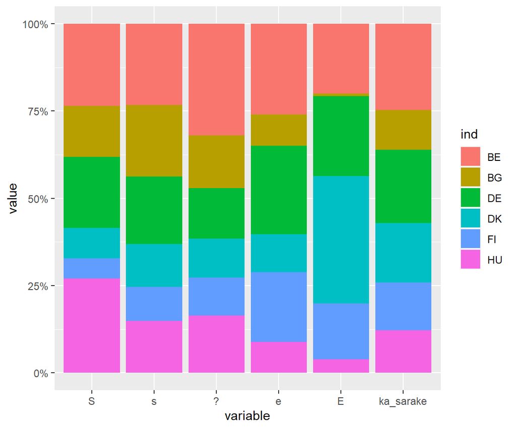

Q1b:Sarakeprofiilit ja keskiarvoprofiili

```r
#mutkikas kuvan piirto - sarakeprofiilit vertailussa
#ggplot vaatii df-rakenteen ja 'long data' - muotoon
##https://stackoverflow.com/questions/9563368/create-stacked-barplot-where-each-stack-is-scaled-to-sum-to
#
# käytetään ca - tuloksia
apu1 <- (simpleCA1$N)
colnames(apu1) <- c("S", "s", "?", "e", "E")
rownames(apu1) <- c("BE", "BG", "DE", "DK", "FI", "HU")
apu1_df <- as.data.frame(apu1)
#lasketan rivien reunajakauma
apu1_df$ka_sarake <- rowSums(apu1_df)
#muokataan 'long data' - muotoon
apu1b_df <- melt(cbind(apu1_df, ind = rownames(apu1_df)), id.vars = c('ind'))

ggplot(apu1b_df, aes(x = variable, y = value, fill = ind)) +
         geom_bar(position = "fill", stat = "identity") +
         scale_y_continuous(labels = percent_format())
```

```r
# apu1_df
# apu1b_df
```

**Edit 28.5.20** Idea: ca havainnollistaa rivien ja sarakkaeiden riippuvuuksia eroina keskiarvosta, yksinkertainen khii2-tulkinta riippumattomuushypoteesina. Rivi-ja sarakeprofiilit standardoidaan (tulkintaa!) PCA-tyyliin (poikkeama keskiarvosta jaetaan hajonnalla, lukumäärädata ja POisson-jakaumassa hajonta=odotusarvo). Rivi- ja sarakeratkaisuiden symmetria ja sidos esitetään tässä.

Sarakekuvassa näkyy E-sarakkeenselvästi ero (DK), muut erot eivät niinkään. S-sarakkeessa HU erottuu, samoin eos(?)-sarakkeessa BE.

**TODO 2.2.20** Voisi harkita taulukoiden (rivi- ja sarakeprosentit) sijoittamista kuvien viereen?

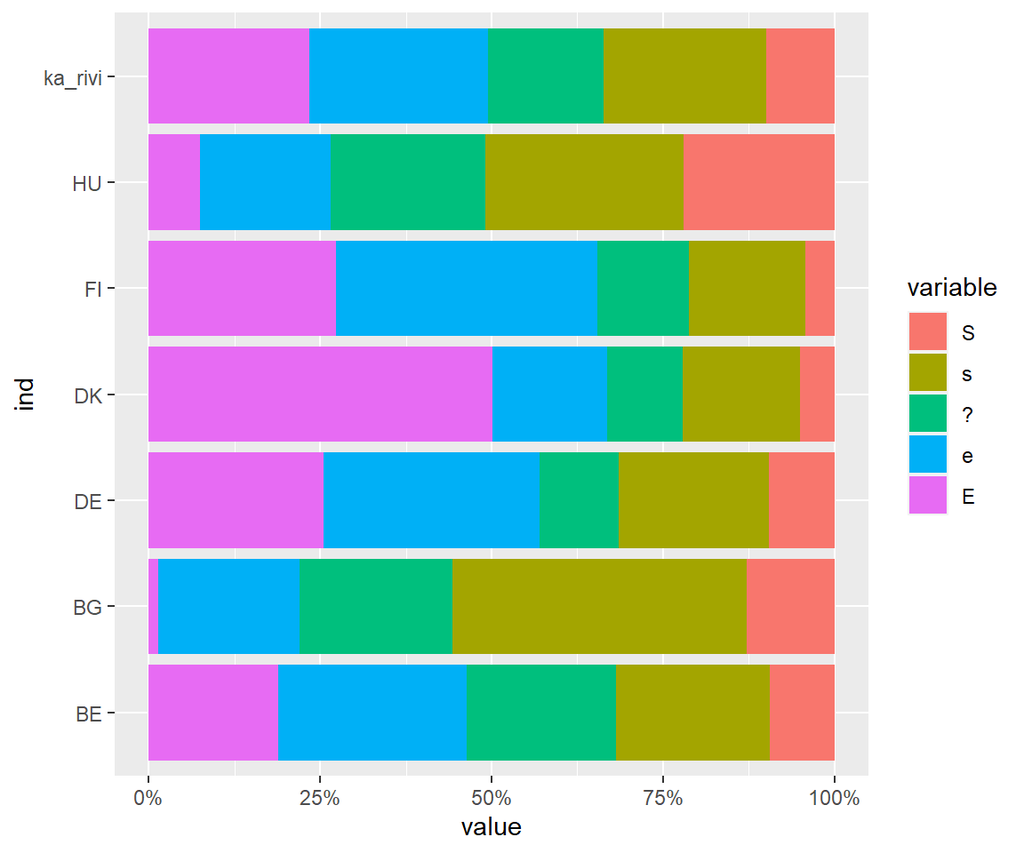

Q1b: riviprofiilit ja keskiarvorivi

```r
# riviprofiilit ja keskiarvorivi -  18.9.2018
apu2_df <- as.data.frame(apu1)
apu2_df <- rbind(apu2_df, ka_rivi = colSums(apu2_df))

#apu2_df
#str(apu2_df)
## typeof(apu2_df) # what is it?
## class(apu2_df) # what is it? (sorry)
## storage.mode(apu2_df) # what is it? (very sorry)
## length(apu2_df) # how long is it? What about two dimensional
## objects?
# attributes(apu2_df)

# temp1 <- cbind(apu2_df, ind = rownames(apu2_df))
# temp1
##muokataan 'long data' - muotoon
apu2b_df <- melt(cbind(apu2_df, ind = rownames(apu2_df)), id.vars = c('ind'))
# str(apu2b_df)
# glimpse(apu2b_df)

#
#ggplot(apu2b_df, aes(x = value, y = ind, fill = variable)) +
#       geom_bar(position = "fill", stat ="identity") +
#       #coord_flip() +
#        scale_x_continuous(labels = percent_format())

#versio2 toimii (18.9.2018)

ggplot(apu2b_df, aes(x = ind, y = value, fill = variable)) +
       geom_bar(position = "fill", stat = "identity") +
       coord_flip() +
        scale_y_continuous(labels = percent_format())
```

**Graafinen analyysi ja R**

Käytänön neuvoja data-analyysiin, kuulunee tekstiin vai meneekö “ohjelmistoympäristö” -liitteeseen? Tärkeä juttu!

Kuvasuhteen saa oikeaksi, kun avaa g-ikkunan (X11()) ja sitten plot. Voi tallentaa pdf-muodossa grafiikkaikkunasta, ja ladata outputiin knitr-vaiheessa. Parempi tulostaa kuvatdsto pdf-ajurilla, jos lopulliseen versioon joutuu näin tekemään (13.5.2018 ). Tämä voi olla järkevä tapa analyysivaiheessa? Teksti kopsattu alla olevasta koodilohkosta.

Ensimmäinen korrespondenssianalyysi - kokeiluja kuvasuhteen säätämiseksi output- dokumentissa. RStudiossa voi avata komentokehoitteessa grafiikka-ikkunan. Siitä käsin tallennettu pdf-kuva on ladattu alla Rmarkdownin omalla komennolla, kohdistus keskelle. Parhaiten näyttäisi toimivan knitrin funktio, mutta oletuskuvakoolla saa ca-kuvasta näköjään aika lähelle oikeanlaisen ilman mitään temppuja.

**zxy** Selventäisikö vielä khii2-etäisyyksien taulukko, tai ehkä seuraavassa luvussa? **#V** MG&Blasius, “vihreän kirja”, johdanto.

CA-ratkaisun (algoritmin) lähtötieto: suhteelliset frekvenssit (korrespondenssimatriisi P) (30.3.20)

```r
taulu5 <- ISSP2012esim1.dat %>% tableX(maa,Q1b,type = "cell_perc")
knitr::kable(taulu5,digits = 2, booktabs = TRUE,
             caption = "Kysymyksen Q1b vastaukset maittain (%)")
```

Kysymyksen Q1b vastaukset maittain (%)

|  | S | s | ? | e | E | Total |
| --- | --- | --- | --- | --- | --- | --- |
| BE | 2.35 | 5.54 | 5.38 | 6.78 | 4.68 | 24.72 |
| BG | 1.45 | 4.85 | 2.52 | 2.33 | 0.16 | 11.31 |
| DE | 2.03 | 4.61 | 2.43 | 6.61 | 5.38 | 21.05 |
| DK | 0.86 | 2.92 | 1.87 | 2.85 | 8.55 | 17.05 |
| FI | 0.58 | 2.31 | 1.83 | 5.19 | 3.72 | 13.63 |
| HU | 2.69 | 3.54 | 2.76 | 2.33 | 0.92 | 12.24 |
| Total | 9.95 | 23.76 | 16.79 | 26.10 | 23.41 | 100.00 |

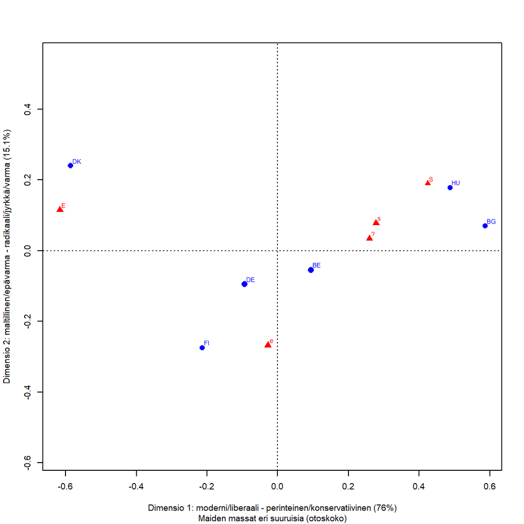

Q1b: lapsi kärsii jos äiti on töissä

```r
#simpleCA1 <- ca(~maa + V6,ISSP2012esim1.dat) suoritetaan ennen värikuvaa, tuloksia tarvitaan
#siinä.

# TODO(11.4.20) fig.cap koodilohkossa tekee kuvasta "kelluvan", ja kuvat numeroidaan.
# Miten plot-komennon kuvaotsikot vaikuttavat?
# Pitäiskö (a) jokaiselle kuvalle oma koodilohko (b) esittää nämä kaksi yhdessä vierekkäin
# Pohditaan kun koodataan capaper-projektia.

# Symmetrinen kartta
# Akselien tekstit "käsityönä" - esimerkki (3.5.2020)

par(cex = 0.6)
plot(simpleCA1, map = "symmetric", mass = c(TRUE,TRUE),
     #main = "Lapsi kärsii jos äiti on töissä -symmetrinen kartta 1",
     xlab = "Dimensio 1: moderni/liberaali - perinteinen/konservatiivinen (76%)",
     ylab = "Dimensio 2: maltillinen/epävarma - radikaali/jyrkkä/varma (15.1%)",
     sub = "Maiden massat eri suuruisia (otoskoko)")
```

```r
# plot(simpleCA2, map = "symmetric", mass = c(TRUE,TRUE),
#     main = "Lapsi kärsii jos äiti on töissä -symmetrinen kartta ",
#     sub = "maa-muuttuja maa2,järjestys as_factor(C_ALPHAN)")
# Kartta kääntyy x-akselin ympäri - esimerkki faktoroinnin arvaamattomista
# seurauksista (30.3.20)

# 13.5.2018
# kuvasuhteen saa oikeaksi, kun avaa g-ikkunan (X11()) ja sitten plot. Voi tallentaa pdf-muodossa
# grafiikkaikkunasta, ja ladata outputiin knitr-vaiheessa. Parempi tulostaa kuvatdsto pdf-ajurilla,
# jos lopulliseen versioon joutuu
# näin tekemään.
```

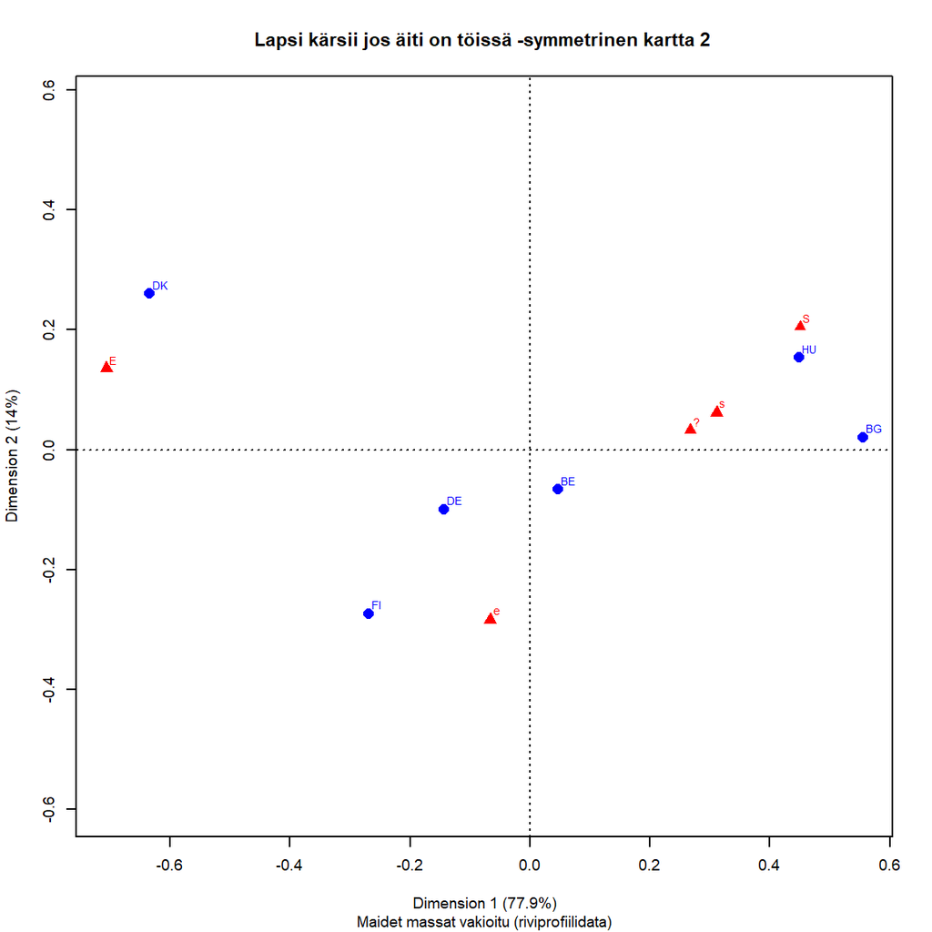

Q1b: lapsi kärsii jos äiti on töissä

```r
# Sama kartta - maiden massat vakiotu
# CA:n lähtötietona riviprofiilit

par(cex = 0.6)
plot(simpleCA3, map = "symmetric", mass = c(TRUE,TRUE),
main = "Lapsi kärsii jos äiti on töissä -symmetrinen kartta 2 ",
sub = "Maidet massat vakioitu (riviprofiilidata)")
```

Näitä karttoja vertaillaan seuraavassa luvussa tarkemmin.

Toinen tapa - kuvatiedoston lataaminen include_graphics - funktiolla. Pitää miettiä mikä on järkevää, dataa tutkaillessa piirretään useita kuvia. PDF-muodossa ne ovat skaalautuvia, kommentteja voi lisätä jne.

**Rivien (1) ja sarakkeiden (2) khii2-etäisyydet keskiarvosta.**

Rivimassat skaalautuvat ca-ratkaisussa vakioksi 1/6 (0.167), kun lähtötietona on riviprofiilien taulukko jossa rivimassat ovat 1. Sarakemassat skaalautuvat uudelleen. Massojen summa on 1. **TODO 16.9.20** knittr::kabble nimeää taulukot koodilohkon nimen mukaan, siis vain yksi taulukko? Omiksi koodilohkoiksi?

```r
# khii2 - etäisyyksien taulukko
#str(simpleCA1)
#simpleCA1$rowdist
#str(simpleCA1$rowdist)

# verrataan "tavallisen" ca:n ja riviprofiili-ca:n khii2-etäisyyksiä origosta
# 5.9.2020

# khii2 - etäisyydet origosta

# simpleCA1$rownames
# simpleCA1$rowdist
# simpleCA3$rowdist

# simpleCA3$colnames
# simpleCA1$coldist
# simpleCA3$coldist

# massat - huom! Riviprofiilien ca: rivimassojen summa on 1 !(5.9.20)
# sum(simpleCA1$rowmass)
# sum(simpleCA3$rowmass)
# rivit

# simpleCA1$rownames
# simpleCA1$rowmass
 simpleCA3$rowmass
```

```
## [1] 0.1666667 0.1666667 0.1666667 0.1666667 0.1666667 0.1666667
```

```r
# sum(simpleCA1$rowmass)
# sum(simpleCA3$rowmass)

# sarakkeet

# simpleCA3$colnames
# simpleCA1$colmass
# simpleCA3$colmass
# sum(simpleCA1$colmass)
# sum(simpleCA3$colmass)

# rivien khii2 - etäisyydet, massat ja vakioidut massat
rowdist.tbl <- as_tibble(rbind(simpleCA1$rowdist, simpleCA3$rowdist),.name_repair = c("unique"))
```

```
## * `` -> ...1
## * `` -> ...2
## * `` -> ...3
## * `` -> ...4
## * `` -> ...5
## * ...
```

```r
str(rowdist.tbl)
```

```
## tibble [2 x 6] (S3: tbl_df/tbl/data.frame)
##  $ ...1: num [1:2] 0.158 0.147
##  $ ...2: num [1:2] 0.631 0.59
##  $ ...3: num [1:2] 0.175 0.206
##  $ ...4: num [1:2] 0.634 0.689
##  $ ...5: num [1:2] 0.348 0.384
##  $ ...6: num [1:2] 0.55 0.508
```

```r
colnames(rowdist.tbl) <- simpleCA1$rownames

# rownames(rowdist.tbl) <- c("perus-CA", "rivimassat vakioitu") ei toimi, ei sovi
# tibbleen (17.9.20). Ei tarvita.

knitr::kable(rowdist.tbl,digits = 3,
             caption = "Rivietäisyydet keskiarvosta (khii2) - toisella rivilla rivimassat yhtä suuret",
             booktabs = TRUE)
```

Rivietäisyydet keskiarvosta (khii2) - toisella rivilla rivimassat yhtä suuret

| BE | BG | DE | DK | FI | HU |
| --- | --- | --- | --- | --- | --- |
| 0.158 | 0.631 | 0.175 | 0.634 | 0.348 | 0.550 |
| 0.147 | 0.590 | 0.206 | 0.689 | 0.384 | 0.508 |

```r
# rowdist.tbl ok 15.9.20

# sarakkeiden khii2 - etäisyydet, massat ja vakioidut massat

coldist.tbl <- as_tibble(rbind(simpleCA1$coldist, simpleCA3$coldist),.name_repair = c("unique"))
```

```
## * `` -> ...1
## * `` -> ...2
## * `` -> ...3
## * `` -> ...4
## * `` -> ...5
```

```r
# coldist.tbl
colnames(coldist.tbl) <- simpleCA1$colnames
rowid_to_column(coldist.tbl)
```

| rowid | S | s | ? | e | E |
| --- | --- | --- | --- | --- | --- |
| 1 | 0.5246525 | 0.3248840 | 0.3078230 | 0.2721699 | 0.6271108 |
| 2 | 0.5587368 | 0.3567818 | 0.3025459 | 0.2944703 | 0.7190317 |

```r
# print(coldist.tbl)

knitr::kable(coldist.tbl,digits = 3, booktabs = TRUE,
             caption = "Sarake-etäisyydet keskiarvosta (khii2) - toisella rivilla rivimassat yhtä suuret")
```

Sarake-etäisyydet keskiarvosta (khii2) - toisella rivilla rivimassat yhtä suuret

| S | s | ? | e | E |
| --- | --- | --- | --- | --- |
| 0.525 | 0.325 | 0.308 | 0.272 | 0.627 |
| 0.559 | 0.357 | 0.303 | 0.294 | 0.719 |

```r
colmass.tbl <- as_tibble(rbind(simpleCA1$coldist, simpleCA3$coldist),.name_repair = c("unique"))
```

```
## * `` -> ...1
## * `` -> ...2
## * `` -> ...3
## * `` -> ...4
## * `` -> ...5
```

```r
colnames(colmass.tbl) <- simpleCA1$colnames
rowid_to_column(colmass.tbl)
```

| rowid | S | s | ? | e | E |
| --- | --- | --- | --- | --- | --- |
| 1 | 0.5246525 | 0.3248840 | 0.3078230 | 0.2721699 | 0.6271108 |
| 2 | 0.5587368 | 0.3567818 | 0.3025459 | 0.2944703 | 0.7190317 |

```r
knitr::kable(colmass.tbl,digits = 3, booktabs = TRUE,
             caption = "Sarakkeiden massat - toisella rivilla rivimassat yhtä suuret")
```

[output not shown]

Rivi- ja sarake-etäisyydet (khii2) keskiarvosta rivien massoilla ja vakioiduilla massoilla . Massoiltaan (havaintojen lukumäärä tai jotain siihen verrannollista) pienet rivit HU ja BG ovat vakiomassojen ratkaisussa lähempänä keskiarvoa. Niin on myös Belgia. Saksa, Tanska ja Suomi ovat kauempan origosta. **Erot kuitenkin pieniä (17.9.20)**

```r
# Tarpeeton - ja ei toimi (3.10.20). Kuva olis kiva, kuitenkin.

# colmass_b.tbl
# str(colmass.tbl)
# plot(colmass.tbl$rowid[1],colmass.tbl$rowid[1])
# hist(colmass.tbl[, 1:5])
```

Grafiikan hienosäätö on hieman haastavaa: analyysivaiheessa kannattaa tallentaa kuvia RStudion grafiikkaikkunasta pdf-muodossa talteen, graafisessa data-analyysissä niitä tietenkin syntyy aika paljon. HTML- ja pdf- formaatin kuvat viimeistellään bookdown-ympäristössä.

## 2.2 Korrespondenssianalyysin käsitteet

**edit 15.9.20** Näitä taulukoitu edellä, vertailtu “normaaleilla massoilla” ja vakioiduilla rivimassoilla (riviprofiileilla) laskettuja ca-ratkaisuja, khii2-etäisyyksiä ja sarakemassojen skaalautumista kun rivimassat vakioidaan.

1. Profiilit
2. Massat
3. Profiilien etäisyydet (khii2): (a) saman pistejoukon pisteiden (b) eri pistejoukkon pisteiden

**zxy** Ja tätä “triplettiä” täydentää neljä siitä johdettua käsitettä, viite muistiinpanoissa. **#V** Tässäkin CAiP ja MG2017HY-luentokalvot.

# 3 Tulkinnan perusteita

Luvussa syvennetään esimerkin tulkinnan perusteita. Miksi symmetrinen kartta on yleensä paras vaihtoehto, siksi se oletusarvoisesti esitetäänkin. Milloin voi käyttää vaihtoehtoisia esitystapoja? **Ydinluku**.

Esimerkkiaineistossa tulee jo pohdittavaa, Guttman (arc, horseshoe) - efekti, ratkaisun dimensiot jne.

Asymmetrinen kartta, jossa riviprofiilit ovat pääkomponentti-koordinaateissa ja sarakeprofiilit standardikoordinaateissa.

1. Sarakkeet ideaalipisteinä, edustavat kuvittellisia maita joissa kaikki ovat vastanneet vain yhdellä tavalla.
2. Sarakepisteet kaukana origosta, koska skaalattu
3. Rivipisteet kasautuneet keskiarvopisteen ympärille
4. Rivi-ja sarakepisteiden suhteelliset sijannit samat kuin symmetrisessä kuvassa
5. Tässäkin kuvassa pisteen koko kuvaa sen massaa. Sarakkeista “täysin samaa mieltä” (ts) ja “ei samaa eikä eri mieltä” ovat massoiltaan pienimmät.
6. Pisteiden koko kuvaa rivin tai sarakkeen massaa.

Tarinaa voi tarvittaessa jatkaa, tämä on CA:n hankalin asia. Kaksi koordinaatistoa, ja niiden yhteys.

7. Asymmetrinen kuva ja akseleiden / dimensioiden tulkinta

Piirretään sama asymmetrinen kartta uudelleen, mutta yhdistetään sarakepisteet keskiarvopisteeseen (sentroidiin) suorilla. Mitä terävämpi on sarakesuoran (vektorin?) ja akselin kulma, sitä enemmän sarake määrittää tätä ulottuvuutta. Jos vektori on lähettä 45 asteen kulmaa, sarake määrittää yhtä paljon molempia ulottuvuuksia.

Standardikooridaateissa esitety sarakepisteet ovat fiktiivisiä “maapisteitä”, joissa kaikki vastaukset ovat yhdessä luokittelumuuttujan arvossa.Alkuperäisessä täydessä avaruudessa ne ovat simpleksin kärkipisteet, simpleksin sisällä ovat riviprofiilit.

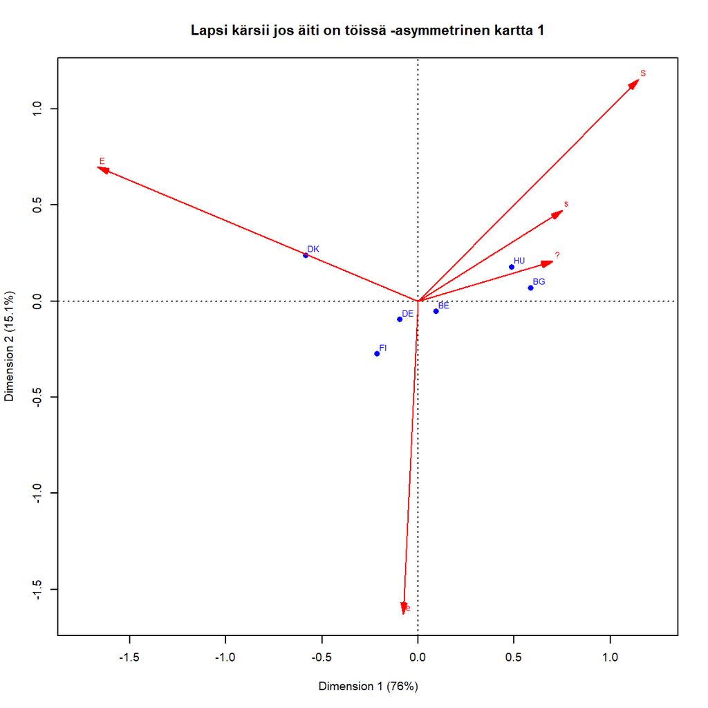

Q1b: lapsi kärsii jos äiti on töissä

```r
# asymmetrinen kartta - rivit pc ja sarakkeet sc
# sarakkeet vektorikuvina
# HUOM! simpleCA1 luodaan G1_2_johdesim.Rmd - tiedostossa
#
# Kuva tiedostoon - ennen plot-komentoa avataan tiedosto
# pdf("img/sCA1asymm1.pdf")
par(cex = 0.6)
plot(simpleCA1, map = "rowprincipal",
     arrows = c(FALSE,TRUE),
     main = "Lapsi kärsii jos äiti on töissä -asymmetrinen kartta 1" )
```

```r
# Kuva tiedostoon - suljetaan
# dev.off()
```

Sarakkeen “Eri mieltä” (e) määrittää toisen ulottuvuuden, jonka voisi tulkita erottelevan “maltilliset” mielipiteen tiukemmista. Sarake “täysin samaa mieltä” (S) määrittää toista ulottuvuutta lähes yhtä paljon kuin ensimmäistä, mutta “täysin eri mieltä” (E) on vasemmalla ja kolme vastausvaihtoehtoa oikealla. Kovin terävästi dimensiot eivät eroa toisistaan?

Asymmetrinen kartta - rivipisteet (profiilit) sarakepisteiden standardikoordinaattien keskiarvopisteinä (ns. barysentrinen keskiarvo).

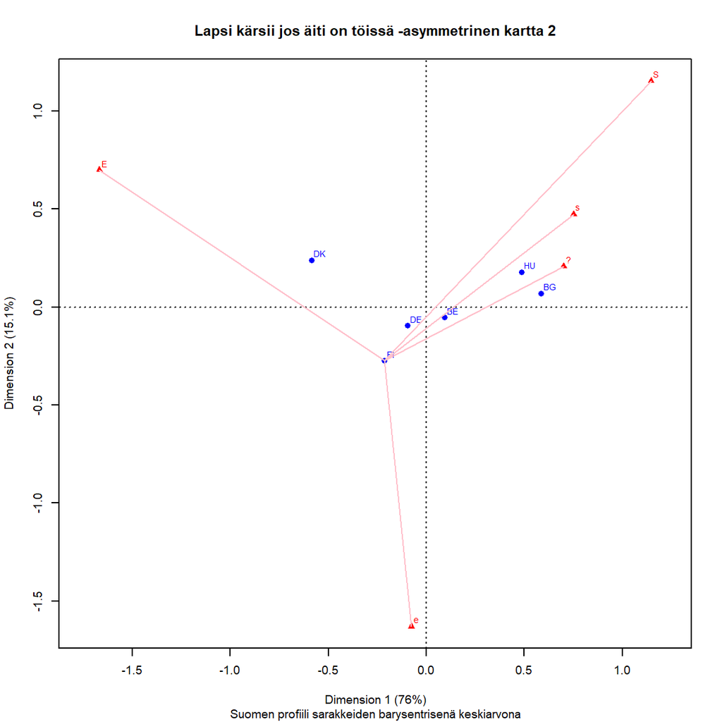

Q1b: lapsi kärsii jos äiti on töissä

```r
# Barysentrisen keskiarvon  "viivakuviota" kehitelty CA_calc1.R - skriptissä
# simpleCA1-objektista saa std-koordinaatit, muunnoksella rivien pääkoordinaatit
# rpc.

# Jos plot-komennotoon "MapObj1 <- ", saadaan pisteiden koordinaatit
# plot-funktiolla ensin "raamit" ja pisteet talteen, sitten pisteet Suomen
# pisteestä lines(x,y) sarakevektoreihin? (29.5.20)


# asymmetrinen kartta - rivit pc ja sarakkeet sc
# sarakkeet vektorikuvina
# HUOM! simpleCA1 luodaan G1_2_johdesim.Rmd - tiedostossa

# Kuva tiedostoon - ennen plot-komentoa avataan tiedosto
# pdf("img/sCA1asymm1.pdf")

# Piirretään Suomen riviprofiilista janat sarakepisteisiin - barysentinen keskiarvo
# Rivipisteet pääkoordinaatteina (principal coordinates)

simpleCA1.rpc <- simpleCA1$rowcoord %*% diag(simpleCA1$sv)

# ei toimi - onpa hankalaa! segments antaa virheilmoituksen "plot.new has not
# been called yet" (11.6.20)
# X11()
par(cex = 0.6)
plot(simpleCA1, map = "rowprincipal",
     arrows = c(FALSE,FALSE),
     main = "Lapsi kärsii jos äiti on töissä -asymmetrinen kartta 2",
     sub = "Suomen profiili sarakkeiden barysentrisenä keskiarvona")
     segments(simpleCA1.rpc[5,1],simpleCA1.rpc[5,2],simpleCA1$colcoord[, 1],
         simpleCA1$colcoord[, 2], col = "pink")
```

```r
# Kuva tiedostoon - suljetaan
# dev.off()
```

**Edit 3.5.20** Selvennä: sarakevektroit ovat standardikoordinaateissa, ideaalipisteitä (“maa jossa kaikki samaa mieltä”). Miksi ne ovat kartalla “reilusti” ykköstä suurempia? Vastaus: ideaalipisteet esitetään rivipisteiden koordinaatistossa - > skaalaus.

**Edit 11.6.20 - tulkinta ja data?TARKISTA** Origo on koko aineiston barysentrinen keskipiste. Janan pituus on kääntäen verrannollinen sarakkeen (“ideaalipisteen”) suhteelliseen osuuteen. Maapiste (profiilipiste) on saravektoreiden barysentrinen keskiarvo, ja etäisyydet kertovat kyseisen sarakkeen suhteellisen osuuden maaprofiliisissa.(? 11.6.20). " In an asymmetric map where the rows, for example, are in principal co- ordinates (i.e. the row analysis), distances between displayed row points are approximate khii2-distances between row profiles; and distances from the row profile points to a column vertex point are, as a general rule, inversely related to the row profile elements for that column." CAiP, s. 72., tarkemmin s.62-. Pisteiden väliset etäisyydet voidaan optimaalisessa tilanteessa (symm. kuva sama pistejoukko, asymm. kuva myös sarake- ja rivipisteet) tulkita vain approksimaatioina.

Verifying the profile-vertex interpretation (emt., s 68): Each row profile point (staff group) is at a weighted average position of the column vertex points (smoking categories), where the weights are the elements of the respective row profile. As a general rule, assuming that the display is of good quality, which is true in this case, the closer a profile is to that vertex, the higher its profie value is for that category.

Verifiointi verteksi kerrallaan, kaikki on suhteellista! Suomi on kaikkein lähimpänä e-verteksiä. Niinpä Suomen profiilissa e-vastausten suhteellinen osuus on suurempi kuin muilla mailla. Tanska vastaavasti lähimpänä E-verteksiä. Projisoidaan rivipisteet sarakevektoreille -> järjestys.

Perusidea: kartta antaa yleiskuvan riippuvuudesta, approksimaation tarkkuuden ja laadun rajoissa. Yksityiskohtien etsiskely ei ole oleellista, väärien johtopäätösten välttäminen on. Erityisesti symmetrisessä kartassa ei voi tulkita mitenkään (tiukasti ottaen) eri pistejoukkojen etäisyyksiä. Ei voi tunnistaa klustereita!

**edit 14.8.20** Barysentrinen koordinaatisto on ideaalipisteiden simpleksin kärkipisteiden koordinaatisto.

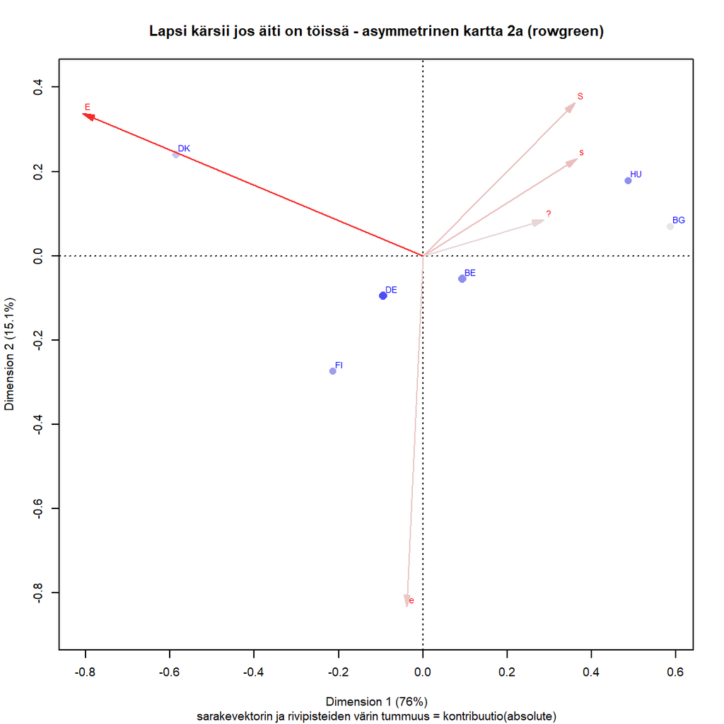

Q1b: lapsi kärsii jos äiti on töissä

```r
# X11() komentoriville ja plot-komento -> grafiikkaikkuna
par(cex = 0.6)
plot(simpleCA1, map = "rowgreen",
     contrib = c("absolute", "absolute"),
     mass = c(TRUE,TRUE),
     arrows = c(FALSE, TRUE),
     main = "Lapsi kärsii jos äiti on töissä - asymmetrinen kartta 2a (rowgreen)",
     sub = "sarakevektorin ja rivipisteiden värin tummuus = kontribuutio(absolute)")
```

Greenacre (2006, “loose ends -artikkeli”) ehdotti asymmetrisessä kuvassa standardikoordinaattien skaalaamista niin, että ne kerrotaan massan neliöjuurella. Tämä skaalaus toimii hyvin pienen ja suuren inertian tapauksessa. Kartoissa pätee sama sääntö kuin muussakin graafisessa data-analyyisissä, kuvien on esitettävä oleelliset yhteydet, mutta mielellään vain ne.

Sama kuva, kontribuutiot “relative”. **edit 24.2.20** Ero selitettävä!

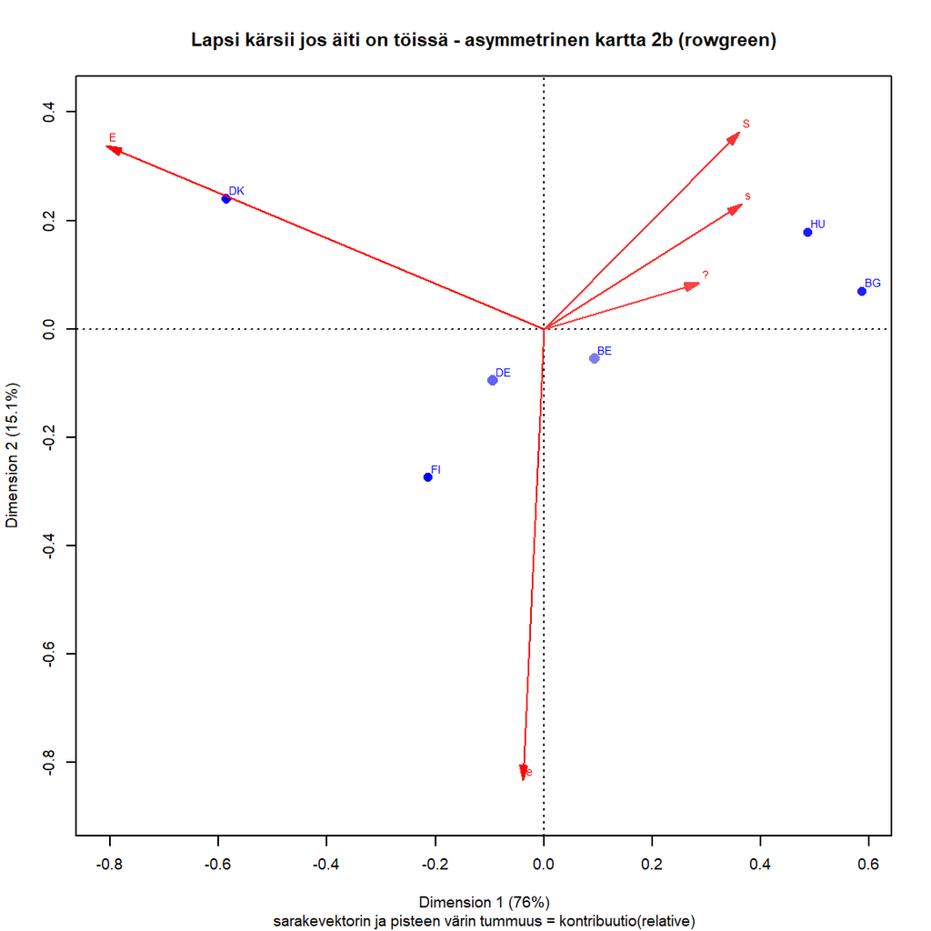

Q1b: lapsi kärsii jos äiti on töissä

```r
#X11() komentoriville ja plot-komento
par(cex = 0.6)
plot(simpleCA1, map = "rowgreen",
     contrib = c("relative", "relative"),
     mass = c(TRUE,TRUE),
     arrows = c(FALSE, TRUE),
     main = "Lapsi kärsii jos äiti on töissä - asymmetrinen kartta 2b (rowgreen)",
     sub = "sarakevektorin ja pisteen värin tummuus = kontribuutio(relative)")
```

Asymmetrisessä kartassa 2 pisteiden koko on suhteessa niiden massaan, ja värisävy absoluuttiseen tai suhteelliseen kontribuutioon.

Sarakevektorin kulma akseliin - mitä pienempi sitä enemmän määrittää. Jos lähellä 45 asteen lävistäjää, kontribuutiota on molempiin akseleihin

**Tulkinta: rivipisteiden ortogonaalinen projektio “sarakevektorille”**

**Onko näin? (17.9.20)** Toisessa kuvassa sama E-vektorille. Maiden suhteellinen järjestys on oikea, mutta tarkasti etäisyydet eivät (välimatka-asteikolla) ole vertailukelpoisia.

Vertailun vuoksi riviprofiilien sarakkeita vastavat arvot suuruusjärjestyksessä:

e: FI 38, DE 31, BE 27, BG 21, HU 19, DK 17 (%-yksikköä)

**todo 15.9.20** Voiko tämän tehdä myös skaalatulle (rowgreen) asymmetriselle kuvalle?

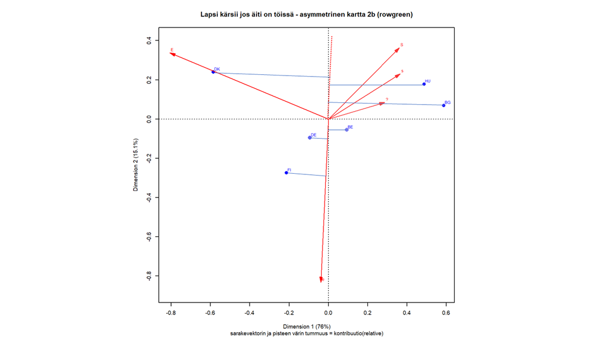

```r
knitr::include_graphics('img/simpleCAasymmTulk1.png')
```

E: DK 50, FI 27, DE 26, BE 19, HU 8, BG 1 (%-yksiköä)

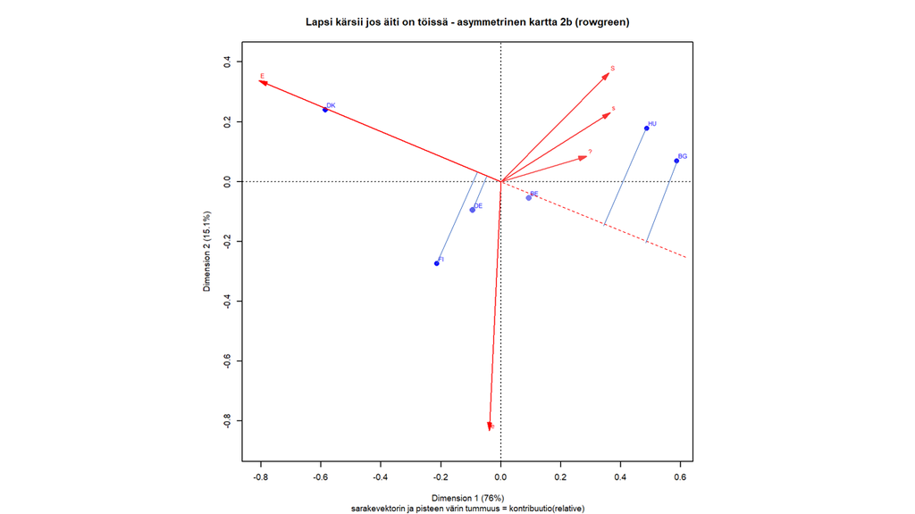

```r
knitr::include_graphics('img/simpleCAasymmTulk2.png')
```

Numeeriset tulokset, jälkimmäisessä rivimassat vakioitu yhtä suuriksi (“riviprofiilitaulukon ca”).

```r
# CA:n numeeriset tulokset
# (11.4.20) yhdistä koodilohkoon khii2dist1 (G1_2_johdesim.Rmd, r. 665)
# CA:n numeeristen tulosten käsittelyä myös CAcalc_1.R -skriptissä.

summary(simpleCA1)
```

```
##
## Principal inertias (eigenvalues):
##
##  dim    value      %   cum%   scree plot
##  1      0.136619  76.0  76.0  *******************
##  2      0.027089  15.1  91.1  ****
##  3      0.010054   5.6  96.7  *
##  4      0.005988   3.3 100.0  *
##         -------- -----
##  Total: 0.179751 100.0
##
##
## Rows:
##     name   mass  qlt  inr    k=1 cor ctr    k=2 cor ctr
## 1 |   BE |  247  465   34 |   93 347  16 |  -54 118  27 |
## 2 |   BG |  113  874  251 |  586 862 284 |   70  12  21 |
## 3 |   DE |  210  584   36 |  -94 291  14 |  -95 293  70 |
## 4 |   DK |  170  996  381 | -586 853 428 |  240 143 362 |
## 5 |   FI |  136 1000   92 | -214 380  46 | -274 620 377 |
## 6 |   HU |  122  889  206 |  487 783 213 |  179 105 144 |
##
## Columns:
##     name   mass  qlt  inr    k=1 cor ctr    k=2 cor ctr
## 1 |    S |   99  784  152 |  424 653 131 |  190 131 132 |
## 2 |    s |  238  788  140 |  278 731 134 |   78  57  53 |
## 3 |      |  168  720   88 |  259 707  82 |   34  12   7 |
## 4 |    e |  261  982  108 |  -28  11   2 | -268 971 693 |
## 5 |    E |  234 1000  512 | -616 966 651 |  115  34 114 |
```

```r
# vertailun vuoksi numeeriset tulokset, kun maiden massat vakiot
summary(simpleCA3)
```

```
##
## Principal inertias (eigenvalues):
##
##  dim    value      %   cum%   scree plot
##  1      0.167678  77.9  77.9  *******************
##  2      0.030095  14.0  91.9  ***
##  3      0.013206   6.1  98.0  **
##  4      0.004296   2.0 100.0
##         -------- -----
##  Total: 0.215275 100.0
##
##
## Rows:
##     name   mass  qlt  inr    k=1 cor ctr    k=2 cor ctr
## 1 |   BE |  167  295   17 |   46  97   2 |  -66 199  24 |
## 2 |   BG |  167  884  270 |  554 882 306 |   22   1   3 |
## 3 |   DE |  167  718   33 | -144 489  21 |  -98 229  54 |
## 4 |   DK |  167  993  367 | -635 849 400 |  261 144 377 |
## 5 |   FI |  167  999  114 | -270 494  72 | -272 505 411 |
## 6 |   HU |  167  870  200 |  448 778 199 |  154  92 132 |
##
## Columns:
##     name   mass  qlt  inr    k=1 cor ctr    k=2 cor ctr
## 1 |    S |  105  785  153 |  450 649 127 |  206 135 148 |
## 2 |    s |  250  792  148 |  311 762 145 |   62  30  32 |
## 3 |      |  171  792   73 |  267 780  73 |   33  12   6 |
## 4 |    e |  256  976  103 |  -66  51   7 | -283 925 681 |
## 5 |    E |  218 1000  524 | -706 964 649 |  136  36 133 |
```

```r
# Rivi- ja sarake-etäisyydet (keskiarvosta/sentroidista)
# HUOM! Edellisessä jaksossa taulukko rivi- ja sarake-etäisyyksistä. Tuskin
# kannattaa tässä toistaa. Muuta analyysiä numeerisista tuloksista. (10.4.20)

# simpleCA1$rownames
# simpleCA1$rowdist
# simpleCA3$rowdist

# simpleCA1$colnames
# simpleCA1$coldist
# simpleCA3$coldist
```

Edellisessä jaksossa esimerkki siistimmästä taulukosta.

**TODO** (21.2.20)

1. Tätä voisi käyttää esimerkkinä numeeristen tulosten vertailussa?
2. Kokonaisinertia kasvaa (0,18 -> 0,22), koordinaatisto muuttuu mutta ei kovin radikaalisti.
3. Kvaliteetti, kontribuutiot? Miten vertailla oleellisia asioita?

Belgian laatu putoavat merkittävästi,ja kontribuutiot pienenevät entisestään.

Saksan laatu paranee aika paljon, ja kontribuutiotkin jonkin verran. Aika outoa,että suurimman massan maiden (DE,BE lähes puolet datasta) kontribuutiot ovat niin pieniä (24.2.20)

4. Sarakemassojen muutos: sarakkeiden ja rivien yhteys. Kaavaliitteessä eksplisiittisesti rivi- ja sarakeratkaisujen yhteys, massat mukana.

**zxy** Taulukon käsitteiden läpikäynti ja pureskelu kuulunee seuraavaan lukuun?

MG & Blasius, “vihreä kirja” ja monta muuta lähdettä: kontribuutiot inertiaan

# 4 Yksinkertaisen korrespondenssianalyysin laajennuksia 1

Korrespondenssianalyysi sallii rivien tai sarakkeiden yhdistelyn tai “jakamisen”. Tämä onnistuu esimerkkiaineistossa lisäämällä rivejä eli jakamalla eri maiden vastausksia useampaan ryhmään. Kartalle voidaan myös lisätä apumuuttujia tai täydentäviä muuttujia (supplementary points). Ne eivät vaikuta ca:n tuloksiin, vaan esittävät lisäinformaatiota.

**edit 9.9.20 - vähän vanhentunuttta**Sen avulla voi myös tarkastella ja vertailla erilaisia ryhmien välisiä tai ryhmien sisäisiä (within groups - between groups) eroja hieman. Teknisesti yksinkertaista korrespondenssianalyysiä sovelletaan muokattuun matriisiin. Datamatriisi rakennetaan useammasta alimatriisista, joko “pinoamalla” osamatriiseja (stacked matrices) tai muodostamalla symmetrinen lohkomatriisi (ABBA).

**edit 9.9.20 Uusi johdanto** 1. Saksan ja Belgian jako

- jakaumaekvivalenssi(?) (distributional equivalence)), voidaan jakaa ja yhdistää rivejä
- Belgia leviää pystysuuntaan, Saksa vaakasuuntaan

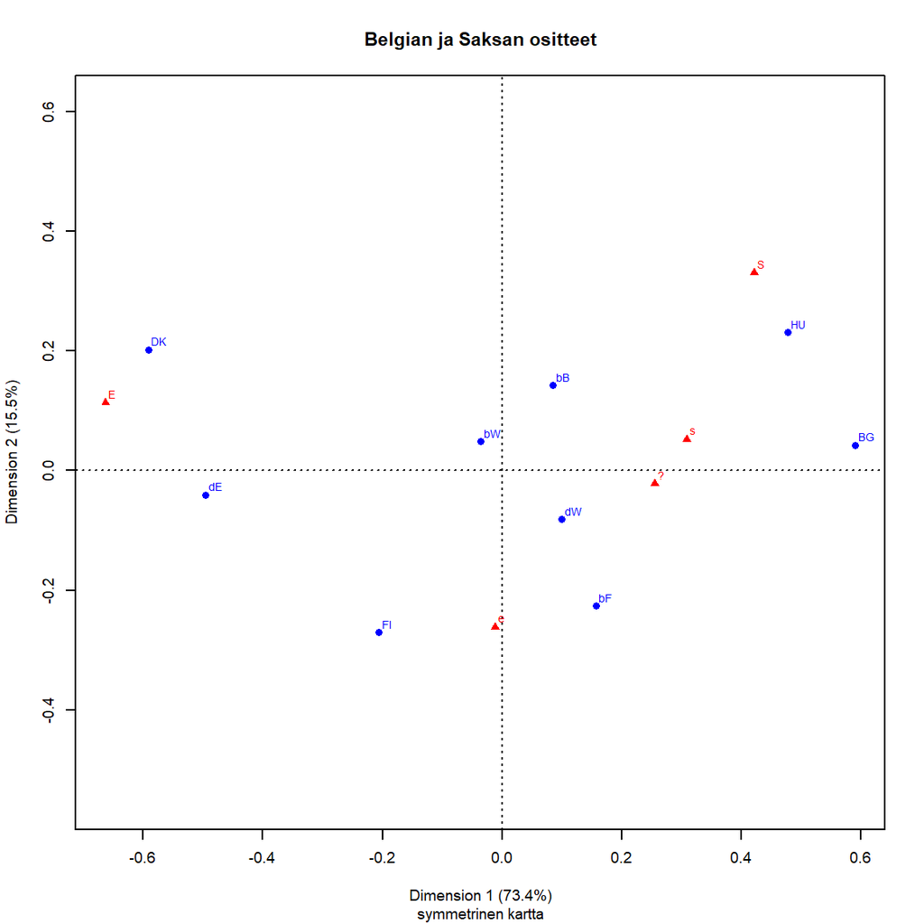

Belgian ja Saksan aluejako

```r
# HUOM! Tässä ei vielä supp.points mukana!
par(cex = 0.6)
suppointCA1 <- ca(~maa3 + Q1b,ISSP2012esim1.dat)
plot(suppointCA1, main = "Belgian ja Saksan ositteet",
                sub = "symmetrinen kartta")
```

2. Täydentävät pistee (supplementary points)
- eivät vaikuta karttaan (koordinaatistoon, rivi- tai sarakepisteiden sijaintiin)
- useita tapoja käyttää, tässä Saksan ja Belgian maapisteet
- barysentrinen keskiarvo
3. Lisämuuttujat - yksinkertainen ca useamman muuttujan analyysissä

3.1 Yksinkeraisin malli: vuorovaikutusmuuttuja (interactive coding) - yksi rivi (sample) jaetaan useammaksi, sama idea kuin edellisessä esimerkissä - käytännön raja yleensä kolmen muuttujan vuorovaikutusmuuttuja, esimerkkinä maan, iän ja sukupuolen yhdistetty muuttuja

3.2 Kartta on data-analyysin väline - miten sitä voi selkeyttää?

Hyvässä kartassa on vain tarpeellinen määrä informaatiota, epäselvä tukkoinen kuva ei toimi. Yksinkertainen keino analyysivaiheessa on “leikata ja liimata” kuvia ja tallentaa ne pdf-muodossa. Voi tehdä muistiinpanoja, lisätä kommentteja jne.

Tässä esitellään kaksi muuta: kuva-alan rajaaminen BaseR-grafiikan plot-funktion parametreilla ja paljon yleispätevämpi osajoukon korrespondenssianalyysi. Jälkimmäisessä valitaan joku osajoukko aineistosta, ja tehdään sille korrespondenssianalyysi siten, että reunajakaumat (massat) ja valitun datan profiilit pidetään vakioina. Paljon parempi idea kuin suoraviivainen aineiston rajaaminen.

Nyt käytetään johdattelevan esimerkin dataa, johon muunnokset on jo alustavasti tehty.

**(14.9.20)**G1_4_CAlaaj1.Rmd jaettu kolmeksi tiedostoksi, uusia G1_4_CAlaaj2.Rmd ja G1_4_CAlaaj3.Rmd

**Vanhaa koodia kolme koodilohkoa**

## 4.1 Täydentävät muuttujat (supplementary points)

**zxy** Piste sinne piirretään, mutta muuttujassa on se tieto. “Täydentävä piste” kuulostaa huonolta. Lisämuuttujat, havainnot, lisäpisteet?

**Viite:CAip ss 89, HY2017_MCA.**

Aineistossa on havaintoja (rivejä) tai muuttujia (sarakkeita), joista voi olla hyötyä tulosten tulkinnassa. Nämä lisäpisteet voidaan sijoittaa kartalle, jos niitä voidaan jotenkin järkevästi vertailla kartan luomisessa käytettyihin profiileihin (riveihin ja sarakkeisiin).

**EDIT** Lisätään Belgian ja Saksan aluejako täydentäviksi riveiksi. Sopii tarinaan, dimensioiden tulkinta ei ollut esimerkissä kovin kirkas. Viite CAip:n lukuun, jossa vain todetaan että maita ei ole järkevää painottaa (massa) otoskoolla, vaan vakioidaan (jotenkin) sama (suhteellinen) massa kaikille. Samalla oikaistaan myös naisten yliedustus aineistossa.

**Käsitteitä:** (a) Active point, aktiivinen piste (aktiivinen havainto tai muuttuja).

2. Supplementary pointtäydentävä piste (täydentävä havainto).

Täydentävien muuttujien kolme käyttötapaa:

1. Sisällöllisesti tutkimusongelman kannalta poikkeava tai erilainen rivi tai sarake
2. Outlayerit, poikkeava havainto jolla pieni massa (esimerkissä uusi sarakemuuttuja, jossa kovin vähän havaintoja)
3. osaryhmät **EDIT** capaper- jäsentelyssä ja bookdown-dokumentissa selitetetty täydentävät/lisäpisteet tarkemmin (18.9.2018).

```r
# Kömpelöä koodia, harjoitellaan taulukoiden yhdistelyä (CAtest1.Rmd)
# Belgian ja Sakasan jako lisäpisteinä 24.5.2018
# Data suppointCA1


# Miten lisärivit? (24.5.2018)
# Luetaan data tauluksi - ei toimi, char-table.Toimisiko nyt, ei chr? (4.2.20)
# yritetään uudestaan table-funktiolla

# data maa3-muuttujassa
# str(ISSP2012esim1.dat$maa3)
# attributes(ISSP2012esim1.dat$maa3)

suppoint1_df1 <- select(ISSP2012esim1.dat, maa3,Q1b)

#  tarkistuksiin jos koodi suoritetaan rivi kerrallaan
# str(suppoint1_tab1)

suppoint1_tab1 <- table(suppoint1_df1$maa3, suppoint1_df1$Q1b)
suppoint1_tab1
```

| / | S | s | ? | e | E |
| --- | --- | --- | --- | --- | --- |
| bF | 51 | 241 | 262 | 312 | 146 |
| bW | 53 | 103 | 91 | 118 | 125 |
| bB | 87 | 107 | 85 | 122 | 110 |
| BG | 118 | 395 | 205 | 190 | 13 |
| dW | 133 | 313 | 138 | 375 | 208 |
| dE | 32 | 62 | 60 | 163 | 230 |
| DK | 70 | 238 | 152 | 232 | 696 |
| FI | 47 | 188 | 149 | 423 | 303 |
| HU | 219 | 288 | 225 | 190 | 75 |

```r
#plot(ca(~maa2 + V6, suppoint1_df1)) #toimii
#
# Saksan ja Belgian summarivit
#
suppoint2_df <- filter(ISSP2012esim1.dat, (maa == "BE" | maa == "DE"))
suppoint2_df <- select(suppoint2_df, maa, Q1b)
#head(suppoint2_df)
#tail(suppoint2_df)
str(suppoint2_df)
```

```
## tibble [3,727 x 2] (S3: tbl_df/tbl/data.frame)
##  $ maa: Factor w/ 6 levels "BE","BG","DE",..: 1 1 1 1 1 1 1 1 1 1 ...
##   ..- attr(*, "label")= chr "Country Prefix ISO 3166 Code - alphanumeric"
##  $ Q1b: Factor w/ 5 levels "S","s","?","e",..: 4 5 1 4 2 2 2 2 1 1 ...
##   ..- attr(*, "label")= chr "Q1b Working mom: Preschool child is likely to suffer"
##  - attr(*, "notes")= chr [1:45] "document Plan File: /Users/marcic/Desktop/old/GPS2011 sampling/ISSP2013.sampling" "         .csplan" "         Weight Variable: SampleWeight_Final_" "         Stage 1" ...
```

```r
# attributes(suppoint2_df) # korvaa attr(x, which) tms. liian pitkä tulostus
# attr(suppoint2_df, which = "class")
# attr(suppoint2_df, which = "name")
# summary(suppoint2_df)
suppoint2_df %>% table1()
```

```
##
## -------------------------
##        Mean/Count (SD/%)
##        n = 3727
##  maa
##     BE 2013 (54%)
##     BG 0 (0%)
##     DE 1714 (46%)
##     DK 0 (0%)
##     FI 0 (0%)
##     HU 0 (0%)
##  Q1b
##     S  356 (9.6%)
##     s  826 (22.2%)
##     ?  636 (17.1%)
##     e  1090 (29.2%)
##     E  819 (22%)
## -------------------------
```

```r
suppoint2_tab1 <- table(suppoint2_df$maa, suppoint2_df$Q1b)
# suppoint2_tab1 # tarkistus
suppoint2_tab1 <- suppoint2_tab1[-2,]
# kömpelösti kolme kertaa
suppoint2_tab1 <- suppoint2_tab1[-3,]
suppoint2_tab1 <- suppoint2_tab1[-3,]
suppoint2_tab1 <- suppoint2_tab1[-3,]

# suppoint2_tab1 # Belgian ja Saksan summat yli ositteiden
suppoint2_tab1
```

| / | S | s | ? | e | E |
| --- | --- | --- | --- | --- | --- |
| BE | 191 | 451 | 438 | 552 | 381 |
| DE | 165 | 375 | 198 | 538 | 438 |

```r
#lisätään rivit maa3-muuttujan taulukkoon

suppoint1_tab1 <- rbind(suppoint1_tab1, suppoint2_tab1)
suppoint1_tab1
```

|  | S | s | ? | e | E |
| --- | --- | --- | --- | --- | --- |
| bF | 51 | 241 | 262 | 312 | 146 |
| bW | 53 | 103 | 91 | 118 | 125 |
| bB | 87 | 107 | 85 | 122 | 110 |
| BG | 118 | 395 | 205 | 190 | 13 |
| dW | 133 | 313 | 138 | 375 | 208 |
| dE | 32 | 62 | 60 | 163 | 230 |
| DK | 70 | 238 | 152 | 232 | 696 |
| FI | 47 | 188 | 149 | 423 | 303 |
| HU | 219 | 288 | 225 | 190 | 75 |
| BE | 191 | 451 | 438 | 552 | 381 |
| DE | 165 | 375 | 198 | 538 | 438 |

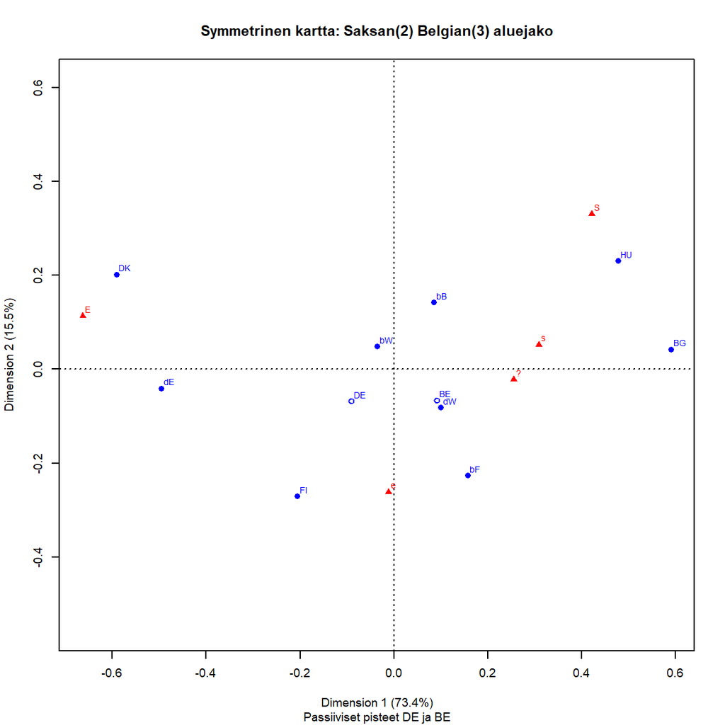

Belgian ja Saksan aluejako

```r
suppointCA2 <- ca(suppoint1_tab1[,1:5], suprow = 10:11)
par(cex = 0.6)
plot(suppointCA2, main = "Symmetrinen kartta: Saksan(2) Belgian(3) aluejako",
     sub = "Passiiviset pisteet DE ja BE" )
```

Kääntöä ei tarvita, kun maiden järjestys on sama myös muuttujassa maa3 (mukana maiden jaot).

Saksan ja Belgian summarivit ovat ositteiden painotettuja keskiarvoja (sentroideja), esim.läntisen ja itäisen Saksan rivipisteiden välisellä janalla on koko maan summapiste DE.

**18.9.20** Hajonta kasvaa, ja kartan oikealla puolella sarakkeiden etäisyydet kasvavat. Erityisest S-piste nousee toisen dimension suuntaan ylöspäin. Muiden maiden pisteet eivät juuri muuta suhteellisia sijaintejaan, mutta “Belgia leviää pystysuuntaan ja Saksa vaakasuuntaan.” Bryssel (bB) ja Flanders (bF) ovan konservatiivisempiä kuin lievästi liberaalimpi Wallonia (bW). Flandersin ja Brysselin ero on mielipiteen varmuudessa tai tiukkuudussa, ja Bryssel saattaa olla polarisoitunut (lievä Guttman-efekti).

```r
# riviprofiilitaulukko joteskin (18.9.20)
ISSP2012esim1.dat %>% tableX(maa3, Q1b, type = "row_perc")
```

| maa3/Q1b | S | s | ? | e | E | Total |
| --- | --- | --- | --- | --- | --- | --- |
| bF | 5.04 | 23.81 | 25.89 | 30.83 | 14.43 | 100.00 |
| bW | 10.82 | 21.02 | 18.57 | 24.08 | 25.51 | 100.00 |
| bB | 17.03 | 20.94 | 16.63 | 23.87 | 21.53 | 100.00 |
| BG | 12.81 | 42.89 | 22.26 | 20.63 | 1.41 | 100.00 |
| dW | 11.40 | 26.82 | 11.83 | 32.13 | 17.82 | 100.00 |
| dE | 5.85 | 11.33 | 10.97 | 29.80 | 42.05 | 100.00 |
| DK | 5.04 | 17.15 | 10.95 | 16.71 | 50.14 | 100.00 |
| FI | 4.23 | 16.94 | 13.42 | 38.11 | 27.30 | 100.00 |
| HU | 21.97 | 28.89 | 22.57 | 19.06 | 7.52 | 100.00 |
| All | 9.95 | 23.76 | 16.79 | 26.10 | 23.41 | 100.00 |

Piirretään vertailun vuoksi vielä asymmetrinen kartta (“kontribuutio-kartta, kontribuutio-kaksoiskuva”). **edit 3.5.20** Minne katoavat pisteet, outoa?

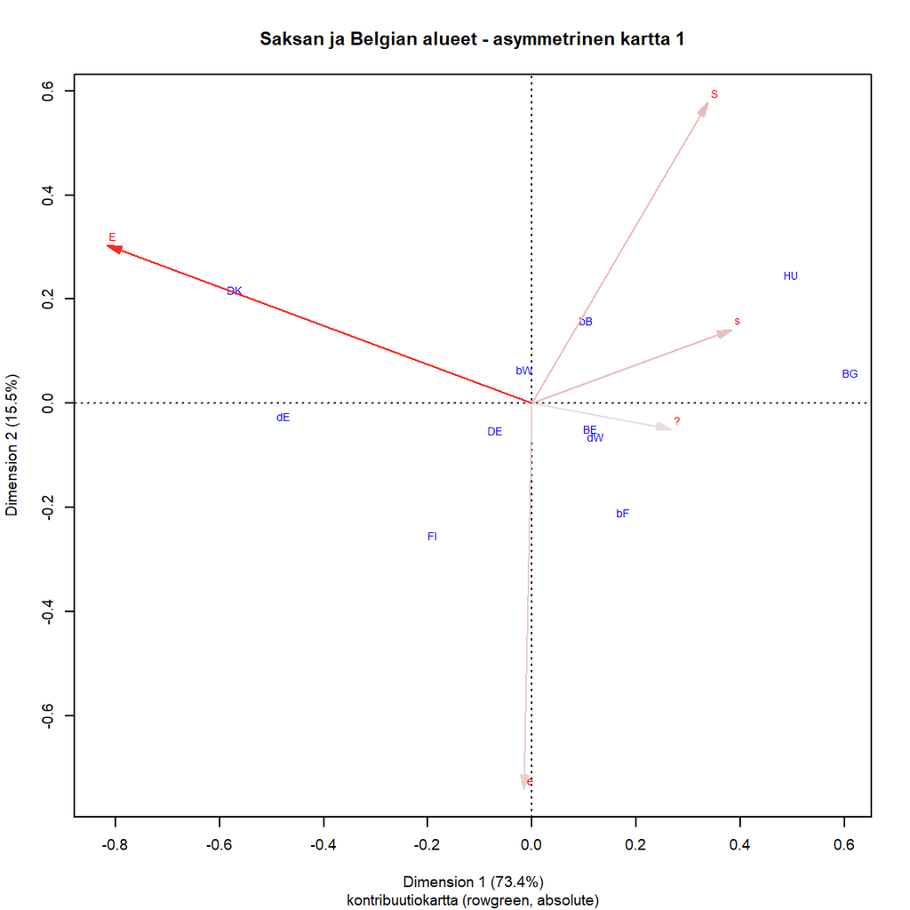

Belgian ja Saksan aluejako

```r
par(cex = 0.6)
plot(suppointCA2, map = "rowgreen",
     contrib = c("absolute", "absolute"),
     mass = c(TRUE,TRUE),
     arrows = c(FALSE, TRUE),
     main = "Saksan ja Belgian alueet - asymmetrinen kartta 1",
     sub = "kontribuutiokartta (rowgreen, absolute)")
```

Maapisteet täydentävinä pisteinä

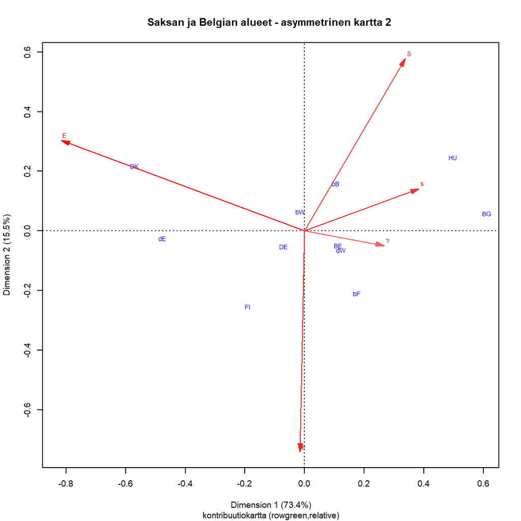

Belgian ja Saksan aluejako

```r
# Sama kuva, maasummat lisäpisteinä (4.2.20)
par(cex = 0.6)
plot(suppointCA2, map = "rowgreen",
     contrib = c("relative", "relative"),
     mass = c(TRUE,TRUE),
     arrows = c(FALSE, TRUE),
     main = "Saksan ja Belgian alueet - asymmetrinen kartta 2 ",
     sub = "kontribuutiokartta (rowgreen,relative)")
```

Kaksi asymmetristä konrtibuutio-karttaa (MG:n keksintö) osoittavat, että tulkinnan hankaluuksista huolimatta symmetrinen kartta on usein selkeämpi. Molemmissa ideaalipisteet sijatsevat kaukana, vaikka ne on skaalattu hieman lähemmäs origoa. Maapisteiden hajontaa on aika vaikeaa nähdä. Belgian täydentävä maapiste (BE) peittyy läntisen Saksan (dW) alle. “rowgreen-kartoista” puuttuvat jostain syystä pisteet.

Tulostetaan numeeriset taulukot.

```r
# CA - numeeriset tulokset

summary(suppointCA2)
```

```
##
## Principal inertias (eigenvalues):
##
##  dim    value      %   cum%   scree plot
##  1      0.154101  73.4  73.4  ******************
##  2      0.032489  15.5  88.9  ****
##  3      0.014294   6.8  95.7  **
##  4      0.008944   4.3 100.0  *
##         -------- -----
##  Total: 0.209828 100.0
##
##
## Rows:
##       name   mass  qlt  inr    k=1 cor  ctr    k=2 cor  ctr
## 1  |    bF |  124  650   69 |  157 212   20 | -226 438  195 |
## 2  |    bW |   60  388    3 |  -36 137    0 |   48 252    4 |
## 3  |    bB |   63  481   17 |   85 127    3 |  142 354   39 |
## 4  |    BG |  113  878  215 |  590 874  255 |   43   5    6 |
## 5  |    dW |  143  345   33 |  100 208    9 |  -81 138   29 |
## 6  |    dE |   67  966   82 | -495 960  107 |  -41   7    3 |
## 7  |    DK |  170  971  327 | -591 869  387 |  202 102  214 |
## 8  |    FI |  136  957   79 | -206 352   38 | -271 605  307 |
## 9  |    HU |  122  927  177 |  477 751  181 |  231 176  201 |
## 10 | (*)BE | <NA>  512 <NA> |   92 338 <NA> |  -66 173 <NA> |
## 11 | (*)DE | <NA>  418 <NA> |  -90 265 <NA> |  -68 153 <NA> |
##
## Columns:
##     name   mass  qlt  inr    k=1 cor ctr    k=2 cor ctr
## 1 |    S |   99  816  167 |  421 505 115 |  331 311 335 |
## 2 |    s |  238  781  143 |  309 759 147 |   52  22  20 |
## 3 |      |  168  594   88 |  255 589  71 |  -22   4   2 |
## 4 |    e |  261  871   98 |  -12   2   0 | -262 870 550 |
## 5 |    E |  234  999  505 | -663 971 667 |  113  28  93 |
```

Kolmiulotteisesta kuvasta voi tulostaa molempien akseleiden ja uuden kolmannen akselin kartat. R-ohjelmistossa voi tulostaa näytölle kolmiulotteisen kuvan, siitä voisi ehkä ottaa kuvakaappauksena esimerkin raporttiin?

**edit** Kommentti 3d-ratkaisusta: tuo esiin Belgian (“belgioiden”) erilaisuuden. "Belgiat ovat 2-3 - dimension kartassa diagonaalilla, ja 1-3 kartassa hieman samoin kuin 2-d - ratkaisun kartassa. Tarvittaessa voi liittää myös 3-d - kuvia, pitäsi saada myös dynaamisen pdf-tiedostoon? (8.6.2020). Mutta 2d-approksimaatio on aika hyvä, 89 % kokonaisinertiasta. Miten pitäisi jatkaa? Analysoida maiden sisäisiä eroja? Siinä erilaiset aluejaot ovat aika herkästi korvikemuuttujia joillekin muille vaikuttaville tekijöile. Entäs kaupungit - isot ja pienet - ja maaseutu? Elinkeinorakenne, tulot jne…

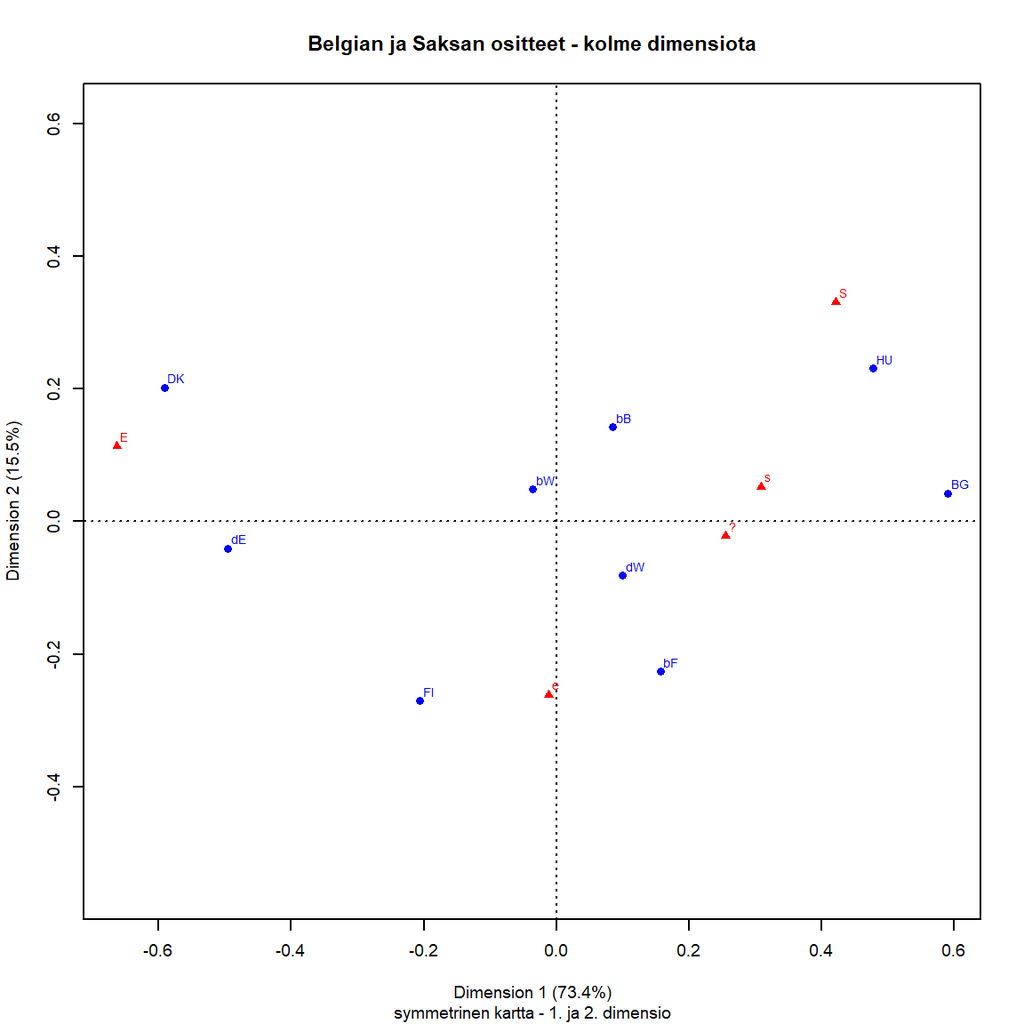

Belgian ja Saksan aluejako - 3D

```r
# Näkyisikö Belgian aluejako kolmannessa dimensiossa? (19.2.20). Näkyy, ja
# kaksiulotteisen ratkaisun numeerisista tuloksista näkee myös pisteet joiden
# kvalitetti on heikko.


suppointCA3 <- ca(~maa3 + Q1b,ISSP2012esim1.dat, nd = 3)
# (24.2.20)
# Tulostetaan kolme karttaa - ensimmäinen ja toinen akseli uuden kolmannen kera
par(cex = 0.6)
plot(suppointCA3, dim = c(1,2),
                main = "Belgian ja Saksan ositteet - kolme dimensiota",
                sub = "symmetrinen kartta - 1. ja 2. dimensio")
```

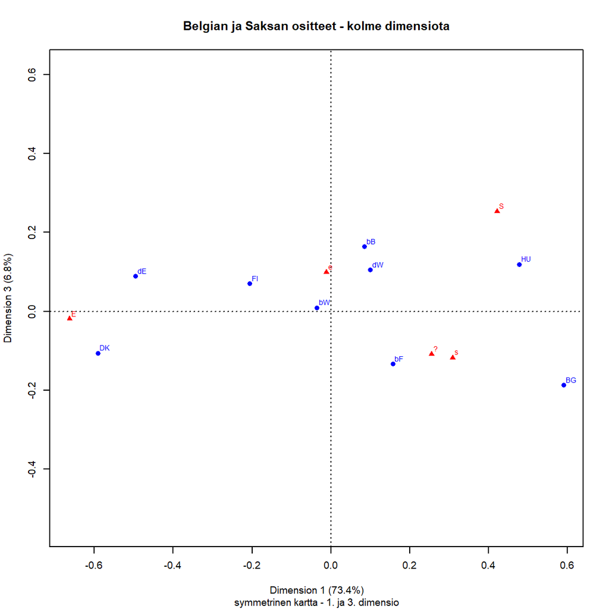

Belgian ja Saksan aluejako - 3D

```r
par(cex = 0.6)
plot(suppointCA3, dim = c(1,3),
                main = "Belgian ja Saksan ositteet - kolme dimensiota",
                sub = "symmetrinen kartta - 1. ja 3. dimensio")
```

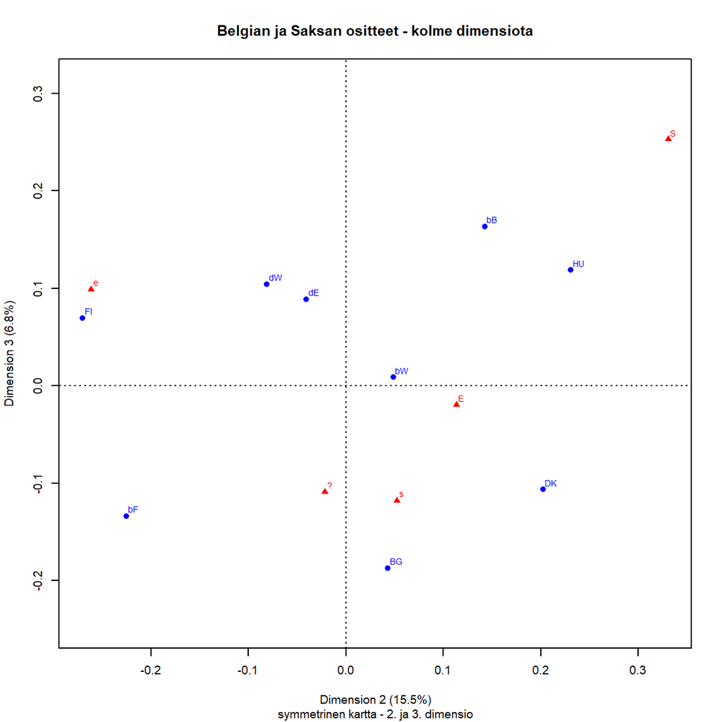

Belgian ja Saksan aluejako - 3D

```r
par(cex = 0.6)
plot(suppointCA3, dim = c(2,3),
                main = "Belgian ja Saksan ositteet - kolme dimensiota",
                sub = "symmetrinen kartta - 2. ja 3. dimensio")
```

```r
# KUMMALLINEN JUTTU, summary() EI TOIMI KUN 3d-ratkaisu!# KUMMALLINEN JUTTU,
# summary() EI TOIMI KUN 3d-ratkaisu!
# summary(suppointCA3)
# Error in rsc %*% diag(sv) : non-conformable arguments

# Virheilmoitus "Error in rsc %*% diag(sv) : non-conformable arguments" ?!
# onko vika täydentävissä pisteissä? Ei ole, eivät ole mukana
# ISSP2012esim1.dat %>% tableX(maa3, Q1b)

# suppointCA3

# Virheilmoituksen selvittelyä (24.2.20)
# str(suppointCA3)
# tämä matriisikertolasku ei onnistu - 3d-ratkaisussa on vain kolme koordinaattia!
# suppointCA3$rowcoord
# diag(suppointCA3$sv)
# suppointCA1$rowcoord %*% diag(suppointCA1$sv)

#Tämä toimii
#
# suppointCA1$rowcoord
# suppointCA1$sv
# suppointCA1$rowcoord %*% diag(suppointCA1$sv)
# summary(suppointCA1)
#
# Kolmiulottein kuva grafiikkaikkunaan
# X11()
# plot3d(suppointCA3, c(1,2,3))

# Hyödyllinen, mutta aika vaikea
```

Kolmiulotteisesta kuvasta Belgian ja Saksan alueiden hajonta tasosta näkyy hieman selvemmin jos kuva olisi dynaaminen. On mahdollista, mutta tätä ei nyt tehdä (17.9.20). Kolmannen dimension osuus on noin seitsemän prosenttia kokonaisinertiasta, kaksiulotteisten karttojen tulkinta ei ole ihan helppoa. **TODO 3d-numeeriset tulokset, summary() ei toimi?**

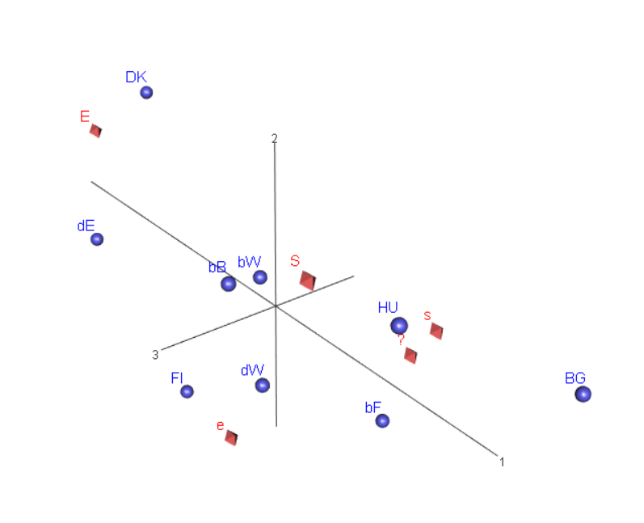

```r
knitr::include_graphics('img/3dSymMap_1.PNG')
```

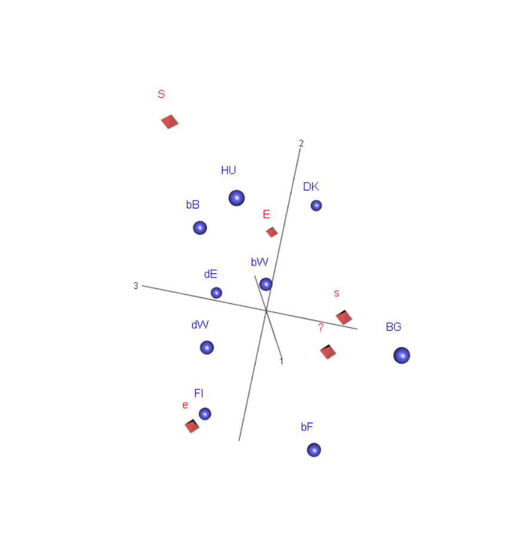

```r
knitr::include_graphics('img/3dSymMap_2.PNG')
```

**edit 9.9.20** Tällä datalla ABBA stacked-jaksossa?

## 4.2 Korrespondenssianalyysin laajennuksia: vuorovaikutusmuuttuja ja osajoukon CA

**zxy** Otsikkoa pitää harkita, CAip - kirjassa tämä on ensimmäinen esimerkki yksinkertaisen CA:n laajennuksesta. Otsikkona on “multiway tables”, ja tästä yhteisvaikutusmuuttujan (interactive coding) luominen on ensimmäinen esimerkki. Menetelmää taivutetaan sen jälkeen moneen suuntaan.

Luodaan luokiteltu ikämuuttua age_cat, ja sen avulla iän ja sukupuolen interaktiomuuttuja ga. Maiden välillä on hieman eroja siinä, kuinka nuoria vastaajia on otettu tutkimuksen kohteeksi. Suomessa alaikäraja on 15 vuotta, monessa maassa se on hieman korkeampi. Ikäluokat ovat (1=15-25, 2 =26-35, 3=36-45, 4=46-55, 5=56-65, 6= 66 tai vanhempi). Vuorovaikutusmuuttuja ga koodataan f1,…, f6 ja m1,…,m6. Muuttujien nimet kannattaa pitää mahdollisimman lyhyinä.

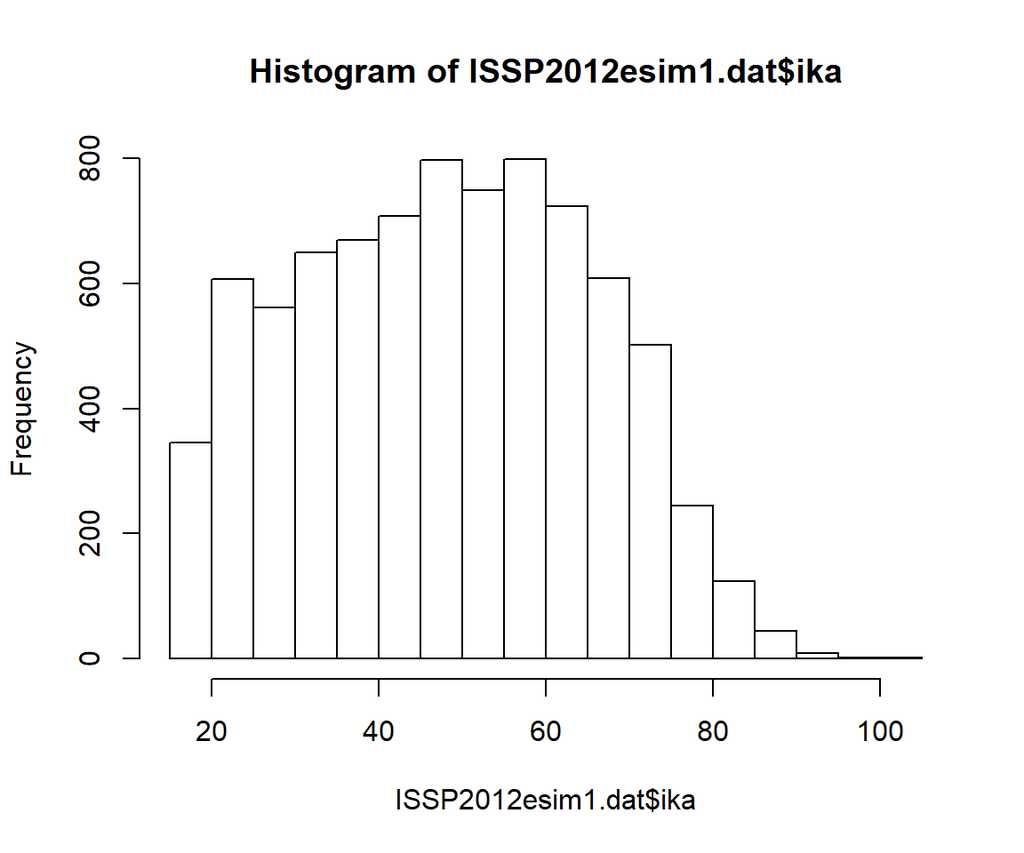

```r
# Iän ja sukupuolen vuorovaikutusmuuttujia 1
#
# Uusi R-data: ISSP2012esim2.dat - MIKSI, TARVITAANKO? *esim1.dat kelpaisi?(4.2.20)
#
#age_cat
#AGE 1=15-25, 2 =26-35, 3=36-45, 4=46-55, 5=56-65, 6= 66 and older
#
#summary(ISSP2012esim1.dat$AGE)
hist(ISSP2012esim1.dat$ika)
```

```r
ISSP2012esim2.dat <- mutate(ISSP2012esim1.dat, age_cat = ifelse(ika %in% 15:25, "1",
                        ifelse(ika %in% 26:35, "2",
                        ifelse(ika %in% 36:45, "3",
                        ifelse(ika %in% 46:55, "4",
                        ifelse(ika %in% 56:65, "5", "6"))))))


ISSP2012esim2.dat <- ISSP2012esim2.dat %>%   # uusi (4.2.20)
        mutate(age_cat = as_factor(age_cat)) # järjestys omituinen! (4.2.20)
# Tarkistuksia

# str(ISSP2012esim2.dat$age_cat)
# levels(ISSP2012esim2.dat$age_cat)
# ISSP2012esim2.dat$age_cat %>% summary()

# Järjestetään ikäluokat uudelleen

ISSP2012esim2.dat <- ISSP2012esim2.dat %>%
        mutate(age_cat =
                fct_relevel(age_cat,
                            "1",
                            "2",
                            "3",
                            "4",
                            "5",
                            "6")
               )

# Tarkistuksia

# Iso taulukko, voi tarkistaa että muunnos ok.
# test6 %>% tableX(AGE, age_cat, type = "count")
# taulu42 <- ISSP2012esim2.dat %>% tableX(maa,age_cat,type = "count")
# kable(taulu42,digits = 2, caption = "Ikäluokka age_cat")
#

# UUdet taulukot (4.2.20)

ISSP2012esim2.dat %>%
    tableX(maa,age_cat,type = "count") %>%
    kable(digits = 2, caption = "Ikäluokka age_cat")
```

Ikäluokka age_cat

|  | 1 | 2 | 3 | 4 | 5 | 6 | Total |
| --- | --- | --- | --- | --- | --- | --- | --- |
| BE | 208 | 333 | 336 | 375 | 368 | 393 | 2013 |
| BG | 77 | 115 | 159 | 148 | 198 | 224 | 921 |
| DE | 205 | 223 | 274 | 358 | 288 | 366 | 1714 |
| DK | 207 | 213 | 245 | 271 | 234 | 218 | 1388 |
| FI | 152 | 166 | 165 | 223 | 238 | 166 | 1110 |
| HU | 103 | 161 | 198 | 171 | 196 | 168 | 997 |
| Total | 952 | 1211 | 1377 | 1546 | 1522 | 1535 | 8143 |

```r
ISSP2012esim2.dat %>%
    tableX(maa,age_cat,type = "row_perc") %>%
    kable(digits = 2, caption = "age_cat: suhteelliset frekvenssit")
```

age_cat: suhteelliset frekvenssit

|  | 1 | 2 | 3 | 4 | 5 | 6 | Total |
| --- | --- | --- | --- | --- | --- | --- | --- |
| BE | 10.33 | 16.54 | 16.69 | 18.63 | 18.28 | 19.52 | 100.00 |
| BG | 8.36 | 12.49 | 17.26 | 16.07 | 21.50 | 24.32 | 100.00 |
| DE | 11.96 | 13.01 | 15.99 | 20.89 | 16.80 | 21.35 | 100.00 |
| DK | 14.91 | 15.35 | 17.65 | 19.52 | 16.86 | 15.71 | 100.00 |
| FI | 13.69 | 14.95 | 14.86 | 20.09 | 21.44 | 14.95 | 100.00 |
| HU | 10.33 | 16.15 | 19.86 | 17.15 | 19.66 | 16.85 | 100.00 |
| All | 11.69 | 14.87 | 16.91 | 18.99 | 18.69 | 18.85 | 100.00 |

**zxy** Siistimmät versioit muuttujien luonnista (case_when - rakenne) (19.9.2018).

```r
# ga - ikäluokka ja sukupuoli

# case_when: ikä ja sukupuoli
ISSP2012esim2.dat <- mutate(ISSP2012esim2.dat, ga = case_when((age_cat == "1")&(sp == "m") ~ "m1",
                                       (age_cat == "2")&(sp == "m") ~ "m2",
                                       (age_cat == "3")&(sp == "m") ~ "m3",
                                       (age_cat == "4")&(sp == "m") ~ "m4",
                                       (age_cat == "5")&(sp == "m") ~ "m5",
                                       (age_cat == "6")&(sp == "m") ~ "m6",
                                       (age_cat == "1")&(sp == "f") ~ "f1",
                                       (age_cat == "2")&(sp == "f") ~ "f2",
                                       (age_cat == "3")&(sp == "f") ~ "f3",
                                       (age_cat == "4")&(sp == "f") ~ "f4",
                                       (age_cat == "4")&(sp == "f") ~ "f4",
                                       (age_cat == "5")&(sp == "f") ~ "f5",
                                       (age_cat == "6")&(sp == "f") ~ "f6",
                                       TRUE ~ "missing"
                                  ))

#ISSP2012esim1.dat %>% tableX(ga,ga2) # tarkistus uudelle muuttujan luontikoodille
# muuttujien tarkistuksia 19.9.2018
str(ISSP2012esim2.dat$ga) # chr-muuttuja, mutta toimii (4.2.20)
```

```
##  chr [1:8143] "f5" "f3" "m5" "f2" "f4" "f4" "m4" "m3" "f5" "m5" "m3" "f5" ...
```

```r
# str(ISSP2012esim2.dat)
# str(ISSP2012esim1.dat$ga2)
# ga on merkkijono, samoin ga2, pitäisikö muuttaa faktoriksi?
# str(ISSP2012esim1.dat)

#Tulostetaan taulukkoina ga2 - muuttuja.

ISSP2012esim2.dat %>% tableX(maa,ga,type = "count") %>%
kable(digits = 2, caption = "Ikäluokka ja sukupuoli ga")
```

Ikäluokka ja sukupuoli ga

|  | f1 | f2 | f3 | f4 | f5 | f6 | m1 | m2 | m3 | m4 | m5 | m6 | Total |
| --- | --- | --- | --- | --- | --- | --- | --- | --- | --- | --- | --- | --- | --- |
| BE | 116 | 198 | 174 | 199 | 186 | 185 | 92 | 135 | 162 | 176 | 182 | 208 | 2013 |
| BG | 40 | 64 | 94 | 85 | 114 | 149 | 37 | 51 | 65 | 63 | 84 | 75 | 921 |
| DE | 102 | 120 | 152 | 186 | 135 | 185 | 103 | 103 | 122 | 172 | 153 | 181 | 1714 |
| DK | 83 | 110 | 136 | 146 | 128 | 99 | 124 | 103 | 109 | 125 | 106 | 119 | 1388 |
| FI | 94 | 95 | 94 | 118 | 142 | 91 | 58 | 71 | 71 | 105 | 96 | 75 | 1110 |
| HU | 54 | 86 | 95 | 91 | 94 | 104 | 49 | 75 | 103 | 80 | 102 | 64 | 997 |
| Total | 489 | 673 | 745 | 825 | 799 | 813 | 463 | 538 | 632 | 721 | 723 | 722 | 8143 |

```r
ISSP2012esim2.dat %>% tableX(maa,ga,type = "row_perc") %>%
kable(digits = 2, caption = "ga: suhteelliset frekvenssit")
```

ga: suhteelliset frekvenssit

|  | f1 | f2 | f3 | f4 | f5 | f6 | m1 | m2 | m3 | m4 | m5 | m6 | Total |
| --- | --- | --- | --- | --- | --- | --- | --- | --- | --- | --- | --- | --- | --- |
| BE | 5.76 | 9.84 | 8.64 | 9.89 | 9.24 | 9.19 | 4.57 | 6.71 | 8.05 | 8.74 | 9.04 | 10.33 | 100.00 |
| BG | 4.34 | 6.95 | 10.21 | 9.23 | 12.38 | 16.18 | 4.02 | 5.54 | 7.06 | 6.84 | 9.12 | 8.14 | 100.00 |
| DE | 5.95 | 7.00 | 8.87 | 10.85 | 7.88 | 10.79 | 6.01 | 6.01 | 7.12 | 10.04 | 8.93 | 10.56 | 100.00 |
| DK | 5.98 | 7.93 | 9.80 | 10.52 | 9.22 | 7.13 | 8.93 | 7.42 | 7.85 | 9.01 | 7.64 | 8.57 | 100.00 |
| FI | 8.47 | 8.56 | 8.47 | 10.63 | 12.79 | 8.20 | 5.23 | 6.40 | 6.40 | 9.46 | 8.65 | 6.76 | 100.00 |
| HU | 5.42 | 8.63 | 9.53 | 9.13 | 9.43 | 10.43 | 4.91 | 7.52 | 10.33 | 8.02 | 10.23 | 6.42 | 100.00 |
| All | 6.01 | 8.26 | 9.15 | 10.13 | 9.81 | 9.98 | 5.69 | 6.61 | 7.76 | 8.85 | 8.88 | 8.87 | 100.00 |

**edit** Vain tarkistuksiin, toisen voi poistaa (19.9.2018)!

CAiP, ch16, täällä myös maa- ja sukupuoli- uudelleenpainotus.

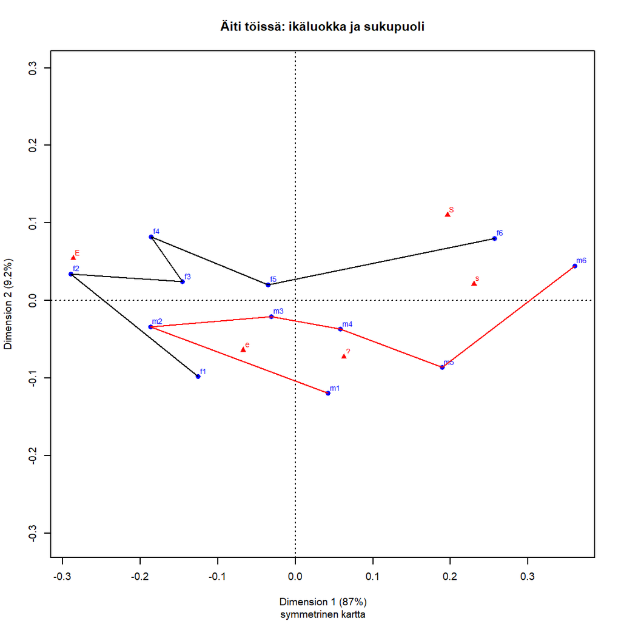

Iän ja sukupuolen yhdistetty muuttuja

```r
gaTestCA1 <- ca(~ga + Q1b,ISSP2012esim2.dat)

# maapisteiden pääkoordinaatit janojen piirtämiseen

gaTestCA1.rpc <- gaTestCA1$rowcoord %*% diag(gaTestCA1$sv)

par(cex = 0.6)
plot(gaTestCA1, main = "Äiti töissä: ikäluokka ja sukupuoli",
     sub = "symmetrinen kartta")
# naiset
lines(gaTestCA1.rpc[1:6,1],gaTestCA1.rpc[1:6,2])
#miehet
lines(gaTestCA1.rpc[7:12,1],gaTestCA1.rpc[7:12,2], col = "red")
```

```r
#segments(gaTestCA1.rpc[1:6,1],gaTestCA1.rpc[1:6,2])
#         ,
#         gaTestCA1.rpc[4,1],gaTestCA1.rpc[4,2]
#         )
#segments(gaTestCA1.rpc[4,1],gaTestCA1.rpc[4,2],
#         gaTestCA1.rpc[3,1],gaTestCA1.rpc[3,2]
#        )

summary(gaTestCA1)
```

```
##
## Principal inertias (eigenvalues):
##
##  dim    value      %   cum%   scree plot
##  1      0.037448  87.0  87.0  **********************
##  2      0.003977   9.2  96.2  **
##  3      0.001041   2.4  98.6  *
##  4      0.000590   1.4 100.0
##         -------- -----
##  Total: 0.043055 100.0
##
##
## Rows:
##      name   mass  qlt  inr    k=1 cor ctr    k=2 cor ctr
## 1  |   f1 |   60  990   36 | -125 614  25 |  -98 376 145 |
## 2  |   f2 |   83  997  163 | -289 983 185 |   35  14  25 |
## 3  |   f3 |   91  984   47 | -146 958  52 |   24  26  13 |
## 4  |   f4 |  101 1000   97 | -186 836  93 |   82 164 172 |
## 5  |   f5 |   98  879    4 |  -35 658   3 |   20 221  10 |
## 6  |   f6 |  100  951  176 |  256 866 175 |   80  85 162 |
## 7  |   m1 |   57  659   32 |   42  72   3 | -120 587 205 |
## 8  |   m2 |   66  977   57 | -187 946  62 |  -34  30  19 |
## 9  |   m3 |   78  457    5 |  -31 318   2 |  -20 139   8 |
## 10 |   m4 |   89  674   14 |   58 482   8 |  -37 192  30 |
## 11 |   m5 |   89  988   90 |  189 818  85 |  -86 170 166 |
## 12 |   m6 |   89  978  277 |  360 963 307 |   45  15  45 |
##
## Columns:
##     name   mass  qlt  inr    k=1 cor ctr    k=2 cor ctr
## 1 |    S |   99  915  128 |  196 695 102 |  110 220 304 |
## 2 |    s |  238  969  304 |  230 961 336 |   21   8  27 |
## 3 |      |  168  777   46 |   62 330  17 |  -73 447 223 |
## 4 |    e |  261  897   58 |  -68 473  32 |  -64 424 268 |
## 5 |    E |  234  997  464 | -286 962 513 |   55  35 177 |
```

**zxy** Aika yksiuloitteinen (87 prosenttia ensimmäisellä dimensiolla!). Data on “as it is”, ei ole vakioitu ga-luokkien kokoja (massat max(f4 101), min (m1 57)).

**zxy** miten pitäisi tulkita “oikealle kaatunut U - muoto” miehillä ja naisilla? Järjestys ei toimi, S s-sarakkeen vasemmalla puolella. Miehet konservatiivisempia, mutta maltillisempia? Nuorin ikäluokka on poikkeava. Epävarmoja tai maltillisesti e, sitten loikka vasemmalle ja sieltä konservatiiviseen suuntaa oikealle. Naisilla poikkeama f3 - f4. VAnhimmat ikäluokat tiukemmin konservatiivisa (f6, m6). Jos vertaa sukupuolten eroja samassa ikäluokassa, on aika samanlainen (miehet konservatiivisia, naiset liberaaleja). Naisista vain vanhin ikäluokka oikealla, miehistä nuorin ja kolme vanhinta.

**zxy** Tulkinnassa muistettava, että ikäluokat yli maiden. Voi verrata sekä edellisiin maa-vertailuihin että maan, ikäluokan ja sukupuolen yhteisvaikutusmuuttujan tuloksiin. MG tutkailee eri kysymyksellä tätä samaa asiaa, ja havaitsee että (a) maiden erot suuria ja sukupuolten pieniä (b) naiset liberaalimpia kuin miehet. **edit 14.8.20 Viite?**

**edit 14.8.20** Numeeriset tulokset: nuorimpien miesten (qlt 659) ja erityisesti keski-ikäisten miestén m3 (qlt 457) pisteet huonosti esitetty kartalla. Tulkitaan myös cor ja ctr, riveille ja sarakkeille.

```r
# Luodaan aineistoon kolmen muuttujan yhdysvaikutusmuuttuja maaga, maa, ikäluokka ja sukupuoli.
# Yleensä ei yhdysvaikuksissa mennä yli kolmen luokittelumuuttujan, ja tässäkin vain maiden pieni lukumää
# tekee tarkastelun aika helpoksi.

ISSP2012esim2.dat <- mutate(ISSP2012esim2.dat, maaga = paste(maa, ga, sep = ""))

# tarkistus, muunnos ok
# ISSP2012esim2.dat %>% tableX(maa, maaga)

# head(ISSP2012esim2.dat)
# str(ISSP2012esim2.dat)
```

**Maa - ikäluokka - sukupuoli - interaktiomuuttuja maaga**

Tehty jo 26.9.2018!

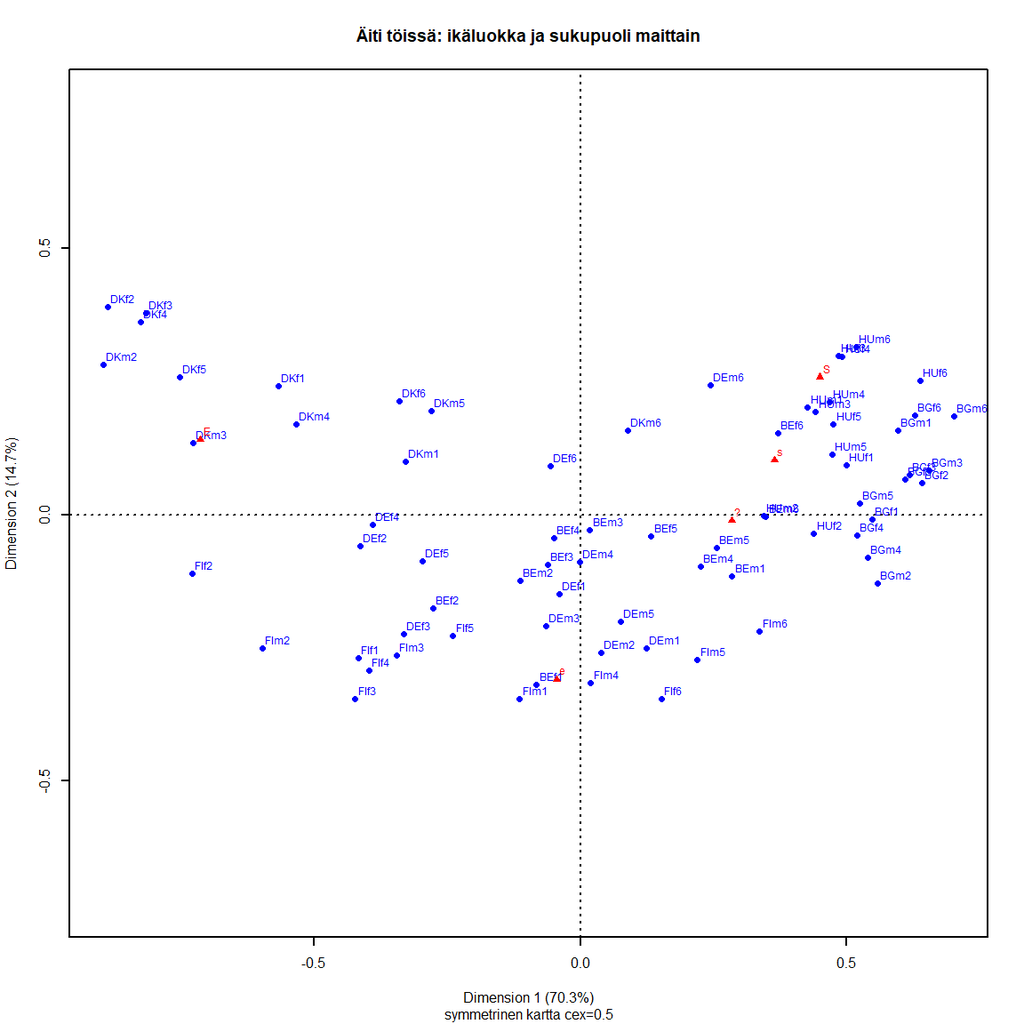

Ikä, sukupuoli ja maa

```r
maagaCA1 <- ca(~maaga + Q1b,ISSP2012esim2.dat)



# maapisteiden pääkoordinaatit janojen piirtämiseen
# HUOM! maagaCA1.rpc on matriisi

maagaCA1.rpc <- maagaCA1$rowcoord %*% diag(maagaCA1$sv)

par(cex = 0.5)
plot(maagaCA1, main = "Äiti töissä: ikäluokka ja sukupuoli maittain",
                sub = "symmetrinen kartta cex=0.5")
```

```r
#Kuvatiedoston koko säädettävä tarkemmin (30.3.20)

# Miten kuvatiedosto talteen?
# Omana koodipätkänä (4.5.2020)

# pdf("img/maagaCA1_symm1.pdf")
# par(cex = 0.5)
# plot(maagaCA1, main = "Äiti töissä: ikäluokka ja sukupuoli maittain",
#                sub = "symmetrinen kartta cex=0.5")
# dev.off()
```

Kartta on aika tukkoinen, yhdistetään muuttujat janoilla.

## 4.3 Kvaliteetti ja stabiilius

maaga-talukossa on paljon pieniä frekvenssejä (alle 5). Periaatteessa pienen frekvenssin rivejä tai sarakkeita voi yhdistää (distr. equivivalece), ja näin kannattaa tehdä jotta kartta ei mene tukkoon. **9.9.20** Pienet solufrekvenssin vs. pienet reunajakauman frekvenssin, miten edellisen kanssa pitäisi toimia?

Kartan herkkyyttä joillekin pienen massan rivipisteille on tutkittu. Ei ilmeistä syytä huoleen, mutta (a) joidenkin pisteiden huono kvaliteetti ja (b) pienet solufrekvenssit ovat huono juttu. Jälkimmäisen voisi korjata yhdistelemättä luokkia, hyöty olisi kuvan selkeytyminen ja haitta kiinnostavien piirteiden peittymine. Erityisesti nuorimman ja toiseksi nuorimman ikäluokan ero.

Vertailu voi tehdä

1.Maiden sisällä, ikä-sukupuoli - luokkien välillä. Ovatko naiset kaikissa ikäluokissa mies-ikäluokkien oikealla vai vasemmalla puolella?

2.Maiden välillä

1. miten ikä-sukupuoliluokat sijaitsevat suhteessa maiden keskiarvopisteisiin
2. mikä on niiden järjestys

Ratkaisun numeerisia tuloksia voi katsoa, löytyykö profiileja joilla on pieni massa mutta suuri vaikutus akseleihin.

```r
# (24.2.20) Miten voisi kätevästi tarkistaa, että mikään pienen massa piste ei
# vaikuta (kontribuutiot) liikaa karttaan?
#str(maagaTestCA1)

ISSP2012esim2.dat %>% tableX(maaga, Q1b) # aika pieniä frekvenssejä soluissa!
```

| maaga/Q1b | S | s | ? | e | E | Total |
| --- | --- | --- | --- | --- | --- | --- |
| BEf1 | 5 | 15 | 28 | 43 | 25 | 116 |
| BEf2 | 10 | 26 | 34 | 66 | 62 | 198 |
| BEf3 | 19 | 27 | 33 | 53 | 42 | 174 |
| BEf4 | 21 | 34 | 40 | 55 | 49 | 199 |
| BEf5 | 21 | 38 | 46 | 48 | 33 | 186 |
| BEf6 | 25 | 58 | 50 | 30 | 22 | 185 |
| BEm1 | 9 | 19 | 30 | 24 | 10 | 92 |
| BEm2 | 10 | 19 | 31 | 40 | 35 | 135 |
| BEm3 | 18 | 33 | 31 | 44 | 36 | 162 |
| BEm4 | 19 | 46 | 37 | 51 | 23 | 176 |
| BEm5 | 15 | 61 | 34 | 49 | 23 | 182 |
| BEm6 | 19 | 75 | 44 | 49 | 21 | 208 |
| BGf1 | 2 | 21 | 7 | 9 | 1 | 40 |
| BGf2 | 7 | 28 | 17 | 12 | 0 | 64 |
| BGf3 | 10 | 44 | 21 | 18 | 1 | 94 |
| BGf4 | 14 | 30 | 15 | 24 | 2 | 85 |
| BGf5 | 16 | 51 | 21 | 25 | 1 | 114 |
| BGf6 | 27 | 66 | 26 | 27 | 3 | 149 |
| BGm1 | 8 | 12 | 9 | 7 | 1 | 37 |
| BGm2 | 4 | 21 | 12 | 14 | 0 | 51 |
| BGm3 | 5 | 33 | 16 | 11 | 0 | 65 |
| BGm4 | 7 | 19 | 21 | 15 | 1 | 63 |
| BGm5 | 12 | 29 | 21 | 19 | 3 | 84 |
| BGm6 | 6 | 41 | 19 | 9 | 0 | 75 |
| DEf1 | 5 | 28 | 13 | 33 | 23 | 102 |
| DEf2 | 9 | 14 | 14 | 37 | 46 | 120 |
| DEf3 | 10 | 22 | 12 | 59 | 49 | 152 |
| DEf4 | 11 | 31 | 20 | 53 | 71 | 186 |
| DEf5 | 8 | 27 | 12 | 43 | 45 | 135 |
| DEf6 | 31 | 40 | 15 | 50 | 49 | 185 |
| DEm1 | 6 | 26 | 20 | 36 | 15 | 103 |
| DEm2 | 7 | 26 | 13 | 39 | 18 | 103 |
| DEm3 | 11 | 24 | 15 | 45 | 27 | 122 |
| DEm4 | 22 | 39 | 17 | 57 | 37 | 172 |
| DEm5 | 11 | 43 | 19 | 54 | 26 | 153 |
| DEm6 | 34 | 55 | 28 | 32 | 32 | 181 |
| DKf1 | 7 | 11 | 9 | 15 | 41 | 83 |
| DKf2 | 4 | 15 | 7 | 13 | 71 | 110 |
| DKf3 | 3 | 20 | 15 | 14 | 84 | 136 |
| DKf4 | 5 | 24 | 8 | 19 | 90 | 146 |
| DKf5 | 6 | 16 | 11 | 22 | 73 | 128 |
| DKf6 | 5 | 26 | 11 | 17 | 40 | 99 |
| DKm1 | 10 | 21 | 18 | 28 | 47 | 124 |
| DKm2 | 2 | 11 | 9 | 16 | 65 | 103 |
| DKm3 | 2 | 13 | 12 | 23 | 59 | 109 |
| DKm4 | 4 | 24 | 14 | 24 | 59 | 125 |
| DKm5 | 11 | 14 | 23 | 18 | 40 | 106 |
| DKm6 | 11 | 43 | 15 | 23 | 27 | 119 |
| FIf1 | 3 | 9 | 13 | 36 | 33 | 94 |
| FIf2 | 5 | 6 | 3 | 34 | 47 | 95 |
| FIf3 | 2 | 8 | 13 | 39 | 32 | 94 |
| FIf4 | 3 | 15 | 13 | 47 | 40 | 118 |
| FIf5 | 6 | 26 | 17 | 52 | 41 | 142 |
| FIf6 | 3 | 22 | 21 | 34 | 11 | 91 |
| FIm1 | 1 | 9 | 13 | 22 | 13 | 58 |
| FIm2 | 2 | 5 | 6 | 28 | 30 | 71 |
| FIm3 | 2 | 10 | 9 | 27 | 23 | 71 |
| FIm4 | 8 | 23 | 13 | 43 | 18 | 105 |
| FIm5 | 5 | 31 | 15 | 35 | 10 | 96 |
| FIm6 | 7 | 24 | 13 | 26 | 5 | 75 |
| HUf1 | 11 | 13 | 16 | 11 | 3 | 54 |
| HUf2 | 15 | 19 | 25 | 22 | 5 | 86 |
| HUf3 | 22 | 26 | 26 | 12 | 9 | 95 |
| HUf4 | 24 | 25 | 20 | 14 | 8 | 91 |
| HUf5 | 21 | 28 | 19 | 19 | 7 | 94 |
| HUf6 | 33 | 30 | 18 | 21 | 2 | 104 |
| HUm1 | 9 | 15 | 12 | 8 | 5 | 49 |
| HUm2 | 18 | 13 | 15 | 22 | 7 | 75 |
| HUm3 | 15 | 38 | 24 | 16 | 10 | 103 |
| HUm4 | 14 | 29 | 17 | 13 | 7 | 80 |
| HUm5 | 19 | 31 | 24 | 21 | 7 | 102 |
| HUm6 | 18 | 21 | 9 | 11 | 5 | 64 |
| Total | 810 | 1935 | 1367 | 2125 | 1906 | 8143 |

```r
maagaCA1num <- summary(maagaCA1)
# maagaCA1num
# str(maagaCA1num) numeeriset tulokset tibbleksi - rivit
maagaCAnum2 <- as_tibble(maagaCA1num$rows, .name_repair = c("unique"))
```

```
## * cor -> cor...6
## * ctr -> ctr...7
## * cor -> cor...9
## * ctr -> ctr...10
```

```r
# maagaCAnum2
# str(maagaCAnum2)
summary(maagaCAnum2)
```

|  | name | mass | qlt | inr | k=1 | cor…6 | ctr…7 | k=2 | cor…9 | ctr…10 |
| --- | --- | --- | --- | --- | --- | --- | --- | --- | --- | --- |
|  | BEf1 : 1 | Min. : 5.00 | Min. :108.0 | Min. : 1.00 | Min. :-895.00 | Min. : 0.0 | Min. : 0.00 | Min. :-347.000 | Min. : 0.00 | Min. : 0.00 |
|  | BEf2 : 1 | 1st Qu.:10.00 | 1st Qu.:704.8 | 1st Qu.: 6.75 | 1st Qu.:-330.00 | 1st Qu.:351.2 | 1st Qu.: 4.50 | 1st Qu.:-156.000 | 1st Qu.: 42.75 | 1st Qu.: 2.75 |
|  | BEf3 : 1 | Median :13.00 | Median :838.0 | Median :11.00 | Median : 82.50 | Median :667.5 | Median :11.00 | Median : -13.500 | Median :141.50 | Median :10.00 |
|  | BEf4 : 1 | Mean :13.97 | Mean :772.6 | Mean :13.88 | Mean : 46.49 | Mean :573.3 | Mean :13.92 | Mean : 1.653 | Mean :199.28 | Mean :13.86 |
|  | BEf5 : 1 | 3rd Qu.:17.00 | 3rd Qu.:953.2 | 3rd Qu.:15.00 | 3rd Qu.: 472.50 | 3rd Qu.:830.2 | 3rd Qu.:17.00 | 3rd Qu.: 173.500 | 3rd Qu.:265.50 | 3rd Qu.:21.25 |
|  | BEf6 : 1 | Max. :26.00 | Max. :999.0 | Max. :57.00 | Max. : 701.00 | Max. :982.0 | Max. :66.00 | Max. : 389.000 | Max. :834.00 | Max. :61.00 |
|  | (Other):66 | NA | NA | NA | NA | NA | NA | NA | NA | NA |

```r
colnames(maagaCAnum2) # välilyötejä nimen alussa
```

```
##  [1] "name"     "mass"     " qlt"     " inr"     " k=1"     "cor...6"
##  [7] "ctr...7"  " k=2"     "cor...9"  "ctr...10"
```

```r
names(maagaCAnum2)[3] <- "qlt"
# maagaCAnum2 %>% rename( qlt, qlt)


arrange(maagaCAnum2 , mass)
```

| name | mass | qlt | inr | k=1 | cor…6 | ctr…7 | k=2 | cor…9 | ctr…10 |
| --- | --- | --- | --- | --- | --- | --- | --- | --- | --- |
| BGf1 | 5 | 531 | 11 | 547 | 531 | 8 | -9 | 0 | 0 |
| BGm1 | 5 | 940 | 7 | 596 | 878 | 9 | 159 | 62 | 3 |
| BGm2 | 6 | 830 | 9 | 557 | 788 | 11 | -130 | 43 | 3 |
| HUm1 | 6 | 935 | 5 | 426 | 766 | 6 | 201 | 170 | 6 |
| FIm1 | 7 | 787 | 5 | -115 | 78 | 1 | -347 | 710 | 22 |
| HUf1 | 7 | 723 | 9 | 499 | 698 | 9 | 93 | 25 | 1 |
| BGf2 | 8 | 860 | 14 | 640 | 853 | 17 | 59 | 7 | 1 |
| BGm3 | 8 | 709 | 19 | 655 | 698 | 19 | 83 | 11 | 1 |
| BGm4 | 8 | 771 | 11 | 540 | 754 | 12 | -81 | 17 | 1 |
| HUm6 | 8 | 726 | 15 | 517 | 529 | 11 | 315 | 197 | 20 |
| BGm6 | 9 | 692 | 27 | 701 | 647 | 24 | 184 | 45 | 8 |
| FIm2 | 9 | 977 | 14 | -598 | 832 | 17 | -250 | 146 | 14 |
| FIm3 | 9 | 998 | 6 | -345 | 629 | 6 | -265 | 369 | 16 |
| FIm6 | 9 | 911 | 6 | 336 | 637 | 6 | -220 | 274 | 12 |
| HUm2 | 9 | 381 | 11 | 344 | 381 | 6 | -2 | 0 | 0 |
| BGf4 | 10 | 932 | 12 | 519 | 927 | 15 | -39 | 5 | 0 |
| BGm5 | 10 | 979 | 11 | 524 | 977 | 15 | 21 | 2 | 0 |
| DKf1 | 10 | 991 | 15 | -567 | 839 | 18 | 241 | 152 | 15 |
| HUm4 | 10 | 999 | 10 | 468 | 830 | 12 | 211 | 169 | 11 |
| BEm1 | 11 | 429 | 9 | 284 | 367 | 5 | -117 | 62 | 4 |
| FIf6 | 11 | 835 | 7 | 151 | 134 | 1 | -347 | 701 | 35 |
| HUf2 | 11 | 689 | 11 | 438 | 685 | 11 | -35 | 4 | 0 |
| HUf4 | 11 | 768 | 18 | 491 | 564 | 15 | 296 | 204 | 25 |
| BGf3 | 12 | 815 | 21 | 617 | 804 | 24 | 75 | 12 | 2 |
| DKf6 | 12 | 808 | 9 | -340 | 579 | 8 | 214 | 229 | 14 |
| FIf1 | 12 | 980 | 11 | -417 | 693 | 11 | -269 | 287 | 21 |
| FIf2 | 12 | 927 | 26 | -730 | 907 | 34 | -110 | 21 | 4 |
| FIf3 | 12 | 984 | 13 | -423 | 590 | 11 | -346 | 394 | 36 |
| FIm5 | 12 | 734 | 7 | 220 | 289 | 3 | -273 | 446 | 23 |
| HUf3 | 12 | 808 | 18 | 484 | 586 | 15 | 298 | 222 | 27 |
| HUf5 | 12 | 850 | 13 | 474 | 753 | 14 | 170 | 97 | 9 |
| DEf1 | 13 | 425 | 3 | -41 | 29 | 0 | -149 | 395 | 7 |
| DEm1 | 13 | 912 | 4 | 124 | 180 | 1 | -250 | 732 | 20 |
| DEm2 | 13 | 766 | 4 | 38 | 16 | 0 | -259 | 749 | 22 |
| DKm2 | 13 | 989 | 43 | -895 | 900 | 55 | 282 | 89 | 26 |
| DKm3 | 13 | 982 | 28 | -728 | 950 | 38 | 134 | 32 | 6 |
| DKm5 | 13 | 643 | 9 | -281 | 435 | 6 | 194 | 208 | 13 |
| FIm4 | 13 | 837 | 6 | 19 | 3 | 0 | -316 | 834 | 33 |
| HUf6 | 13 | 671 | 34 | 637 | 581 | 28 | 251 | 90 | 21 |
| HUm3 | 13 | 957 | 12 | 441 | 803 | 13 | 193 | 154 | 12 |
| HUm5 | 13 | 942 | 12 | 472 | 891 | 15 | 113 | 51 | 4 |
| BEf1 | 14 | 678 | 9 | -83 | 43 | 1 | -320 | 635 | 38 |
| BGf5 | 14 | 880 | 23 | 609 | 870 | 28 | 66 | 10 | 2 |
| DKf2 | 14 | 991 | 49 | -888 | 831 | 58 | 389 | 160 | 53 |
| FIf4 | 14 | 991 | 14 | -398 | 644 | 12 | -292 | 347 | 32 |
| DEf2 | 15 | 938 | 10 | -415 | 919 | 14 | -60 | 19 | 1 |
| DEm3 | 15 | 737 | 4 | -64 | 63 | 0 | -210 | 674 | 17 |
| DKm1 | 15 | 981 | 7 | -329 | 898 | 9 | 100 | 83 | 4 |
| DKm4 | 15 | 941 | 19 | -534 | 855 | 24 | 170 | 86 | 11 |
| DKm6 | 15 | 355 | 5 | 89 | 85 | 1 | 158 | 270 | 9 |
| DKf5 | 16 | 998 | 38 | -753 | 894 | 48 | 258 | 105 | 27 |
| BEm2 | 17 | 372 | 5 | -113 | 169 | 1 | -125 | 203 | 7 |
| DEf5 | 17 | 839 | 7 | -297 | 772 | 8 | -87 | 67 | 3 |
| DKf3 | 17 | 963 | 53 | -816 | 793 | 60 | 377 | 170 | 61 |
| FIf5 | 17 | 952 | 8 | -240 | 502 | 5 | -227 | 450 | 23 |
| BGf6 | 18 | 921 | 32 | 627 | 846 | 39 | 186 | 74 | 16 |
| DKf4 | 18 | 977 | 57 | -826 | 820 | 66 | 362 | 157 | 61 |
| DEf3 | 19 | 846 | 13 | -333 | 582 | 11 | -224 | 264 | 24 |
| DEm5 | 19 | 603 | 5 | 76 | 75 | 1 | -202 | 529 | 20 |
| BEm3 | 20 | 108 | 1 | 17 | 29 | 0 | -29 | 79 | 0 |
| BEf3 | 21 | 320 | 3 | -62 | 96 | 0 | -95 | 224 | 5 |
| DEm4 | 21 | 137 | 5 | -1 | 0 | 0 | -89 | 137 | 4 |
| BEm4 | 22 | 966 | 5 | 225 | 812 | 6 | -98 | 154 | 5 |
| BEm5 | 22 | 728 | 8 | 255 | 686 | 8 | -63 | 42 | 2 |
| DEm6 | 22 | 849 | 12 | 244 | 427 | 7 | 242 | 422 | 34 |
| BEf5 | 23 | 332 | 5 | 133 | 304 | 2 | -40 | 28 | 1 |
| BEf6 | 23 | 832 | 17 | 371 | 710 | 17 | 153 | 121 | 14 |
| DEf4 | 23 | 985 | 13 | -390 | 982 | 19 | -18 | 2 | 0 |
| DEf6 | 23 | 116 | 8 | -56 | 32 | 0 | 90 | 84 | 5 |
| BEf2 | 24 | 914 | 11 | -278 | 650 | 10 | -177 | 264 | 20 |
| BEf4 | 24 | 164 | 3 | -50 | 92 | 0 | -44 | 71 | 1 |
| BEm6 | 26 | 788 | 15 | 348 | 788 | 17 | -5 | 0 | 0 |

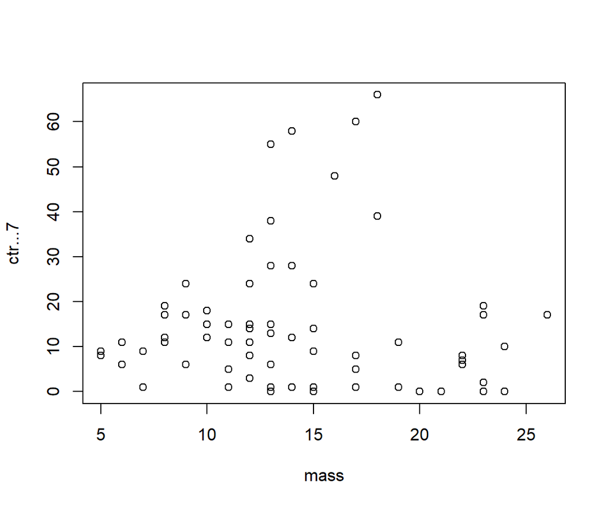

```r
# maagaCAnum2
# plot(maagaCAnum2, x = c("mass"), y = c("ctr...7"), xlim = c(0,30), ylim = c(0, 1000))
with(maagaCAnum2, plot(mass, ctr...7))
```

```r
tail(arrange(maagaCAnum2 ,ctr...7))
```

| name | mass | qlt | inr | k=1 | cor…6 | ctr…7 | k=2 | cor…9 | ctr…10 |
| --- | --- | --- | --- | --- | --- | --- | --- | --- | --- |
| BGf6 | 18 | 921 | 32 | 627 | 846 | 39 | 186 | 74 | 16 |
| DKf5 | 16 | 998 | 38 | -753 | 894 | 48 | 258 | 105 | 27 |
| DKm2 | 13 | 989 | 43 | -895 | 900 | 55 | 282 | 89 | 26 |
| DKf2 | 14 | 991 | 49 | -888 | 831 | 58 | 389 | 160 | 53 |
| DKf3 | 17 | 963 | 53 | -816 | 793 | 60 | 377 | 170 | 61 |
| DKf4 | 18 | 977 | 57 | -826 | 820 | 66 | 362 | 157 | 61 |

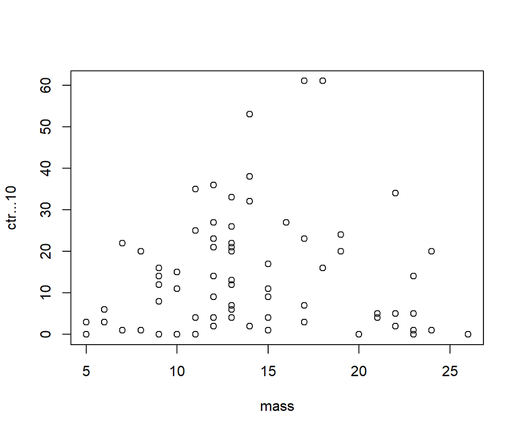

```r
with(maagaCAnum2, plot(mass, ctr...10))
```

```r
tail(arrange(maagaCAnum2 ,ctr...10))
```

| name | mass | qlt | inr | k=1 | cor…6 | ctr…7 | k=2 | cor…9 | ctr…10 |
| --- | --- | --- | --- | --- | --- | --- | --- | --- | --- |
| FIf6 | 11 | 835 | 7 | 151 | 134 | 1 | -347 | 701 | 35 |
| FIf3 | 12 | 984 | 13 | -423 | 590 | 11 | -346 | 394 | 36 |
| BEf1 | 14 | 678 | 9 | -83 | 43 | 1 | -320 | 635 | 38 |
| DKf2 | 14 | 991 | 49 | -888 | 831 | 58 | 389 | 160 | 53 |
| DKf3 | 17 | 963 | 53 | -816 | 793 | 60 | 377 | 170 | 61 |
| DKf4 | 18 | 977 | 57 | -826 | 820 | 66 | 362 | 157 | 61 |

```r
str(maagaCAnum2)
```

```
## tibble [72 x 10] (S3: tbl_df/tbl/data.frame)
##  $ name    : Factor w/ 72 levels "BEf1","BEf2",..: 1 2 3 4 5 6 7 8 9 10 ...
##  $ mass    : num [1:72] 14 24 21 24 23 23 11 17 20 22 ...
##  $ qlt     : num [1:72] 678 914 320 164 332 832 429 372 108 966 ...
##  $  inr    : num [1:72] 9 11 3 3 5 17 9 5 1 5 ...
##  $  k=1    : num [1:72] -83 -278 -62 -50 133 371 284 -113 17 225 ...
##  $ cor...6 : num [1:72] 43 650 96 92 304 710 367 169 29 812 ...
##  $ ctr...7 : num [1:72] 1 10 0 0 2 17 5 1 0 6 ...
##  $  k=2    : num [1:72] -320 -177 -95 -44 -40 153 -117 -125 -29 -98 ...
##  $ cor...9 : num [1:72] 635 264 224 71 28 121 62 203 79 154 ...
##  $ ctr...10: num [1:72] 38 20 5 1 1 14 4 7 0 5 ...
```

```r
arrange(maagaCAnum2, qlt)
```

| name | mass | qlt | inr | k=1 | cor…6 | ctr…7 | k=2 | cor…9 | ctr…10 |
| --- | --- | --- | --- | --- | --- | --- | --- | --- | --- |
| BEm3 | 20 | 108 | 1 | 17 | 29 | 0 | -29 | 79 | 0 |
| DEf6 | 23 | 116 | 8 | -56 | 32 | 0 | 90 | 84 | 5 |
| DEm4 | 21 | 137 | 5 | -1 | 0 | 0 | -89 | 137 | 4 |
| BEf4 | 24 | 164 | 3 | -50 | 92 | 0 | -44 | 71 | 1 |
| BEf3 | 21 | 320 | 3 | -62 | 96 | 0 | -95 | 224 | 5 |
| BEf5 | 23 | 332 | 5 | 133 | 304 | 2 | -40 | 28 | 1 |
| DKm6 | 15 | 355 | 5 | 89 | 85 | 1 | 158 | 270 | 9 |
| BEm2 | 17 | 372 | 5 | -113 | 169 | 1 | -125 | 203 | 7 |
| HUm2 | 9 | 381 | 11 | 344 | 381 | 6 | -2 | 0 | 0 |
| DEf1 | 13 | 425 | 3 | -41 | 29 | 0 | -149 | 395 | 7 |
| BEm1 | 11 | 429 | 9 | 284 | 367 | 5 | -117 | 62 | 4 |
| BGf1 | 5 | 531 | 11 | 547 | 531 | 8 | -9 | 0 | 0 |
| DEm5 | 19 | 603 | 5 | 76 | 75 | 1 | -202 | 529 | 20 |
| DKm5 | 13 | 643 | 9 | -281 | 435 | 6 | 194 | 208 | 13 |
| HUf6 | 13 | 671 | 34 | 637 | 581 | 28 | 251 | 90 | 21 |
| BEf1 | 14 | 678 | 9 | -83 | 43 | 1 | -320 | 635 | 38 |
| HUf2 | 11 | 689 | 11 | 438 | 685 | 11 | -35 | 4 | 0 |
| BGm6 | 9 | 692 | 27 | 701 | 647 | 24 | 184 | 45 | 8 |
| BGm3 | 8 | 709 | 19 | 655 | 698 | 19 | 83 | 11 | 1 |
| HUf1 | 7 | 723 | 9 | 499 | 698 | 9 | 93 | 25 | 1 |
| HUm6 | 8 | 726 | 15 | 517 | 529 | 11 | 315 | 197 | 20 |
| BEm5 | 22 | 728 | 8 | 255 | 686 | 8 | -63 | 42 | 2 |
| FIm5 | 12 | 734 | 7 | 220 | 289 | 3 | -273 | 446 | 23 |
| DEm3 | 15 | 737 | 4 | -64 | 63 | 0 | -210 | 674 | 17 |
| DEm2 | 13 | 766 | 4 | 38 | 16 | 0 | -259 | 749 | 22 |
| HUf4 | 11 | 768 | 18 | 491 | 564 | 15 | 296 | 204 | 25 |
| BGm4 | 8 | 771 | 11 | 540 | 754 | 12 | -81 | 17 | 1 |
| FIm1 | 7 | 787 | 5 | -115 | 78 | 1 | -347 | 710 | 22 |
| BEm6 | 26 | 788 | 15 | 348 | 788 | 17 | -5 | 0 | 0 |
| DKf6 | 12 | 808 | 9 | -340 | 579 | 8 | 214 | 229 | 14 |
| HUf3 | 12 | 808 | 18 | 484 | 586 | 15 | 298 | 222 | 27 |
| BGf3 | 12 | 815 | 21 | 617 | 804 | 24 | 75 | 12 | 2 |
| BGm2 | 6 | 830 | 9 | 557 | 788 | 11 | -130 | 43 | 3 |
| BEf6 | 23 | 832 | 17 | 371 | 710 | 17 | 153 | 121 | 14 |
| FIf6 | 11 | 835 | 7 | 151 | 134 | 1 | -347 | 701 | 35 |
| FIm4 | 13 | 837 | 6 | 19 | 3 | 0 | -316 | 834 | 33 |
| DEf5 | 17 | 839 | 7 | -297 | 772 | 8 | -87 | 67 | 3 |
| DEf3 | 19 | 846 | 13 | -333 | 582 | 11 | -224 | 264 | 24 |
| DEm6 | 22 | 849 | 12 | 244 | 427 | 7 | 242 | 422 | 34 |
| HUf5 | 12 | 850 | 13 | 474 | 753 | 14 | 170 | 97 | 9 |
| BGf2 | 8 | 860 | 14 | 640 | 853 | 17 | 59 | 7 | 1 |
| BGf5 | 14 | 880 | 23 | 609 | 870 | 28 | 66 | 10 | 2 |
| FIm6 | 9 | 911 | 6 | 336 | 637 | 6 | -220 | 274 | 12 |
| DEm1 | 13 | 912 | 4 | 124 | 180 | 1 | -250 | 732 | 20 |
| BEf2 | 24 | 914 | 11 | -278 | 650 | 10 | -177 | 264 | 20 |
| BGf6 | 18 | 921 | 32 | 627 | 846 | 39 | 186 | 74 | 16 |
| FIf2 | 12 | 927 | 26 | -730 | 907 | 34 | -110 | 21 | 4 |
| BGf4 | 10 | 932 | 12 | 519 | 927 | 15 | -39 | 5 | 0 |
| HUm1 | 6 | 935 | 5 | 426 | 766 | 6 | 201 | 170 | 6 |
| DEf2 | 15 | 938 | 10 | -415 | 919 | 14 | -60 | 19 | 1 |
| BGm1 | 5 | 940 | 7 | 596 | 878 | 9 | 159 | 62 | 3 |
| DKm4 | 15 | 941 | 19 | -534 | 855 | 24 | 170 | 86 | 11 |
| HUm5 | 13 | 942 | 12 | 472 | 891 | 15 | 113 | 51 | 4 |
| FIf5 | 17 | 952 | 8 | -240 | 502 | 5 | -227 | 450 | 23 |
| HUm3 | 13 | 957 | 12 | 441 | 803 | 13 | 193 | 154 | 12 |
| DKf3 | 17 | 963 | 53 | -816 | 793 | 60 | 377 | 170 | 61 |
| BEm4 | 22 | 966 | 5 | 225 | 812 | 6 | -98 | 154 | 5 |
| DKf4 | 18 | 977 | 57 | -826 | 820 | 66 | 362 | 157 | 61 |
| FIm2 | 9 | 977 | 14 | -598 | 832 | 17 | -250 | 146 | 14 |
| BGm5 | 10 | 979 | 11 | 524 | 977 | 15 | 21 | 2 | 0 |
| FIf1 | 12 | 980 | 11 | -417 | 693 | 11 | -269 | 287 | 21 |
| DKm1 | 15 | 981 | 7 | -329 | 898 | 9 | 100 | 83 | 4 |
| DKm3 | 13 | 982 | 28 | -728 | 950 | 38 | 134 | 32 | 6 |
| FIf3 | 12 | 984 | 13 | -423 | 590 | 11 | -346 | 394 | 36 |
| DEf4 | 23 | 985 | 13 | -390 | 982 | 19 | -18 | 2 | 0 |
| DKm2 | 13 | 989 | 43 | -895 | 900 | 55 | 282 | 89 | 26 |
| DKf1 | 10 | 991 | 15 | -567 | 839 | 18 | 241 | 152 | 15 |
| DKf2 | 14 | 991 | 49 | -888 | 831 | 58 | 389 | 160 | 53 |
| FIf4 | 14 | 991 | 14 | -398 | 644 | 12 | -292 | 347 | 32 |
| DKf5 | 16 | 998 | 38 | -753 | 894 | 48 | 258 | 105 | 27 |
| FIm3 | 9 | 998 | 6 | -345 | 629 | 6 | -265 | 369 | 16 |
| HUm4 | 10 | 999 | 10 | 468 | 830 | 12 | 211 | 169 | 11 |

```r
head(arrange(maagaCAnum2, qlt))
```

| name | mass | qlt | inr | k=1 | cor…6 | ctr…7 | k=2 | cor…9 | ctr…10 |
| --- | --- | --- | --- | --- | --- | --- | --- | --- | --- |
| BEm3 | 20 | 108 | 1 | 17 | 29 | 0 | -29 | 79 | 0 |
| DEf6 | 23 | 116 | 8 | -56 | 32 | 0 | 90 | 84 | 5 |
| DEm4 | 21 | 137 | 5 | -1 | 0 | 0 | -89 | 137 | 4 |
| BEf4 | 24 | 164 | 3 | -50 | 92 | 0 | -44 | 71 | 1 |
| BEf3 | 21 | 320 | 3 | -62 | 96 | 0 | -95 | 224 | 5 |
| BEf5 | 23 | 332 | 5 | 133 | 304 | 2 | -40 | 28 | 1 |

```r
# Hieman hankalaa kätevästi järjestää numeerisia tuloksia massan mukaan

#str(maagaCA1num)
#maagaCA1num$rows
#maagaRows.df <- maagaCA1num$rows
# sarakenimet eivät yksikäsitteisiä
#maagaRows.df
#str(maagaRows.df)
#names(maagaRows.df)
#str(maagaRows.df$mass)
# ei toimi AscmaagaRows.df <- maagaRows.df[order(mass),]
```

Massa ja kontribuutiot akseleille 1 ja 2: epäilyttäviä havaintoja joilla pieni massa ja suuri kontribuutio ei näytä olevan.

Huonosti esitetettyjä pisteitä on erityisesti Belgiasta, myös Saksan (DEf6,DEf1 ja DEm4), Tanskan vanhat miehet (DKm6) ja Unkarin nuorehkot miehet (HUm2) kuuluvat tähän joukkon.

Maapisteet täydentäviksi pisteiksi - tarkistuksia.

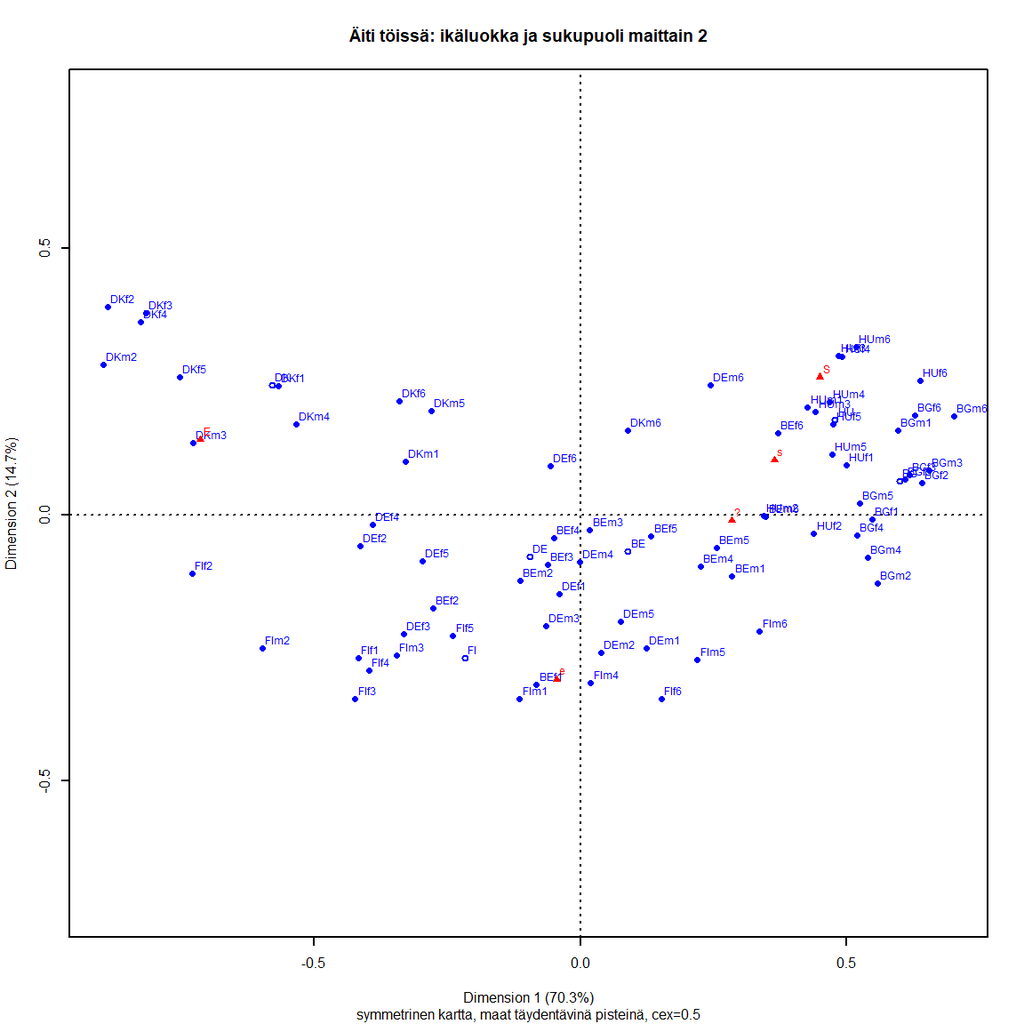

Ikä-sukupuoli-maa

```r
# Miten maa-rivit täydentäviksi riveiksi - alla siisti ratkaisu
# Miten labelit hieman lähemmäkis pistettä? offset-jotenkin toimii...

# rakennetaan taulukko, jossa alimpina riveinä "maa-rivit"
# otetaan karttaan mukaan täydentävinä pisteinä
# karttaa on helpompi tulkita, kun nähdään miten ikä-sukupuoli-ryhmät sijatsevat keskiarvonsa ympärillä

# HUOM! maagaTab1 integer matriisi, dimnames-attribuutilla kaksi arvoa
#ikäluokka - sukupuoli ja maa - maaga-muuttuja
maagaTab1 <- table(ISSP2012esim2.dat$maaga, ISSP2012esim2.dat$Q1b)
#dim(testTab1) #72 riviä,  5 saraketta


# maa-rivit
maagaTab_sr <- table(ISSP2012esim2.dat$maa, ISSP2012esim2.dat$Q1b)
#maagaTab_sr

maagaTab1 <- rbind(maagaTab1,maagaTab_sr)
# str(maagaTab1)
# maagaTab1
# dim(maagaTab1) #78 riviä, 5 saraketta, 1-72 data ja 73-78 täydentävät rivit

spCAmaaga1 <- ca(maagaTab1[,1:5], suprow = 73:78)
# X11()

# Plot toimii (4.2.20), ja par() (4.5.20)
par(cex = 0.5)
plot(spCAmaaga1, main = "Äiti töissä: ikäluokka ja sukupuoli maittain 2",
                sub = "symmetrinen kartta, maat täydentävinä pisteinä, cex=0.5"
                    )
```

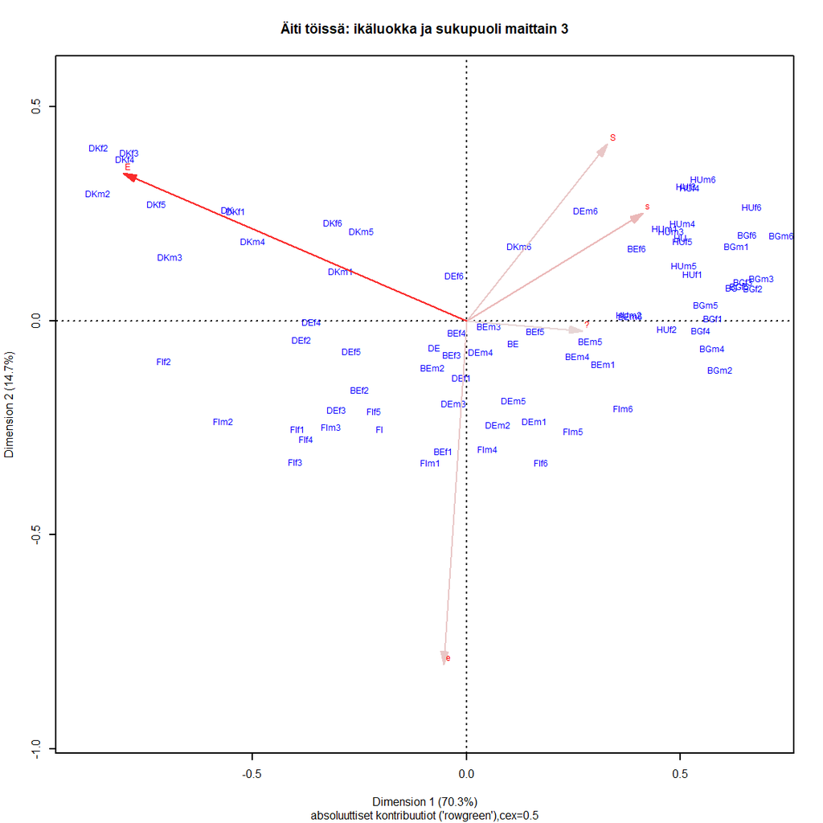

Ikä-sukupuoli-maa

```r
#asymmetrinen kartta
#X11()
par(cex = 0.5)
plot(spCAmaaga1, map = "rowgreen",
        contrib = c("absolute", "absolute"),
        mass = c(TRUE,TRUE),
        arrows = c(FALSE,TRUE),
        main = "Äiti töissä: ikäluokka ja sukupuoli maittain 3",
        sub ="absoluuttiset kontribuutiot ('rowgreen'),cex=0.5",
                  )
```